```python
import json
import pandas as pd
import nltk
import string
from nltk import word_tokenize
from nltk.corpus import stopwords
import nltk.classify.util


import matplotlib.pyplot as plt
%pylab inline
```

# Are we talking about the weather because of the weather? (Looking at Twitter Data and Extreme Storm Weather)

## Background

"How's the weather?" "It sure is sunny today."

Talking about the weather is a common topic in everyday conversations, but how much does the weather affect us?

It has been said that weather affects our mood. During winter months, some people are said to feel more down. The medical name for it is Seasonal Affective Depression (seasonal affective disorder, or SAD). WebMD cites this as a “mood disorder that happens every year at the same time.” One theory is that less sunlight during the fall and winter leads to the brain making less serotonin thus leading to nerve cell pathways that don’t function normally. This results in feelings of depression, along with symptoms of fatigue and weight gain.

Schwarz and Clore's study titled, "Misattribution, and Judgments of Well-Being: Informative and Directive Functions of Affective States" took a look at if a generally happy person can be made sad by the weather subconsciously. In the study they found that participants "self-reported happiness and overall life satisfaction changed based on the climate." In their research, they started an interview with a simple, "how's the weather" over the phone and it preempted participants to think about the weather because they spoke about how they were feeling. This study showed that people can be "misdirected and emotionally confused by subconscious stimuli."

But what about when people aren't preempted to talk about the weather by someone, will they start writing about it when the weather is bad? What will prompt it? Weather as an icebreaker is different from when someone decides to write about it.

Let's shift the idea of weather to a different focus.

In Kathryn Schulz's "Writers in The Storm" article, she explains how weather went from symbol to science and back to it again. She opens her article citing Mark Twain who declares "No weather will be found in this book" and how he was determinded to do without it because it usually gets in the way of the story. She explains that weather has two "terrible reputations:"

- "On the one hand, weather is widely regarded as the most banal topic in the world—in print as in conversation, the one we resort to when we have nothing else to say"
- "On the other hand, it stands perpetually accused of melodrama."

Weather works so well as a symbol, Alexandra Harris wrote, because "it's literal manifestation is oddly slippery. She accounts that weather is one of the most potent forces in our lives is often "imperceptible, perpetually changing, and frequently mysterious." Weather is also used to as a symbol to not only describe ourselves by our societies as whole.

Throughout the article Schulz goes over how the weather's role changed in literature. The earliest stories about the weather were about beginnings and endings (the beginning and end of the world). She concludes that today (the article is written in 2015) it's even MORE difficult to image an end of the world that isn't driven by a change in the weather.

## So, a tweet about the weather...

When people tweet, they aren't preempted to talk about something and they are free to tweet about anything they want that is under 140 characters. So when are people likely to begin talking about the weather via tweets? When we talk about the weather, are we talking about the weather because it's so different from the temperatures we're used to? Are we usually talking about good things or bad things or is weather perpetually a symbol of our impending doom?

I would like to hypothesize that we tweet more about the weather it's raining or cold or when there's negative extreme weather and that our tweets are more likely to be negative than positive.

I feel more inline with the thoughts of the social scientists than of the humanists in this case. I think tweets are more similar to our natural talk despite being written text and that it is less likely for tweets to be overly symbolic like in literature. It's interesting to think of where tweets fall in fields because they are social, but people are constructing their own stories about their lives in them so are they going to mention weather to explain their own mood.

## Why computational methods?

Twitter and sentimental analysis are probably one of the hottest and most popular things to do nowadays, but what I'm interested in is being able to match different but related datasets because this would bridge different fields together. We already know that there are methods to find sentiment and we're working to make them better, but what can we add on and how can we use this data to make it more relevant to fields who want to know more about people. I don't see this as a substitute for something like an interview but as another step.

Twitter has location and dates and from that information you can learn about what the weather was like by looking at other datasets that have weather data. I don't think a lot of people have used Twitter Data sets and weather data because the two are generally used by two different fields who probably don't meet, but in general, I see how approaching a problem like has a big potential for producing a lot more more noise than signal and might not even work.

But on the other hand, no one is going to read through 3 million tweets just to find tweets about weather because there's just so much twitter data. In addition, just matching up all of the different weather data even though there are databases make it very difficult. Therefore, computational methods are very useful for just sort and sifting through the vast twitter sea at least to help people pinpoint to tweets or text that may be of interest. Some hand-driven methods are needed and will be used (such as specifying specific words to search for).

**Sources:**  
Seasonal Depression (Seasonal Affective Disorder) - WebMD http://www.mayoclinic.org/diseases-conditions/seasonal-affective-disorder/basics/definition/con-20021047

Why We Always Talk about the Weather - http://www.sentientdecisionscience.com/why-we-always-talk-about-the-weather/

Schulz, Kathryn - Writers in the Storm http://www.newyorker.com/magazine/2015/11/23/writers-in-the-storm

## Corpus

This project works at combining two different data sets and matching the two together to create a new corpus. There is a twitter corpus and a weather corpus. In this section I will provide a short overview of what is in the full corpus and later go into what each individual piece is about.

### Twitter Corpus

**Source:**  
Z. Cheng, J. Caverlee, and K. Lee. You Are Where You Tweet: A Content-Based Approach to Geo-locating Twitter Users. In Proceeding of the 19th ACM Conference on Information and Knowledge Management (CIKM), Toronto, Oct 2010. https://archive.org/details/twitter_cikm_2010

### Extreme Storm Events Database

The National Centers for Environmental Information from the National Oceanic and Atmospheric Administration (NOAA) has an online database of storm events. From the online database, they state that the database contains records documenting:

1. The occurrence of storms and other significant weather phenomena having sufficient intensity to cause loss of life, injuries, significant property damage, and/or disruption to commerce;
2. Rare, unusual, weather phenomena that generate media attention, such as snow flurries in South Florida or the San Diego coastal area; and
3. Other significant meteorological events, such as record maximum or minimum temperatures or precipitation that occur in connection with another event.

**Source:**  
https://www.ncdc.noaa.gov/stormevents/

## Data Cleaning

In this section I will go over what pieces of the corpus will be used for this research and what was done to clean and merge the two data sets. There were many challenges in combining these two data and these variables have an effect on how to view the results as a whole, so it is important to be aware of the limitations and biases in this corpus.

### Cleaning the Twitter Corpus

Due to the largeness of this twitter set and lack of computational power, I will only be using a small subset of the twitter corpus to test and am aware of how this may be limiting to my findings. However, this too is only a small subset of tweets during a short period of time. In a further research, to better test my hypothesis, tweets from throughout the year (January - December) and from many different years would better (this would require a different twitter data set).

How the corpus is set up, the list of users and location are separated from their tweets (since in the corpus some of the users have multiple. The training set of user locations are self-labeled so this creates a lack of consistency in the labeling. The second set, has longtiude and latitude coordinates. In an ideal case, I would use a package such as geopy (https://geopy.readthedocs.io/en/1.11.0/) which would convert the longitude and latitude coordinates into an object that would contain an address and from there I would be able to pull the state (however, this requires a lot of time to run through the list and would require further muddling with separating the address into a json and extracting the state).

To get the Twitter Corpus into a usable form to be matched with the Storm Events Database, I need the state and a time period. Not all of the self-reported twitter locations contain states and many of them only contain a city. In addition for some pieces that do contain the state name, it may be written as an abbreviation (CA) or in full (California). Again, due to the inconsistencies and lack of computational available on the machinery being used to complete this task, the user's city name is pulled and that is to be matched to its corresponding state (this is done by comparing the city to a spreadsheet that provides the state and city name). The problem with this method is that cities with the same name exist in different states and matching in this fashion can either produce the same user being repeated in the same set for each state (which would increase their influence because they would be overrepresented) or a user being matched into the wrong state. This issue can be solved by using longitude and latitude. Because the corpus separates the user/location from the tweets, this requires us to match all of the users to a state before we can rematch them to their tweets. The size of users is unfortunately more than my machine can handle which is why I have resorted to this method.

In addition, to fish out tweet that have any sort of potential of talking about the weather, I will only be using tweets that mention the word "weather." In previous explorations of this data, I have looked at samples of the dataset, but many of those tweets do not talk about the weather and by focusing on tweets that mention the weather, we are more likely to get a better sample of users who feel affected by the weather.

```python
# opening twitter data and inputting it into a list
user_data_path = '../data_dump/twitter_cikm_2010/training_set_users.txt'

user_data = []
user_data_file = open(user_data_path, "r")
for line in user_data_file:
        user_data.append(line.strip().split('\t'))
```

```python
# Putting the twitter user information and cleaning the data for only the city name
user = pd.DataFrame(user_data)
user_location = user.rename(columns={0: 'user', 1: 'location'})


user_location['location'] = user_location['location'].apply(lambda x: x.split(',')[0])
user_location
```

|  | user | location |
| --- | --- | --- |
| 0 | 14 | San Francisco |
| 1 | 15 | San Francisco |
| 2 | 18 | San Francisco |
| 3 | 19922973 | Chicago |
| 4 | 63963170 | New York |
| 5 | 17825828 | Houston |
| 6 | 71303208 | Buffalo |
| 7 | 24117294 | Brooklyn |
| 8 | 67 | Bloomington |
| 9 | 15728730 | Las Vegas |
| 10 | 18874383 | San Francisco |
| 11 | 94 | San Francisco |
| 12 | 20097724 | Miami |
| 13 | 107 | San Francisco |
| 14 | 17126765 | Atlanta |
| 15 | 30408856 | New Orleans |
| 16 | 21670598 | Kent |
| 17 | 20126941 | Miami |
| 18 | 84585166 | Ontario |
| 19 | 78643425 | Houma |
| 20 | 10486002 | New York |
| 21 | 246 | San Francisco |
| 22 | 257 | Portland |
| 23 | 259 | San Francisco |
| 24 | 35651857 | Birmingham |
| 25 | 291 | San Francisco |
| 26 | 24117550 | Phoenix |
| 27 | 68157749 | Houston |
| 28 | 87032139 | Richmond |
| 29 | 45089102 | Murfreesboro |
| ... | ... | ... |
| 115856 | 18873663 | Sacramento |
| 115857 | 39845197 | Belfast |
| 115858 | 31456606 | Phoenix |
| 115859 | 15727981 | Miami |
| 115860 | 32505209 | San Francisco |
| 115861 | 14679516 | Minneapolis |
| 115862 | 76545502 | Niles |
| 115863 | 30408159 | Silver Spring |
| 115864 | 9436712 | Santa Cruz |
| 115865 | 41954985 | Aptos |
| 115866 | 61865611 | Nederland |
| 115867 | 27262621 | Holland |
| 115868 | 35651266 | Wichita |
| 115869 | 69205714 | Inglewood |
| 115870 | 57437077 | Torrington |
| 115871 | 66060041 | Lorain |
| 115872 | 25593540 | Brooklyn |
| 115873 | 23068470 | Charlotte |
| 115874 | 24466741 | South San Francisco |
| 115875 | 19922761 | Dallas |
| 115876 | 38622527 | San Diego |
| 115877 | 69205905 | Louisville |
| 115878 | 72351647 | Los Angeles |
| 115879 | 71303080 | Los Angeles |
| 115880 | 47185836 | Chicago |
| 115881 | 9437102 | Raleigh |
| 115882 | 18000542 | Dallas |
| 115883 | 55574468 | Pensacola |
| 115884 | 15728619 | Woburn |
| 115885 | 70604115 | Clarkston |

115886 rows × 2 columns

```python
len(user_location)
```

```
115886
```

##### Matching Cities to States

To match the the cities to states, I have used the Google AdWords API to compile a list of city names and states.

**Source:**  
https://developers.google.com/adwords/api/docs/appendix/geotargeting?csw=1

```python
test_df = pd.read_csv("../data_dump/query.csv", sep = ',', encoding = 'utf-8',)
test_df

test_df = test_df.loc[test_df['Country Code'] == 'US']
test_df = test_df.loc[test_df['Target Type'] == 'City']
test_df['Canonical Name'] = test_df['Canonical Name'].apply(lambda x: x.split(','))

test_df['Canonical Name'] = [item[:-1] for item in test_df['Canonical Name']]
test_df['Canonical Name'] = [item[-1] for item in test_df['Canonical Name']]

test_df = test_df.rename(columns={'Name': 'location'})

combo_df = pd.merge(user_location, test_df, on='location')
combo_df
```

|  | user | location | Criteria ID | Canonical Name | Parent ID | Country Code | Target Type | Status |
| --- | --- | --- | --- | --- | --- | --- | --- | --- |
| 0 | 14 | San Francisco | 1014221 | California | 21137.0 | US | City | Active |
| 1 | 15 | San Francisco | 1014221 | California | 21137.0 | US | City | Active |
| 2 | 18 | San Francisco | 1014221 | California | 21137.0 | US | City | Active |
| 3 | 18874383 | San Francisco | 1014221 | California | 21137.0 | US | City | Active |
| 4 | 94 | San Francisco | 1014221 | California | 21137.0 | US | City | Active |
| 5 | 107 | San Francisco | 1014221 | California | 21137.0 | US | City | Active |
| 6 | 246 | San Francisco | 1014221 | California | 21137.0 | US | City | Active |
| 7 | 259 | San Francisco | 1014221 | California | 21137.0 | US | City | Active |
| 8 | 291 | San Francisco | 1014221 | California | 21137.0 | US | City | Active |
| 9 | 61 | San Francisco | 1014221 | California | 21137.0 | US | City | Active |
| 10 | 66 | San Francisco | 1014221 | California | 21137.0 | US | City | Active |
| 11 | 414 | San Francisco | 1014221 | California | 21137.0 | US | City | Active |
| 12 | 6291872 | San Francisco | 1014221 | California | 21137.0 | US | City | Active |
| 13 | 509 | San Francisco | 1014221 | California | 21137.0 | US | City | Active |
| 14 | 89 | San Francisco | 1014221 | California | 21137.0 | US | City | Active |
| 15 | 10486402 | San Francisco | 1014221 | California | 21137.0 | US | City | Active |
| 16 | 1075 | San Francisco | 1014221 | California | 21137.0 | US | City | Active |
| 17 | 1103 | San Francisco | 1014221 | California | 21137.0 | US | City | Active |
| 18 | 1117 | San Francisco | 1014221 | California | 21137.0 | US | City | Active |
| 19 | 1153 | San Francisco | 1014221 | California | 21137.0 | US | City | Active |
| 20 | 1173 | San Francisco | 1014221 | California | 21137.0 | US | City | Active |
| 21 | 1186 | San Francisco | 1014221 | California | 21137.0 | US | City | Active |
| 22 | 85984592 | San Francisco | 1014221 | California | 21137.0 | US | City | Active |
| 23 | 274 | San Francisco | 1014221 | California | 21137.0 | US | City | Active |
| 24 | 2172 | San Francisco | 1014221 | California | 21137.0 | US | City | Active |
| 25 | 2495 | San Francisco | 1014221 | California | 21137.0 | US | City | Active |
| 26 | 2781 | San Francisco | 1014221 | California | 21137.0 | US | City | Active |
| 27 | 2984 | San Francisco | 1014221 | California | 21137.0 | US | City | Active |
| 28 | 3475 | San Francisco | 1014221 | California | 21137.0 | US | City | Active |
| 29 | 3981 | San Francisco | 1014221 | California | 21137.0 | US | City | Active |
| ... | ... | ... | ... | ... | ... | ... | ... | ... |
| 412992 | 18843291 | Mexia | 1026620 | Texas | 21176.0 | US | City | Active |
| 412993 | 17796796 | River Ridge | 9052750 | Louisiana | 21151.0 | US | City | Active |
| 412994 | 27236980 | Blackwell | 1024134 | Oklahoma | 21169.0 | US | City | Active |
| 412995 | 28285855 | Montrose | 1013075 | Alabama | 21133.0 | US | City | Active |
| 412996 | 28285855 | Montrose | 1014584 | Colorado | 21138.0 | US | City | Active |
| 412997 | 28285855 | Montrose | 1019468 | Michigan | 21155.0 | US | City | Active |
| 412998 | 28285855 | Montrose | 1019980 | Minnesota | 21156.0 | US | City | Active |
| 412999 | 28285855 | Montrose | 1020494 | Missouri | 21157.0 | US | City | Active |
| 413000 | 28285855 | Montrose | 1023167 | New York | 21167.0 | US | City | Active |
| 413001 | 28285855 | Montrose | 1025105 | Pennsylvania | 21171.0 | US | City | Active |
| 413002 | 28285855 | Montrose | 1025820 | South Dakota | 21174.0 | US | City | Active |
| 413003 | 28285855 | Montrose | 9052470 | Virginia | 21178.0 | US | City | Active |
| 413004 | 16753882 | Ironwood | 1019375 | Michigan | 21155.0 | US | City | Active |
| 413005 | 28289070 | Huntington Park | 1013870 | California | 21137.0 | US | City | Active |
| 413006 | 20951093 | Ramona | 1024315 | Oklahoma | 21169.0 | US | City | Active |
| 413007 | 20951093 | Ramona | 1025845 | South Dakota | 21174.0 | US | City | Active |
| 413008 | 76214389 | Rossford | 1023973 | Ohio | 21168.0 | US | City | Active |
| 413009 | 35634759 | Desert Hot Springs | 1014069 | California | 21137.0 | US | City | Active |
| 413010 | 46122885 | Forest City | 1015788 | Iowa | 21145.0 | US | City | Active |
| 413011 | 46122885 | Forest City | 1021111 | North Carolina | 21160.0 | US | City | Active |
| 413012 | 46122885 | Forest City | 1024866 | Pennsylvania | 21171.0 | US | City | Active |
| 413013 | 46122885 | Forest City | 9051961 | Florida | 21142.0 | US | City | Active |
| 413014 | 31443403 | Howard | 1017514 | Kansas | 21149.0 | US | City | Active |
| 413015 | 31443403 | Howard | 1024951 | Pennsylvania | 21171.0 | US | City | Active |
| 413016 | 31443403 | Howard | 1025779 | South Dakota | 21174.0 | US | City | Active |
| 413017 | 31443403 | Howard | 9052166 | Wisconsin | 21182.0 | US | City | Active |
| 413018 | 15716554 | Iowa Falls | 1015845 | Iowa | 21145.0 | US | City | Active |
| 413019 | 37047718 | Forest Hill | 1018585 | Maryland | 21153.0 | US | City | Active |
| 413020 | 25160997 | Ambridge | 1024624 | Pennsylvania | 21171.0 | US | City | Active |
| 413021 | 18870757 | Aztec | 1022501 | New Mexico | 21165.0 | US | City | Active |

413022 rows × 8 columns

```python
len(combo_df)
```

```
413022
```

As you can see this matching has inflated our number of entries by 297136 (413022 - 115886). Therefore, we will drop duplicates so that each user has only one location.

```python
combo_df = combo_df.drop_duplicates(['user'], keep='last')
combo_df
```

|  | user | location | Criteria ID | Canonical Name | Parent ID | Country Code | Target Type | Status |
| --- | --- | --- | --- | --- | --- | --- | --- | --- |
| 0 | 14 | San Francisco | 1014221 | California | 21137.0 | US | City | Active |
| 1 | 15 | San Francisco | 1014221 | California | 21137.0 | US | City | Active |
| 2 | 18 | San Francisco | 1014221 | California | 21137.0 | US | City | Active |
| 3 | 18874383 | San Francisco | 1014221 | California | 21137.0 | US | City | Active |
| 5 | 107 | San Francisco | 1014221 | California | 21137.0 | US | City | Active |
| 6 | 246 | San Francisco | 1014221 | California | 21137.0 | US | City | Active |
| 7 | 259 | San Francisco | 1014221 | California | 21137.0 | US | City | Active |
| 8 | 291 | San Francisco | 1014221 | California | 21137.0 | US | City | Active |
| 9 | 61 | San Francisco | 1014221 | California | 21137.0 | US | City | Active |
| 10 | 66 | San Francisco | 1014221 | California | 21137.0 | US | City | Active |
| 11 | 414 | San Francisco | 1014221 | California | 21137.0 | US | City | Active |
| 12 | 6291872 | San Francisco | 1014221 | California | 21137.0 | US | City | Active |
| 13 | 509 | San Francisco | 1014221 | California | 21137.0 | US | City | Active |
| 14 | 89 | San Francisco | 1014221 | California | 21137.0 | US | City | Active |
| 16 | 1075 | San Francisco | 1014221 | California | 21137.0 | US | City | Active |
| 17 | 1103 | San Francisco | 1014221 | California | 21137.0 | US | City | Active |
| 18 | 1117 | San Francisco | 1014221 | California | 21137.0 | US | City | Active |
| 19 | 1153 | San Francisco | 1014221 | California | 21137.0 | US | City | Active |
| 20 | 1173 | San Francisco | 1014221 | California | 21137.0 | US | City | Active |
| 21 | 1186 | San Francisco | 1014221 | California | 21137.0 | US | City | Active |
| 22 | 85984592 | San Francisco | 1014221 | California | 21137.0 | US | City | Active |
| 23 | 274 | San Francisco | 1014221 | California | 21137.0 | US | City | Active |
| 24 | 2172 | San Francisco | 1014221 | California | 21137.0 | US | City | Active |
| 25 | 2495 | San Francisco | 1014221 | California | 21137.0 | US | City | Active |
| 26 | 2781 | San Francisco | 1014221 | California | 21137.0 | US | City | Active |
| 27 | 2984 | San Francisco | 1014221 | California | 21137.0 | US | City | Active |
| 28 | 3475 | San Francisco | 1014221 | California | 21137.0 | US | City | Active |
| 29 | 3981 | San Francisco | 1014221 | California | 21137.0 | US | City | Active |
| 30 | 17830692 | San Francisco | 1014221 | California | 21137.0 | US | City | Active |
| 31 | 8393572 | San Francisco | 1014221 | California | 21137.0 | US | City | Active |
| ... | ... | ... | ... | ... | ... | ... | ... | ... |
| 412972 | 53396096 | Reedsburg | 1028179 | Wisconsin | 21182.0 | US | City | Active |
| 412974 | 14602293 | Willow Springs | 1020684 | Missouri | 21157.0 | US | City | Active |
| 412975 | 15191903 | Lilburn | 1015413 | Georgia | 21143.0 | US | City | Active |
| 412976 | 18800663 | Methuen | 1018301 | Massachusetts | 21152.0 | US | City | Active |
| 412977 | 37676741 | Clarinda | 1015706 | Iowa | 21145.0 | US | City | Active |
| 412979 | 26154333 | Carnegie | 1024719 | Pennsylvania | 21171.0 | US | City | Active |
| 412980 | 17765863 | Bridge City | 1026241 | Texas | 21176.0 | US | City | Active |
| 412981 | 26159986 | Swainsboro | 1015522 | Georgia | 21143.0 | US | City | Active |
| 412984 | 58666065 | Booneville | 1020703 | Mississippi | 21158.0 | US | City | Active |
| 412985 | 17777612 | Long Grove | 1016633 | Illinois | 21147.0 | US | City | Active |
| 412986 | 69161188 | Schiller Park | 1016835 | Illinois | 21147.0 | US | City | Active |
| 412987 | 17781769 | Wheat Ridge | 1014652 | Colorado | 21138.0 | US | City | Active |
| 412988 | 59724853 | Champlin | 1019756 | Minnesota | 21156.0 | US | City | Active |
| 412990 | 63927428 | Hannibal | 1023735 | Ohio | 21168.0 | US | City | Active |
| 412991 | 33520862 | Anadarko | 1024118 | Oklahoma | 21169.0 | US | City | Active |
| 412992 | 18843291 | Mexia | 1026620 | Texas | 21176.0 | US | City | Active |
| 412993 | 17796796 | River Ridge | 9052750 | Louisiana | 21151.0 | US | City | Active |
| 412994 | 27236980 | Blackwell | 1024134 | Oklahoma | 21169.0 | US | City | Active |
| 413003 | 28285855 | Montrose | 9052470 | Virginia | 21178.0 | US | City | Active |
| 413004 | 16753882 | Ironwood | 1019375 | Michigan | 21155.0 | US | City | Active |
| 413005 | 28289070 | Huntington Park | 1013870 | California | 21137.0 | US | City | Active |
| 413007 | 20951093 | Ramona | 1025845 | South Dakota | 21174.0 | US | City | Active |
| 413008 | 76214389 | Rossford | 1023973 | Ohio | 21168.0 | US | City | Active |
| 413009 | 35634759 | Desert Hot Springs | 1014069 | California | 21137.0 | US | City | Active |
| 413013 | 46122885 | Forest City | 9051961 | Florida | 21142.0 | US | City | Active |
| 413017 | 31443403 | Howard | 9052166 | Wisconsin | 21182.0 | US | City | Active |
| 413018 | 15716554 | Iowa Falls | 1015845 | Iowa | 21145.0 | US | City | Active |
| 413019 | 37047718 | Forest Hill | 1018585 | Maryland | 21153.0 | US | City | Active |
| 413020 | 25160997 | Ambridge | 1024624 | Pennsylvania | 21171.0 | US | City | Active |
| 413021 | 18870757 | Aztec | 1022501 | New Mexico | 21165.0 | US | City | Active |

108104 rows × 8 columns

#### Importing tweets and matching to user data

For this experiement we will only be looking at tweets that mention the word "weather."

```python
# importing tweets

tweets_data_path = '../data_dump/twitter_cikm_2010/training_set_tweets.txt'

tweets_data = []
tweets_file = open(tweets_data_path, "r")
counter = 0
for line in tweets_file:
        tweets_data.append(line.strip().split('\t'))
        if counter > 50000:
            break
        counter += 1
```

```python
# importing tweets

tweets_data_path = '../data_dump/twitter_cikm_2010/training_set_tweets.txt'

tweets_data = []
tweets_file = open(tweets_data_path, "r")
counter = 0
for line in tweets_file:
        tweets_data.append(line.strip().split('\t'))
        if counter > 4000000:
            break
        counter += 1
```

```python
# tweets are turned into a data frame
tweets = pd.DataFrame(tweets_data)

# note: the tweet data contains 4 types of information, a user id,
# an unindentifiable number which I refer to as mysterious, the tweet, and a timestamp

tweets_cleaned = tweets.loc[:,:3]
tweets_clean = tweets_cleaned.rename(columns={0:'user', 1: 'mysterious', 2: 'tweet', 3:'timestamp'})
tweets_clean

tweets_clean2 = tweets_clean[tweets_clean['tweet'].apply(str).str.contains('weather')]
tweets_clean2
```

|  | user | mysterious | tweet | timestamp |
| --- | --- | --- | --- | --- |
| 136 | 31064071 | 5984449271 | @CarmenOOlalaa he's almost making an offer I c... | 2009-11-23 13:03:19 |
| 147 | 31064071 | 5980607565 | @SuaveSerg thanks! I'm here now missing the wa... | 2009-11-23 10:31:00 |
| 150 | 31064071 | 5976719827 | At the airport, soon to trade this warm orland... | 2009-11-23 07:54:13 |
| 615 | 22937622 | 3215543725 | sitting in 94 degree weather for 4 hours today... | 2009-08-09 18:23:45 |
| 1586 | 67 | 4716597568 | You know the weather is getting bad when your ... | 2009-10-08 15:48:44 |
| 1954 | 89 | 5496739344 | Colder weather is kind of exciting, except for... | 2009-11-06 20:47:45 |
| 1961 | 89 | 5403089698 | Did anyone tell the weather it's november? | 2009-11-03 16:07:24 |
| 1990 | 15728730 | 1487963353 | So much depends on the weather; so is it raini... | 2009-04-09 21:43:48 |
| 2501 | 65667184 | 5544563981 | Loving the cool weather! Sitting by the firep... | 2009-11-08 17:53:44 |
| 2825 | 12163922 | 4975330424 | For those who ask how much worse than NY Bosto... | 2009-10-18 16:55:31 |
| 4873 | 88735953 | 5722957235 | @JoCAnnnora I know, it's insane. I'm in wisco... | 2009-11-14 18:34:41 |
| 5022 | 21408463 | 5026907270 | Wish the cold weather would come back!! | 2009-10-20 15:41:39 |
| 5031 | 21408463 | 4870967764 | @SapphicOwl can't wait for cooler weather! | 2009-10-14 15:32:27 |
| 5410 | 17457969 | 6240048312 | Booked a 24 hour trip home to Chicago for the ... | 2009-12-01 10:47:51 |
| 5583 | 246 | 5492243263 | @Poormojo yes! Do you mean the good weather ea... | 2009-11-06 17:28:37 |
| 5594 | 246 | 5407545247 | I know three things to be true: SF weather is ... | 2009-11-03 19:07:03 |
| 6278 | 77201671 | 4925057082 | We will hold the Junior Striker class at the S... | 2009-10-16 15:23:56 |
| 7126 | 24117550 | 4433793941 | "September days are here, with summer's best o... | 2009-09-27 22:20:53 |
| 7720 | 27656504 | 5927391862 | Is going to go Downtown Baltimore and enjoy th... | 2009-11-21 14:32:08 |
| 8158 | 19267912 | 4917495707 | 10 great places to experience wild weather: ht... | 2009-10-16 09:58:26 |
| 8697 | 19682704 | 2758008925 | I must say. The weather here in Atlanta has be... | 2009-07-21 08:51:25 |
| 8811 | 21365098 | 6213455246 | What day and time is it??????? Darn weather! | 2009-11-30 15:38:07 |
| 9404 | 15729017 | 5882300556 | @BFree63 Too many forget content has $ value &... | 2009-11-20 00:22:10 |
| 9599 | 22151553 | 5371028615 | Colder weather means more indoor activities. C... | 2009-11-02 13:43:17 |
| 10365 | 50856340 | 6266186268 | Mimbres Hot Springs Ranch hosts 29th annual St... | 2009-12-02 05:01:04 |
| 11098 | 62259622 | 5261807111 | Haven't heard from teletubby in a day or so Hi... | 2009-10-29 10:49:55 |
| 12046 | 75104729 | 5557317076 | Woke up this morning and it was the worse weat... | 2009-11-09 06:27:05 |
| 12393 | 46137833 | 5043789000 | @jeneralee I thought the recent short spell of... | 2009-10-21 08:23:14 |
| 12395 | 46137833 | 5029935114 | You gotta be kidding me. Back to 90 degrees fo... | 2009-10-20 18:05:58 |
| 12513 | 14287342 | 5054686651 | @jconley21 he's a weather forecasta | 2009-10-21 17:55:41 |
| ... | ... | ... | ... | ... |
| 3833838 | 59754528 | 4126663028 | Pats will probably dominate the Jets. Tom Bra... | 2009-09-20 11:55:03 |
| 3834073 | 696693 | 4028714662 | We're entering hot chocolate weather. Mmmm... | 2009-09-16 08:09:00 |
| 3834098 | 30930636 | 1721937376 | Finishing up some work at the internet cafe, J... | 2009-05-06 18:05:00 |
| 3834409 | 38783419 | 4033397437 | @TomsCigars just looked at the weather up ther... | 2009-09-16 12:09:00 |
| 3834575 | 44212674 | 4173446682 | Another busy day at work and the super hot wea... | 2009-09-22 09:54:31 |
| 3835017 | 37735656 | 2337855386 | hurry up & bring the plane...weather delays ge... | 2009-06-25 21:06:00 |
| 3835111 | 73387438 | 3935038008 | @tomhowellgc haha love it, hope the weather im... | 2009-09-12 10:12:43 |
| 3835427 | 7327612 | 4131335511 | This is just the perfect Sunday. The weather i... | 2009-09-20 16:04:23 |
| 3836350 | 40883407 | 3807257939 | Check the live radar from home at VolunteerTV.... | 2009-09-06 18:18:53 |
| 3836353 | 40883407 | 3939396103 | A wonderful weekend of weather for you, but a ... | 2009-09-12 14:18:55 |
| 3836357 | 40883407 | 3981900048 | Loved the fall like weather this A.M. Love tha... | 2009-09-14 10:22:29 |
| 3836801 | 37738266 | 4154375542 | RT @walkerlely Byebye cool weather hello Sever... | 2009-09-21 15:09:00 |
| 3837485 | 20270878 | 4306414641 | Had a great dinner with homemade carrot cake a... | 2009-09-22 22:04:35 |
| 3837841 | 69197011 | 3974882893 | This was a damn good day. Birds win, Phils wi... | 2009-09-14 00:09:00 |
| 3838079 | 19914267 | 4114210472 | Cold weather get here! Same for @kx3thryn | 2009-09-19 20:06:25 |
| 3839026 | 35643965 | 4133968857 | Good weekend...my boy Mayweather smashed, Nine... | 2009-09-20 18:28:35 |
| 3839071 | 35644029 | 4059040258 | @Moe09t123 I know fuck wrong with this weather | 2009-09-17 12:09:00 |
| 3839118 | 18348823 | 4125442458 | I was in the Land of No Phone Reception last n... | 2009-09-20 10:09:00 |
| 3839708 | 12576062 | 4101216127 | Leaves are changing, weather is cooling off Fa... | 2009-09-19 07:09:00 |
| 3839900 | 24290906 | 4116954953 | Watching the Mayweather/Marquez match. | 2009-09-19 22:09:00 |
| 3840935 | 18869004 | 4366833195 | I love waking up to this kind of weather. Rain... | 2009-09-25 07:10:52 |
| 3841014 | 52423550 | 4153501118 | @laialbert The weather did not cooperate with ... | 2009-09-21 14:09:00 |
| 3841478 | 17821219 | 4418439160 | I hate this weather!!!! | 2009-09-27 10:17:42 |
| 3841547 | 15724110 | 4066513563 | Take a few days off from a project because the... | 2009-09-17 19:09:00 |
| 3842189 | 15724740 | 4314834356 | At Work Webcast: Here's a check of Eastern Iow... | 2009-09-23 08:10:43 |
| 3842201 | 15724740 | 4341174122 | AT WORK WEBCAST: Here's a Check of your Easter... | 2009-09-24 08:11:04 |
| 3842202 | 15724740 | 4341261603 | At Work Webcast: Here's a check of Eastern Iow... | 2009-09-24 08:15:59 |
| 3843730 | 58938411 | 4058011536 | The weather in cincinnati is sunny n clear ski... | 2009-09-17 11:09:00 |
| 3844069 | 18872608 | 4010258742 | Live round by round twittering of the Márquez ... | 2009-09-15 13:09:00 |
| 3844079 | 18872608 | 4033721717 | Márquez contra Mayweather, en vivo, el sabado,... | 2009-09-16 12:09:00 |

9038 rows × 4 columns

```python
# This below will clean match the users' id to their specific tweet.
combined_df = pd.merge(combo_df, tweets_clean2, on='user')

combined_df['Canonical Name'] = combined_df['Canonical Name'].str.lower()
combined_df = combined_df.rename(columns={'Canonical Name': 'STATE'})
combined_df
```

|  | user | location | Criteria ID | STATE | Parent ID | Country Code | Target Type | Status | mysterious | tweet | timestamp |
| --- | --- | --- | --- | --- | --- | --- | --- | --- | --- | --- | --- |
| 0 | 246 | San Francisco | 1014221 | california | 21137.0 | US | City | Active | 5492243263 | @Poormojo yes! Do you mean the good weather ea... | 2009-11-06 17:28:37 |
| 1 | 246 | San Francisco | 1014221 | california | 21137.0 | US | City | Active | 5407545247 | I know three things to be true: SF weather is ... | 2009-11-03 19:07:03 |
| 2 | 89 | San Francisco | 1014221 | california | 21137.0 | US | City | Active | 5496739344 | Colder weather is kind of exciting, except for... | 2009-11-06 20:47:45 |
| 3 | 89 | San Francisco | 1014221 | california | 21137.0 | US | City | Active | 5403089698 | Did anyone tell the weather it's november? | 2009-11-03 16:07:24 |
| 4 | 10051 | San Francisco | 1014221 | california | 21137.0 | US | City | Active | 5539145659 | that's METARspeak for "nice weather" | 2009-11-08 13:53:29 |
| 5 | 10051 | San Francisco | 1014221 | california | 21137.0 | US | City | Active | 5539117423 | Headed to Oakland soon, where the weather is K... | 2009-11-08 13:52:09 |
| 6 | 10051 | San Francisco | 1014221 | california | 21137.0 | US | City | Active | 5483875175 | Deciphering DUAT data. I wonder how many pilot... | 2009-11-06 11:27:42 |
| 7 | 12263 | San Francisco | 1014221 | california | 21137.0 | US | City | Active | 4696454250 | I have a headache. Damn rainy Syracuse weather. | 2009-10-07 19:39:32 |
| 8 | 12263 | San Francisco | 1014221 | california | 21137.0 | US | City | Active | 4476832966 | @chrisspy How are you enjoying your poopy weat... | 2009-09-29 13:47:02 |
| 9 | 12329 | San Francisco | 1014221 | california | 21137.0 | US | City | Active | 5012334962 | San Francisco's small coastal weather system w... | 2009-10-20 00:49:27 |
| 10 | 16796955 | San Francisco | 1014221 | california | 21137.0 | US | City | Active | 5895824590 | It's gonna be rainy tonight... do I really wan... | 2009-11-20 11:58:39 |
| 11 | 35685107 | San Francisco | 1014221 | california | 21137.0 | US | City | Active | 4841148920 | Venturing out into the stormy weather for dim ... | 2009-10-13 13:29:13 |
| 12 | 3191321 | San Francisco | 1014221 | california | 21137.0 | US | City | Active | 5686270861 | @laur oh fun! Peeps in hardcore cold weather r... | 2009-11-13 12:05:32 |
| 13 | 17877122 | San Francisco | 1014221 | california | 21137.0 | US | City | Active | 5397528292 | I might curse SF weather during the summer, bu... | 2009-11-03 12:07:37 |
| 14 | 78493781 | San Francisco | 1014221 | california | 21137.0 | US | City | Active | 6357556034 | RT @stevepohlit: All of us could take a lesson... | 2009-12-04 20:31:07 |
| 15 | 74529880 | San Francisco | 1014221 | california | 21137.0 | US | City | Active | 5233242699 | Mmm, the perfect cold-weather breakfast is coo... | 2009-10-28 10:48:34 |
| 16 | 12668172 | San Francisco | 1014221 | california | 21137.0 | US | City | Active | 5232524614 | It's sf weather in Tucson today- it feels norm... | 2009-10-28 10:19:20 |
| 17 | 51483994 | San Francisco | 1014221 | california | 21137.0 | US | City | Active | 2790453856 | @gabe_ibarra @gabeion @weatherpending chingon ... | 2009-07-22 21:23:31 |
| 18 | 64068758 | San Francisco | 1014221 | california | 21137.0 | US | City | Active | 3801822888 | The good, the bad & the ugly: This Too Shall P... | 2009-09-06 12:42:43 |
| 19 | 14349750 | San Francisco | 1014221 | california | 21137.0 | US | City | Active | 4928217089 | Couldn't've asked for better weather today. Ha... | 2009-10-16 17:41:55 |
| 20 | 173283 | San Francisco | 1014221 | california | 21137.0 | US | City | Active | 5989389004 | @qlam that would be enough motivation for me: ... | 2009-11-23 16:16:55 |
| 21 | 9086282 | San Francisco | 1014221 | california | 21137.0 | US | City | Active | 5816400848 | Ran 5.5 miles and felt good. Nice tempo run af... | 2009-11-17 21:28:21 |
| 22 | 14857135 | San Francisco | 1014221 | california | 21137.0 | US | City | Active | 1353956410 | haha to all of you in crappy weather, it's sun... | 2009-03-19 07:15:03 |
| 23 | 14985126 | San Francisco | 1014221 | california | 21137.0 | US | City | Active | 5316180459 | Set Your Clocks and Check Your Stocks!: Happy ... | None |
| 24 | 47373051 | San Francisco | 1014221 | california | 21137.0 | US | City | Active | 4031291201 | Farmers sell WIVES and DAUGHTERS to weather dr... | 2009-09-16 10:30:42 |
| 25 | 69398053 | San Francisco | 1014221 | california | 21137.0 | US | City | Active | 5109316367 | How everyone enjoying the weather? | 2009-10-23 17:59:25 |
| 26 | 18031093 | San Francisco | 1014221 | california | 21137.0 | US | City | Active | 6331836318 | @ptanthos I agree there is something very wron... | 2009-12-04 02:45:37 |
| 27 | 15940807 | San Francisco | 1014221 | california | 21137.0 | US | City | Active | 4528812112 | Can't wait for chilly weather, hot drinks, war... | 2009-10-01 11:42:53 |
| 28 | 19093324 | San Francisco | 1014221 | california | 21137.0 | US | City | Active | 5668969825 | RT @TimJackson: Winter is coming- are you read... | 2009-11-12 21:02:08 |
| 29 | 5972102 | San Francisco | 1014221 | california | 21137.0 | US | City | Active | 1485378271 | My phone meeting didn't happen. Can take a mom... | 2009-04-09 14:07:52 |
| ... | ... | ... | ... | ... | ... | ... | ... | ... | ... | ... | ... |
| 8985 | 18385743 | Ladson | 1025594 | south carolina | 21173.0 | US | City | Active | 4043121942 | Feels awesome outside not hot, but not hoodie ... | 2009-09-16 20:09:00 |
| 8986 | 15524550 | San Lorenzo | 1014230 | california | 21137.0 | US | City | Active | 3975740146 | I love the rain, this "ugly" weather isn't so ... | 2009-09-14 02:09:00 |
| 8987 | 22407569 | DeForest | 1027927 | wisconsin | 21182.0 | US | City | Active | 4068767173 | @weathergirl12 i sure am enjoying the fruit pu... | 2009-09-17 20:09:00 |
| 8988 | 18421478 | Truth or Consequences | 1022603 | new mexico | 21165.0 | US | City | Active | 4118453011 | @JayBigs mayweather is working in association ... | 2009-09-20 00:09:00 |
| 8989 | 18278961 | Lenoir City | 1026045 | tennessee | 21175.0 | US | City | Active | 3996520673 | Had a great long walk on the beach. Perfect we... | 2009-09-14 22:09:00 |
| 8990 | 18278961 | Lenoir City | 1026045 | tennessee | 21175.0 | US | City | Active | 4015562040 | Went golfing today! Perfect weather, close fam... | 2009-09-15 17:09:00 |
| 8991 | 59275382 | Spanaway | 1027758 | washington | 21180.0 | US | City | Active | 3810558720 | car show was a bit of a wash out due to the ba... | 2009-09-06 21:09:00 |
| 8992 | 19656786 | Severna Park | 1018706 | maryland | 21153.0 | US | City | Active | 3512687101 | sent an email newsletter to clients about SunB... | 2009-08-24 08:48:53 |
| 8993 | 19656786 | Severna Park | 1018706 | maryland | 21153.0 | US | City | Active | 4426597561 | is recommending an outdoor weatherproof HDTV t... | 2009-09-27 16:46:34 |
| 8994 | 59193068 | Millville | 1028379 | west virginia | 21183.0 | US | City | Active | 4126324392 | Ughh! I can't stand cold weather! | 2009-09-20 11:09:00 |
| 8995 | 27736121 | Hillside | 1022181 | new jersey | 21164.0 | US | City | Active | 4088521562 | Finally out of work and it is gorgeous outside... | 2009-09-18 16:09:00 |
| 8996 | 35083521 | Crofton | 1021636 | nebraska | 21162.0 | US | City | Active | 4116567309 | Listening to @cantonjones "So Bad" on iheartra... | 2009-09-19 22:09:00 |
| 8997 | 35083521 | Crofton | 1021636 | nebraska | 21162.0 | US | City | Active | 4117135947 | Mayweather in 6!! RT @rolandsmartin Who will w... | 2009-09-19 22:09:00 |
| 8998 | 27762984 | Soledad | 1014285 | california | 21137.0 | US | City | Active | 4118460541 | Mayweather wins. Go black people... | 2009-09-20 00:09:00 |
| 8999 | 19430167 | Pearl River | 1023251 | new york | 21167.0 | US | City | Active | 3996112079 | there a reason y pride is one of the seven dea... | 2009-09-14 21:09:00 |
| 9000 | 17500037 | Pekin | 1016765 | illinois | 21147.0 | US | City | Active | 4150629571 | eating soup for lunch. It seems too soon to b... | 2009-09-21 12:15:32 |
| 9001 | 58317980 | Vidalia | 1018075 | louisiana | 21151.0 | US | City | Active | 4052668888 | It's yucky and rainy outside-good sleeping wea... | 2009-09-17 07:09:00 |
| 9002 | 26929448 | Purcell | 1024312 | oklahoma | 21169.0 | US | City | Active | 4298967818 | Every time the weather changes, my heart is al... | 2009-09-22 16:36:47 |
| 9003 | 54201423 | Iowa Park | 1026496 | texas | 21176.0 | US | City | Active | 4164081326 | Today's weather was amazing! Not too hot not t... | 2009-09-21 22:09:00 |
| 9004 | 13446262 | Weiser | 1016245 | idaho | 21146.0 | US | City | Active | 4173504498 | RT @Tonweather: What is an RSS? And why do I h... | 2009-09-22 09:57:21 |
| 9005 | 13446262 | Weiser | 1016245 | idaho | 21146.0 | US | City | Active | 4173942180 | @Tonweather My RSS's ribs are showing. It's qu... | 2009-09-22 10:17:46 |
| 9006 | 22782569 | Erlanger | 1017751 | kentucky | 21150.0 | US | City | Active | 4346446620 | @IKBD dress for the weather next time kid. | 2009-09-24 12:10:56 |
| 9007 | 7098002 | Sealy | 1026780 | texas | 21176.0 | US | City | Active | 4315641415 | Last day off, then back to work. Im so excited... | 2009-09-23 08:53:14 |
| 9008 | 37549350 | Trotwood | 9053009 | ohio | 21168.0 | US | City | Active | 2477191958 | Thanks to Family and Friends who attened the B... | 2009-07-04 21:07:00 |
| 9009 | 59283196 | Point Pleasant | 9052696 | new jersey | 21164.0 | US | City | Active | 3914351042 | Martell's tiki bar show this afternoon cancell... | 2009-09-11 11:32:04 |
| 9010 | 57547051 | Midlothian | 1027221 | virginia | 21178.0 | US | City | Active | 4300511484 | lovin the cool weather... not lovin my winter ... | 2009-09-22 17:48:42 |
| 9011 | 51275792 | Roy | 1027738 | washington | 21180.0 | US | City | Active | 2784065650 | @shaycarl whats up shay how is the wonderful w... | 2009-07-22 14:58:02 |
| 9012 | 53396096 | Reedsburg | 1028179 | wisconsin | 21182.0 | US | City | Active | 4147859617 | is back to our regular schedule. The wedding ... | 2009-09-21 10:05:12 |
| 9013 | 27236980 | Blackwell | 1024134 | oklahoma | 21169.0 | US | City | Active | 4123485009 | This could be the last day we see summer weath... | 2009-09-20 08:37:21 |
| 9014 | 27236980 | Blackwell | 1024134 | oklahoma | 21169.0 | US | City | Active | 4319585967 | beautiful weather , nice chill in the air dry ... | 2009-09-23 11:51:30 |

9015 rows × 11 columns

```python
# for cleaning timestamp errors, but does not apply to this set

combined_df_with_time = combined_df[~combined_df['timestamp'].isnull()]

combined_df_with_time = combined_df_with_time.reset_index(np.arange(len(combined_df_with_time)))

from datetime import datetime

timestamps = combined_df_with_time['timestamp']
datetimes = []
errors = []
for i in range(len(timestamps)):
    try:
        datetimes.append(datetime.strptime(timestamps[i], '%Y-%m-%d %H:%M:%S'))
    except:
        errors.append(i)
errors, len(datetimes)

combined_df_without_errors = combined_df_with_time.drop(combined_df_with_time.index[errors])
combined_df_without_errors = combined_df_without_errors.reset_index(np.arange(len(combined_df_without_errors)))

combined_df_without_errors['timestamp'] = datetimes

t = tweets_clean2['timestamp'][0]
t1 = datetime.strptime(t, '%Y-%m-%d %H:%M:%S')

# begin_date_time <= t
# t <= end_date
```

### Extreme Storm Events Database Cleaning & Combining the Two

This section comprises of the cleaning of the extreme storm events database and how it was cleaned. The databases are broken up into years, therefore I will be combining the 2008, 2009, and 2010 spreadsheets for this study.

Below are the specific columns I will be taking from the data set to look at:  
Columns: STATE, EVENT_TYPE, BEGIN_DATE_TIME, END_DATE_TIME,

The data set does not contains specific dates, but date ranges of when extreme storm events occured so the twitter data is matched to that whether that tweet falls under that data and is the user location matches with that set.

```python
storm2008_df = pd.read_csv("../data_dump/Stormdata_2008.csv", sep = ',', encoding = 'utf-8',
                           usecols=["STATE","EVENT_TYPE", "BEGIN_DATE_TIME", "END_DATE_TIME"])
storm2008_df

storm2009_df = pd.read_csv("../data_dump/Stormdata_2009.csv", sep = ',', encoding = 'utf-8',
                           usecols=["STATE","EVENT_TYPE", "BEGIN_DATE_TIME", "END_DATE_TIME"])
storm2009_df

storm_df = pd.concat([storm2008_df, storm2009_df], axis=0)
storm_df['STATE'] = storm_df['STATE'].str.lower()
storm_df
```

|  | STATE | EVENT_TYPE | BEGIN_DATE_TIME | END_DATE_TIME |
| --- | --- | --- | --- | --- |
| 0 | indiana | Flood | 1/1/2008 0:00 | 1/2/2008 15:45 |
| 1 | alabama | Drought | 1/1/2008 0:00 | 1/31/2008 23:59 |
| 2 | alabama | Drought | 1/1/2008 0:00 | 1/31/2008 23:59 |
| 3 | alabama | Drought | 1/1/2008 0:00 | 1/31/2008 23:59 |
| 4 | alabama | Drought | 1/1/2008 0:00 | 1/31/2008 23:59 |
| 5 | alabama | Drought | 1/1/2008 0:00 | 1/31/2008 23:59 |
| 6 | alabama | Drought | 1/1/2008 0:00 | 1/31/2008 23:59 |
| 7 | alabama | Drought | 1/1/2008 0:00 | 1/31/2008 23:59 |
| 8 | alabama | Drought | 1/1/2008 0:00 | 1/31/2008 23:59 |
| 9 | alabama | Drought | 1/1/2008 0:00 | 1/31/2008 23:59 |
| 10 | alabama | Drought | 1/1/2008 0:00 | 1/31/2008 23:59 |
| 11 | alabama | Drought | 1/1/2008 0:00 | 1/31/2008 23:59 |
| 12 | alabama | Drought | 1/1/2008 0:00 | 1/31/2008 23:59 |
| 13 | alabama | Drought | 1/1/2008 0:00 | 1/31/2008 23:59 |
| 14 | alabama | Drought | 1/1/2008 0:00 | 1/31/2008 23:59 |
| 15 | alabama | Drought | 1/1/2008 0:00 | 1/31/2008 23:59 |
| 16 | alabama | Drought | 1/1/2008 0:00 | 1/31/2008 23:59 |
| 17 | alabama | Drought | 1/1/2008 0:00 | 1/31/2008 23:59 |
| 18 | alabama | Drought | 1/1/2008 0:00 | 1/31/2008 23:59 |
| 19 | alabama | Drought | 1/1/2008 0:00 | 1/31/2008 23:59 |
| 20 | alabama | Drought | 1/1/2008 0:00 | 1/31/2008 23:59 |
| 21 | alabama | Drought | 1/1/2008 0:00 | 1/31/2008 23:59 |
| 22 | alabama | Drought | 1/1/2008 0:00 | 1/31/2008 23:59 |
| 23 | alabama | Drought | 1/1/2008 0:00 | 1/31/2008 23:59 |
| 24 | alabama | Drought | 1/1/2008 0:00 | 1/31/2008 23:59 |
| 25 | alabama | Drought | 1/1/2008 0:00 | 1/31/2008 23:59 |
| 26 | alabama | Drought | 1/1/2008 0:00 | 1/31/2008 23:59 |
| 27 | alabama | Drought | 1/1/2008 0:00 | 1/31/2008 23:59 |
| 28 | alabama | Drought | 1/1/2008 0:00 | 1/31/2008 23:59 |
| 29 | alabama | Drought | 1/1/2008 0:00 | 1/31/2008 23:59 |
| ... | ... | ... | ... | ... |
| 57367 | texas | Winter Weather | 12/31/2009 9:00 | 12/31/2009 15:00 |
| 57368 | texas | Winter Weather | 12/31/2009 9:00 | 12/31/2009 15:00 |
| 57369 | texas | Winter Weather | 12/31/2009 9:00 | 12/31/2009 15:00 |
| 57370 | texas | Winter Weather | 12/31/2009 9:00 | 12/31/2009 15:00 |
| 57371 | oregon | Heavy Snow | 12/31/2009 9:00 | 12/31/2009 15:00 |
| 57372 | oregon | High Wind | 12/31/2009 9:37 | 12/31/2009 14:36 |
| 57373 | idaho | Heavy Snow | 12/31/2009 10:00 | 12/31/2009 22:00 |
| 57374 | washington | Heavy Snow | 12/31/2009 10:20 | 12/31/2009 19:00 |
| 57375 | washington | Heavy Snow | 12/31/2009 10:30 | 12/31/2009 17:00 |
| 57376 | oregon | High Wind | 12/31/2009 10:38 | 12/31/2009 19:44 |
| 57377 | idaho | Heavy Snow | 12/31/2009 12:00 | 12/31/2009 23:00 |
| 57378 | washington | Heavy Snow | 12/31/2009 12:00 | 12/31/2009 18:00 |
| 57379 | oregon | High Wind | 12/31/2009 13:04 | 12/31/2009 22:50 |
| 57380 | idaho | Heavy Snow | 12/31/2009 15:00 | 12/31/2009 23:00 |
| 57381 | montana | Heavy Snow | 12/31/2009 16:00 | 12/31/2009 23:59 |
| 57382 | utah | Dense Fog | 12/31/2009 17:00 | 12/31/2009 23:59 |
| 57383 | pennsylvania | Winter Weather | 12/31/2009 18:00 | 12/31/2009 23:59 |
| 57384 | pennsylvania | Winter Weather | 12/31/2009 18:00 | 12/31/2009 23:59 |
| 57385 | wyoming | High Wind | 12/31/2009 18:01 | 12/31/2009 23:59 |
| 57386 | pennsylvania | Winter Weather | 12/31/2009 18:30 | 12/31/2009 23:59 |
| 57387 | pennsylvania | Winter Weather | 12/31/2009 19:00 | 12/31/2009 23:59 |
| 57388 | new jersey | Winter Weather | 12/31/2009 19:00 | 12/31/2009 23:59 |
| 57389 | pennsylvania | Winter Weather | 12/31/2009 19:00 | 12/31/2009 23:59 |
| 57390 | pennsylvania | Winter Weather | 12/31/2009 19:00 | 12/31/2009 23:59 |
| 57391 | new jersey | Winter Weather | 12/31/2009 19:30 | 12/31/2009 23:59 |
| 57392 | pennsylvania | Winter Weather | 12/31/2009 20:00 | 12/31/2009 23:59 |
| 57393 | new jersey | Winter Weather | 12/31/2009 20:00 | 12/31/2009 23:59 |
| 57394 | pennsylvania | Winter Weather | 12/31/2009 20:00 | 12/31/2009 23:59 |
| 57395 | new jersey | Winter Weather | 12/31/2009 20:00 | 12/31/2009 23:59 |
| 57396 | new jersey | Winter Weather | 12/31/2009 20:00 | 12/31/2009 23:59 |

128941 rows × 4 columns

```python
#time date function to convert timedate for storm information so that that
#the datetime is consistent with the dataframe for the tweets

def turnDate(date):
    return datetime.strptime(date, '%m/%d/%Y %H:%M')

december = turnDate('12/31/2009 15:59')
december
```

```
datetime.datetime(2009, 12, 31, 15, 59)
```

```python
storm_df['begin_date'] = storm_df['BEGIN_DATE_TIME'].apply(lambda x: turnDate(x))
storm_df['end_date'] = storm_df['END_DATE_TIME'].apply(lambda x: turnDate(x))

storm_df
```

|  | STATE | EVENT_TYPE | BEGIN_DATE_TIME | END_DATE_TIME | begin_date | end_date |
| --- | --- | --- | --- | --- | --- | --- |
| 0 | indiana | Flood | 1/1/2008 0:00 | 1/2/2008 15:45 | 2008-01-01 00:00:00 | 2008-01-02 15:45:00 |
| 1 | alabama | Drought | 1/1/2008 0:00 | 1/31/2008 23:59 | 2008-01-01 00:00:00 | 2008-01-31 23:59:00 |
| 2 | alabama | Drought | 1/1/2008 0:00 | 1/31/2008 23:59 | 2008-01-01 00:00:00 | 2008-01-31 23:59:00 |
| 3 | alabama | Drought | 1/1/2008 0:00 | 1/31/2008 23:59 | 2008-01-01 00:00:00 | 2008-01-31 23:59:00 |
| 4 | alabama | Drought | 1/1/2008 0:00 | 1/31/2008 23:59 | 2008-01-01 00:00:00 | 2008-01-31 23:59:00 |
| 5 | alabama | Drought | 1/1/2008 0:00 | 1/31/2008 23:59 | 2008-01-01 00:00:00 | 2008-01-31 23:59:00 |
| 6 | alabama | Drought | 1/1/2008 0:00 | 1/31/2008 23:59 | 2008-01-01 00:00:00 | 2008-01-31 23:59:00 |
| 7 | alabama | Drought | 1/1/2008 0:00 | 1/31/2008 23:59 | 2008-01-01 00:00:00 | 2008-01-31 23:59:00 |
| 8 | alabama | Drought | 1/1/2008 0:00 | 1/31/2008 23:59 | 2008-01-01 00:00:00 | 2008-01-31 23:59:00 |
| 9 | alabama | Drought | 1/1/2008 0:00 | 1/31/2008 23:59 | 2008-01-01 00:00:00 | 2008-01-31 23:59:00 |
| 10 | alabama | Drought | 1/1/2008 0:00 | 1/31/2008 23:59 | 2008-01-01 00:00:00 | 2008-01-31 23:59:00 |
| 11 | alabama | Drought | 1/1/2008 0:00 | 1/31/2008 23:59 | 2008-01-01 00:00:00 | 2008-01-31 23:59:00 |
| 12 | alabama | Drought | 1/1/2008 0:00 | 1/31/2008 23:59 | 2008-01-01 00:00:00 | 2008-01-31 23:59:00 |
| 13 | alabama | Drought | 1/1/2008 0:00 | 1/31/2008 23:59 | 2008-01-01 00:00:00 | 2008-01-31 23:59:00 |
| 14 | alabama | Drought | 1/1/2008 0:00 | 1/31/2008 23:59 | 2008-01-01 00:00:00 | 2008-01-31 23:59:00 |
| 15 | alabama | Drought | 1/1/2008 0:00 | 1/31/2008 23:59 | 2008-01-01 00:00:00 | 2008-01-31 23:59:00 |
| 16 | alabama | Drought | 1/1/2008 0:00 | 1/31/2008 23:59 | 2008-01-01 00:00:00 | 2008-01-31 23:59:00 |
| 17 | alabama | Drought | 1/1/2008 0:00 | 1/31/2008 23:59 | 2008-01-01 00:00:00 | 2008-01-31 23:59:00 |
| 18 | alabama | Drought | 1/1/2008 0:00 | 1/31/2008 23:59 | 2008-01-01 00:00:00 | 2008-01-31 23:59:00 |
| 19 | alabama | Drought | 1/1/2008 0:00 | 1/31/2008 23:59 | 2008-01-01 00:00:00 | 2008-01-31 23:59:00 |
| 20 | alabama | Drought | 1/1/2008 0:00 | 1/31/2008 23:59 | 2008-01-01 00:00:00 | 2008-01-31 23:59:00 |
| 21 | alabama | Drought | 1/1/2008 0:00 | 1/31/2008 23:59 | 2008-01-01 00:00:00 | 2008-01-31 23:59:00 |
| 22 | alabama | Drought | 1/1/2008 0:00 | 1/31/2008 23:59 | 2008-01-01 00:00:00 | 2008-01-31 23:59:00 |
| 23 | alabama | Drought | 1/1/2008 0:00 | 1/31/2008 23:59 | 2008-01-01 00:00:00 | 2008-01-31 23:59:00 |
| 24 | alabama | Drought | 1/1/2008 0:00 | 1/31/2008 23:59 | 2008-01-01 00:00:00 | 2008-01-31 23:59:00 |
| 25 | alabama | Drought | 1/1/2008 0:00 | 1/31/2008 23:59 | 2008-01-01 00:00:00 | 2008-01-31 23:59:00 |
| 26 | alabama | Drought | 1/1/2008 0:00 | 1/31/2008 23:59 | 2008-01-01 00:00:00 | 2008-01-31 23:59:00 |
| 27 | alabama | Drought | 1/1/2008 0:00 | 1/31/2008 23:59 | 2008-01-01 00:00:00 | 2008-01-31 23:59:00 |
| 28 | alabama | Drought | 1/1/2008 0:00 | 1/31/2008 23:59 | 2008-01-01 00:00:00 | 2008-01-31 23:59:00 |
| 29 | alabama | Drought | 1/1/2008 0:00 | 1/31/2008 23:59 | 2008-01-01 00:00:00 | 2008-01-31 23:59:00 |
| ... | ... | ... | ... | ... | ... | ... |
| 57367 | texas | Winter Weather | 12/31/2009 9:00 | 12/31/2009 15:00 | 2009-12-31 09:00:00 | 2009-12-31 15:00:00 |
| 57368 | texas | Winter Weather | 12/31/2009 9:00 | 12/31/2009 15:00 | 2009-12-31 09:00:00 | 2009-12-31 15:00:00 |
| 57369 | texas | Winter Weather | 12/31/2009 9:00 | 12/31/2009 15:00 | 2009-12-31 09:00:00 | 2009-12-31 15:00:00 |
| 57370 | texas | Winter Weather | 12/31/2009 9:00 | 12/31/2009 15:00 | 2009-12-31 09:00:00 | 2009-12-31 15:00:00 |
| 57371 | oregon | Heavy Snow | 12/31/2009 9:00 | 12/31/2009 15:00 | 2009-12-31 09:00:00 | 2009-12-31 15:00:00 |
| 57372 | oregon | High Wind | 12/31/2009 9:37 | 12/31/2009 14:36 | 2009-12-31 09:37:00 | 2009-12-31 14:36:00 |
| 57373 | idaho | Heavy Snow | 12/31/2009 10:00 | 12/31/2009 22:00 | 2009-12-31 10:00:00 | 2009-12-31 22:00:00 |
| 57374 | washington | Heavy Snow | 12/31/2009 10:20 | 12/31/2009 19:00 | 2009-12-31 10:20:00 | 2009-12-31 19:00:00 |
| 57375 | washington | Heavy Snow | 12/31/2009 10:30 | 12/31/2009 17:00 | 2009-12-31 10:30:00 | 2009-12-31 17:00:00 |
| 57376 | oregon | High Wind | 12/31/2009 10:38 | 12/31/2009 19:44 | 2009-12-31 10:38:00 | 2009-12-31 19:44:00 |
| 57377 | idaho | Heavy Snow | 12/31/2009 12:00 | 12/31/2009 23:00 | 2009-12-31 12:00:00 | 2009-12-31 23:00:00 |
| 57378 | washington | Heavy Snow | 12/31/2009 12:00 | 12/31/2009 18:00 | 2009-12-31 12:00:00 | 2009-12-31 18:00:00 |
| 57379 | oregon | High Wind | 12/31/2009 13:04 | 12/31/2009 22:50 | 2009-12-31 13:04:00 | 2009-12-31 22:50:00 |
| 57380 | idaho | Heavy Snow | 12/31/2009 15:00 | 12/31/2009 23:00 | 2009-12-31 15:00:00 | 2009-12-31 23:00:00 |
| 57381 | montana | Heavy Snow | 12/31/2009 16:00 | 12/31/2009 23:59 | 2009-12-31 16:00:00 | 2009-12-31 23:59:00 |
| 57382 | utah | Dense Fog | 12/31/2009 17:00 | 12/31/2009 23:59 | 2009-12-31 17:00:00 | 2009-12-31 23:59:00 |
| 57383 | pennsylvania | Winter Weather | 12/31/2009 18:00 | 12/31/2009 23:59 | 2009-12-31 18:00:00 | 2009-12-31 23:59:00 |
| 57384 | pennsylvania | Winter Weather | 12/31/2009 18:00 | 12/31/2009 23:59 | 2009-12-31 18:00:00 | 2009-12-31 23:59:00 |
| 57385 | wyoming | High Wind | 12/31/2009 18:01 | 12/31/2009 23:59 | 2009-12-31 18:01:00 | 2009-12-31 23:59:00 |
| 57386 | pennsylvania | Winter Weather | 12/31/2009 18:30 | 12/31/2009 23:59 | 2009-12-31 18:30:00 | 2009-12-31 23:59:00 |
| 57387 | pennsylvania | Winter Weather | 12/31/2009 19:00 | 12/31/2009 23:59 | 2009-12-31 19:00:00 | 2009-12-31 23:59:00 |
| 57388 | new jersey | Winter Weather | 12/31/2009 19:00 | 12/31/2009 23:59 | 2009-12-31 19:00:00 | 2009-12-31 23:59:00 |
| 57389 | pennsylvania | Winter Weather | 12/31/2009 19:00 | 12/31/2009 23:59 | 2009-12-31 19:00:00 | 2009-12-31 23:59:00 |
| 57390 | pennsylvania | Winter Weather | 12/31/2009 19:00 | 12/31/2009 23:59 | 2009-12-31 19:00:00 | 2009-12-31 23:59:00 |
| 57391 | new jersey | Winter Weather | 12/31/2009 19:30 | 12/31/2009 23:59 | 2009-12-31 19:30:00 | 2009-12-31 23:59:00 |
| 57392 | pennsylvania | Winter Weather | 12/31/2009 20:00 | 12/31/2009 23:59 | 2009-12-31 20:00:00 | 2009-12-31 23:59:00 |
| 57393 | new jersey | Winter Weather | 12/31/2009 20:00 | 12/31/2009 23:59 | 2009-12-31 20:00:00 | 2009-12-31 23:59:00 |
| 57394 | pennsylvania | Winter Weather | 12/31/2009 20:00 | 12/31/2009 23:59 | 2009-12-31 20:00:00 | 2009-12-31 23:59:00 |
| 57395 | new jersey | Winter Weather | 12/31/2009 20:00 | 12/31/2009 23:59 | 2009-12-31 20:00:00 | 2009-12-31 23:59:00 |
| 57396 | new jersey | Winter Weather | 12/31/2009 20:00 | 12/31/2009 23:59 | 2009-12-31 20:00:00 | 2009-12-31 23:59:00 |

128941 rows × 6 columns

```python
#unfortunately the 2010 datetime has a different format, so we will do the same steps and combine the above after

storm2010_df = pd.read_csv("../data_dump/Stormdata_2010.csv", sep = ',', encoding = 'utf-8',
                           usecols=["STATE","EVENT_TYPE", "BEGIN_DATE_TIME", "END_DATE_TIME"])
storm2010_df['STATE'] = storm2010_df['STATE'].str.lower()

def turnDate2010(date):
    return datetime.strptime(date, '%d-%b-%y %H:%M:%S')

storm2010_df['begin_date'] = storm2010_df['BEGIN_DATE_TIME'].apply(lambda x: turnDate2010(x))
storm2010_df['end_date'] = storm2010_df['END_DATE_TIME'].apply(lambda x: turnDate2010(x))

storm2010_df
```

|  | STATE | EVENT_TYPE | BEGIN_DATE_TIME | END_DATE_TIME | begin_date | end_date |
| --- | --- | --- | --- | --- | --- | --- |
| 0 | new hampshire | Heat | 07-JUL-10 12:51:00 | 07-JUL-10 16:30:00 | 2010-07-07 12:51:00 | 2010-07-07 16:30:00 |
| 1 | new hampshire | Heavy Snow | 17-JAN-10 23:00:00 | 18-JAN-10 15:00:00 | 2010-01-17 23:00:00 | 2010-01-18 15:00:00 |
| 2 | new hampshire | Strong Wind | 01-OCT-10 08:30:00 | 01-OCT-10 10:00:00 | 2010-10-01 08:30:00 | 2010-10-01 10:00:00 |
| 3 | new hampshire | Heat | 06-JUL-10 09:51:00 | 06-JUL-10 18:30:00 | 2010-07-06 09:51:00 | 2010-07-06 18:30:00 |
| 4 | new hampshire | Winter Storm | 26-DEC-10 17:00:00 | 27-DEC-10 18:00:00 | 2010-12-26 17:00:00 | 2010-12-27 18:00:00 |
| 5 | new hampshire | High Wind | 25-FEB-10 23:05:00 | 26-FEB-10 00:38:00 | 2010-02-25 23:05:00 | 2010-02-26 00:38:00 |
| 6 | new hampshire | Heavy Snow | 16-FEB-10 12:00:00 | 17-FEB-10 00:00:00 | 2010-02-16 12:00:00 | 2010-02-17 00:00:00 |
| 7 | new hampshire | Strong Wind | 14-MAR-10 13:45:00 | 14-MAR-10 14:15:00 | 2010-03-14 13:45:00 | 2010-03-14 14:15:00 |
| 8 | florida | Flash Flood | 21-JAN-10 03:00:00 | 21-JAN-10 06:00:00 | 2010-01-21 03:00:00 | 2010-01-21 06:00:00 |
| 9 | iowa | Flood | 11-MAR-10 18:16:00 | 16-MAR-10 08:30:00 | 2010-03-11 18:16:00 | 2010-03-16 08:30:00 |
| 10 | iowa | Hail | 06-APR-10 16:42:00 | 06-APR-10 16:44:00 | 2010-04-06 16:42:00 | 2010-04-06 16:44:00 |
| 11 | kansas | Hail | 30-MAY-10 16:23:00 | 30-MAY-10 16:23:00 | 2010-05-30 16:23:00 | 2010-05-30 16:23:00 |
| 12 | kansas | Hail | 30-MAY-10 16:56:00 | 30-MAY-10 16:56:00 | 2010-05-30 16:56:00 | 2010-05-30 16:56:00 |
| 13 | south carolina | Thunderstorm Wind | 27-OCT-10 19:32:00 | 27-OCT-10 19:34:00 | 2010-10-27 19:32:00 | 2010-10-27 19:34:00 |
| 14 | wyoming | Heavy Snow | 20-NOV-10 13:00:00 | 23-NOV-10 05:00:00 | 2010-11-20 13:00:00 | 2010-11-23 05:00:00 |
| 15 | wyoming | Heavy Snow | 20-NOV-10 13:00:00 | 23-NOV-10 05:00:00 | 2010-11-20 13:00:00 | 2010-11-23 05:00:00 |
| 16 | atlantic north | Marine Thunderstorm Wind | 12-JUL-10 14:54:00 | 12-JUL-10 14:54:00 | 2010-07-12 14:54:00 | 2010-07-12 14:54:00 |
| 17 | atlantic north | Marine Thunderstorm Wind | 12-JUL-10 15:10:00 | 12-JUL-10 15:10:00 | 2010-07-12 15:10:00 | 2010-07-12 15:10:00 |
| 18 | atlantic north | Marine Thunderstorm Wind | 25-JUL-10 15:45:00 | 25-JUL-10 16:24:00 | 2010-07-25 15:45:00 | 2010-07-25 16:24:00 |
| 19 | atlantic north | Marine Thunderstorm Wind | 25-JUL-10 16:00:00 | 25-JUL-10 16:31:00 | 2010-07-25 16:00:00 | 2010-07-25 16:31:00 |
| 20 | atlantic north | Marine Thunderstorm Wind | 25-JUL-10 16:12:00 | 25-JUL-10 16:24:00 | 2010-07-25 16:12:00 | 2010-07-25 16:24:00 |
| 21 | texas | Thunderstorm Wind | 24-OCT-10 21:17:00 | 24-OCT-10 21:17:00 | 2010-10-24 21:17:00 | 2010-10-24 21:17:00 |
| 22 | texas | Hail | 24-OCT-10 21:17:00 | 24-OCT-10 21:17:00 | 2010-10-24 21:17:00 | 2010-10-24 21:17:00 |
| 23 | louisiana | Hail | 24-OCT-10 21:22:00 | 24-OCT-10 21:22:00 | 2010-10-24 21:22:00 | 2010-10-24 21:22:00 |
| 24 | wyoming | Winter Storm | 18-DEC-10 05:00:00 | 20-DEC-10 07:00:00 | 2010-12-18 05:00:00 | 2010-12-20 07:00:00 |
| 25 | missouri | Hail | 22-NOV-10 18:35:00 | 22-NOV-10 18:35:00 | 2010-11-22 18:35:00 | 2010-11-22 18:35:00 |
| 26 | missouri | Hail | 22-NOV-10 18:36:00 | 22-NOV-10 18:36:00 | 2010-11-22 18:36:00 | 2010-11-22 18:36:00 |
| 27 | missouri | Hail | 22-NOV-10 19:16:00 | 22-NOV-10 19:16:00 | 2010-11-22 19:16:00 | 2010-11-22 19:16:00 |
| 28 | missouri | Hail | 22-NOV-10 19:50:00 | 22-NOV-10 19:50:00 | 2010-11-22 19:50:00 | 2010-11-22 19:50:00 |
| 29 | missouri | Hail | 24-NOV-10 21:50:00 | 24-NOV-10 21:50:00 | 2010-11-24 21:50:00 | 2010-11-24 21:50:00 |
| ... | ... | ... | ... | ... | ... | ... |
| 62774 | iowa | Flash Flood | 22-JUL-10 00:15:00 | 22-JUL-10 03:00:00 | 2010-07-22 00:15:00 | 2010-07-22 03:00:00 |
| 62775 | west virginia | Thunderstorm Wind | 02-JUN-10 14:30:00 | 02-JUN-10 14:30:00 | 2010-06-02 14:30:00 | 2010-06-02 14:30:00 |
| 62776 | arkansas | Lightning | 30-APR-10 21:12:00 | 30-APR-10 21:12:00 | 2010-04-30 21:12:00 | 2010-04-30 21:12:00 |
| 62777 | iowa | Hail | 05-APR-10 23:43:00 | 05-APR-10 23:43:00 | 2010-04-05 23:43:00 | 2010-04-05 23:43:00 |
| 62778 | missouri | Hail | 10-MAR-10 16:15:00 | 10-MAR-10 16:15:00 | 2010-03-10 16:15:00 | 2010-03-10 16:15:00 |
| 62779 | louisiana | Thunderstorm Wind | 16-AUG-10 13:05:00 | 16-AUG-10 13:05:00 | 2010-08-16 13:05:00 | 2010-08-16 13:05:00 |
| 62780 | idaho | Thunderstorm Wind | 15-AUG-10 21:45:00 | 15-AUG-10 22:15:00 | 2010-08-15 21:45:00 | 2010-08-15 22:15:00 |
| 62781 | south dakota | Thunderstorm Wind | 23-JUL-10 19:15:00 | 23-JUL-10 19:15:00 | 2010-07-23 19:15:00 | 2010-07-23 19:15:00 |
| 62782 | missouri | Hail | 10-MAR-10 19:54:00 | 10-MAR-10 19:54:00 | 2010-03-10 19:54:00 | 2010-03-10 19:54:00 |
| 62783 | maine | Flood | 24-MAR-10 11:00:00 | 25-MAR-10 02:21:00 | 2010-03-24 11:00:00 | 2010-03-25 02:21:00 |
| 62784 | south dakota | Flood | 23-MAR-10 08:00:00 | 24-MAR-10 08:00:00 | 2010-03-23 08:00:00 | 2010-03-24 08:00:00 |
| 62785 | alabama | Hail | 12-MAR-10 09:09:00 | 12-MAR-10 09:14:00 | 2010-03-12 09:09:00 | 2010-03-12 09:14:00 |
| 62786 | kansas | Hail | 16-MAY-10 18:35:00 | 16-MAY-10 18:35:00 | 2010-05-16 18:35:00 | 2010-05-16 18:35:00 |
| 62787 | kansas | Hail | 19-MAY-10 09:50:00 | 19-MAY-10 09:50:00 | 2010-05-19 09:50:00 | 2010-05-19 09:50:00 |
| 62788 | kansas | Heavy Rain | 19-MAY-10 08:00:00 | 19-MAY-10 08:00:00 | 2010-05-19 08:00:00 | 2010-05-19 08:00:00 |
| 62789 | kansas | Heavy Rain | 19-MAY-10 08:55:00 | 19-MAY-10 08:55:00 | 2010-05-19 08:55:00 | 2010-05-19 08:55:00 |
| 62790 | kansas | Heavy Rain | 19-MAY-10 08:00:00 | 19-MAY-10 15:00:00 | 2010-05-19 08:00:00 | 2010-05-19 15:00:00 |
| 62791 | kansas | Hail | 24-MAY-10 18:15:00 | 24-MAY-10 18:15:00 | 2010-05-24 18:15:00 | 2010-05-24 18:15:00 |
| 62792 | kansas | Hail | 23-MAY-10 17:00:00 | 23-MAY-10 17:00:00 | 2010-05-23 17:00:00 | 2010-05-23 17:00:00 |
| 62793 | kansas | Thunderstorm Wind | 10-MAY-10 12:55:00 | 10-MAY-10 12:55:00 | 2010-05-10 12:55:00 | 2010-05-10 12:55:00 |
| 62794 | kansas | Funnel Cloud | 19-MAY-10 16:47:00 | 19-MAY-10 16:47:00 | 2010-05-19 16:47:00 | 2010-05-19 16:47:00 |
| 62795 | kansas | Heavy Rain | 19-MAY-10 14:28:00 | 19-MAY-10 14:28:00 | 2010-05-19 14:28:00 | 2010-05-19 14:28:00 |
| 62796 | kansas | Tornado | 19-MAY-10 17:26:00 | 19-MAY-10 17:28:00 | 2010-05-19 17:26:00 | 2010-05-19 17:28:00 |
| 62797 | kansas | Tornado | 19-MAY-10 17:57:00 | 19-MAY-10 17:59:00 | 2010-05-19 17:57:00 | 2010-05-19 17:59:00 |
| 62798 | kansas | Tornado | 19-MAY-10 18:03:00 | 19-MAY-10 18:06:00 | 2010-05-19 18:03:00 | 2010-05-19 18:06:00 |
| 62799 | kansas | Tornado | 19-MAY-10 16:48:00 | 19-MAY-10 16:51:00 | 2010-05-19 16:48:00 | 2010-05-19 16:51:00 |
| 62800 | kansas | Hail | 19-MAY-10 19:30:00 | 19-MAY-10 19:30:00 | 2010-05-19 19:30:00 | 2010-05-19 19:30:00 |
| 62801 | kansas | Tornado | 19-MAY-10 16:48:00 | 19-MAY-10 16:50:00 | 2010-05-19 16:48:00 | 2010-05-19 16:50:00 |
| 62802 | kansas | Tornado | 19-MAY-10 16:55:00 | 19-MAY-10 16:58:00 | 2010-05-19 16:55:00 | 2010-05-19 16:58:00 |
| 62803 | kansas | Tornado | 19-MAY-10 16:56:00 | 19-MAY-10 17:00:00 | 2010-05-19 16:56:00 | 2010-05-19 17:00:00 |

62804 rows × 6 columns

```python
combo_storm_df = pd.concat([storm_df, storm2010_df], axis=0)
combo_storm_df
```

|  | STATE | EVENT_TYPE | BEGIN_DATE_TIME | END_DATE_TIME | begin_date | end_date |
| --- | --- | --- | --- | --- | --- | --- |
| 0 | indiana | Flood | 1/1/2008 0:00 | 1/2/2008 15:45 | 2008-01-01 00:00:00 | 2008-01-02 15:45:00 |
| 1 | alabama | Drought | 1/1/2008 0:00 | 1/31/2008 23:59 | 2008-01-01 00:00:00 | 2008-01-31 23:59:00 |
| 2 | alabama | Drought | 1/1/2008 0:00 | 1/31/2008 23:59 | 2008-01-01 00:00:00 | 2008-01-31 23:59:00 |
| 3 | alabama | Drought | 1/1/2008 0:00 | 1/31/2008 23:59 | 2008-01-01 00:00:00 | 2008-01-31 23:59:00 |
| 4 | alabama | Drought | 1/1/2008 0:00 | 1/31/2008 23:59 | 2008-01-01 00:00:00 | 2008-01-31 23:59:00 |
| 5 | alabama | Drought | 1/1/2008 0:00 | 1/31/2008 23:59 | 2008-01-01 00:00:00 | 2008-01-31 23:59:00 |
| 6 | alabama | Drought | 1/1/2008 0:00 | 1/31/2008 23:59 | 2008-01-01 00:00:00 | 2008-01-31 23:59:00 |
| 7 | alabama | Drought | 1/1/2008 0:00 | 1/31/2008 23:59 | 2008-01-01 00:00:00 | 2008-01-31 23:59:00 |
| 8 | alabama | Drought | 1/1/2008 0:00 | 1/31/2008 23:59 | 2008-01-01 00:00:00 | 2008-01-31 23:59:00 |
| 9 | alabama | Drought | 1/1/2008 0:00 | 1/31/2008 23:59 | 2008-01-01 00:00:00 | 2008-01-31 23:59:00 |
| 10 | alabama | Drought | 1/1/2008 0:00 | 1/31/2008 23:59 | 2008-01-01 00:00:00 | 2008-01-31 23:59:00 |
| 11 | alabama | Drought | 1/1/2008 0:00 | 1/31/2008 23:59 | 2008-01-01 00:00:00 | 2008-01-31 23:59:00 |
| 12 | alabama | Drought | 1/1/2008 0:00 | 1/31/2008 23:59 | 2008-01-01 00:00:00 | 2008-01-31 23:59:00 |
| 13 | alabama | Drought | 1/1/2008 0:00 | 1/31/2008 23:59 | 2008-01-01 00:00:00 | 2008-01-31 23:59:00 |
| 14 | alabama | Drought | 1/1/2008 0:00 | 1/31/2008 23:59 | 2008-01-01 00:00:00 | 2008-01-31 23:59:00 |
| 15 | alabama | Drought | 1/1/2008 0:00 | 1/31/2008 23:59 | 2008-01-01 00:00:00 | 2008-01-31 23:59:00 |
| 16 | alabama | Drought | 1/1/2008 0:00 | 1/31/2008 23:59 | 2008-01-01 00:00:00 | 2008-01-31 23:59:00 |
| 17 | alabama | Drought | 1/1/2008 0:00 | 1/31/2008 23:59 | 2008-01-01 00:00:00 | 2008-01-31 23:59:00 |
| 18 | alabama | Drought | 1/1/2008 0:00 | 1/31/2008 23:59 | 2008-01-01 00:00:00 | 2008-01-31 23:59:00 |
| 19 | alabama | Drought | 1/1/2008 0:00 | 1/31/2008 23:59 | 2008-01-01 00:00:00 | 2008-01-31 23:59:00 |
| 20 | alabama | Drought | 1/1/2008 0:00 | 1/31/2008 23:59 | 2008-01-01 00:00:00 | 2008-01-31 23:59:00 |
| 21 | alabama | Drought | 1/1/2008 0:00 | 1/31/2008 23:59 | 2008-01-01 00:00:00 | 2008-01-31 23:59:00 |
| 22 | alabama | Drought | 1/1/2008 0:00 | 1/31/2008 23:59 | 2008-01-01 00:00:00 | 2008-01-31 23:59:00 |
| 23 | alabama | Drought | 1/1/2008 0:00 | 1/31/2008 23:59 | 2008-01-01 00:00:00 | 2008-01-31 23:59:00 |
| 24 | alabama | Drought | 1/1/2008 0:00 | 1/31/2008 23:59 | 2008-01-01 00:00:00 | 2008-01-31 23:59:00 |
| 25 | alabama | Drought | 1/1/2008 0:00 | 1/31/2008 23:59 | 2008-01-01 00:00:00 | 2008-01-31 23:59:00 |
| 26 | alabama | Drought | 1/1/2008 0:00 | 1/31/2008 23:59 | 2008-01-01 00:00:00 | 2008-01-31 23:59:00 |
| 27 | alabama | Drought | 1/1/2008 0:00 | 1/31/2008 23:59 | 2008-01-01 00:00:00 | 2008-01-31 23:59:00 |
| 28 | alabama | Drought | 1/1/2008 0:00 | 1/31/2008 23:59 | 2008-01-01 00:00:00 | 2008-01-31 23:59:00 |
| 29 | alabama | Drought | 1/1/2008 0:00 | 1/31/2008 23:59 | 2008-01-01 00:00:00 | 2008-01-31 23:59:00 |
| ... | ... | ... | ... | ... | ... | ... |
| 62774 | iowa | Flash Flood | 22-JUL-10 00:15:00 | 22-JUL-10 03:00:00 | 2010-07-22 00:15:00 | 2010-07-22 03:00:00 |
| 62775 | west virginia | Thunderstorm Wind | 02-JUN-10 14:30:00 | 02-JUN-10 14:30:00 | 2010-06-02 14:30:00 | 2010-06-02 14:30:00 |
| 62776 | arkansas | Lightning | 30-APR-10 21:12:00 | 30-APR-10 21:12:00 | 2010-04-30 21:12:00 | 2010-04-30 21:12:00 |
| 62777 | iowa | Hail | 05-APR-10 23:43:00 | 05-APR-10 23:43:00 | 2010-04-05 23:43:00 | 2010-04-05 23:43:00 |
| 62778 | missouri | Hail | 10-MAR-10 16:15:00 | 10-MAR-10 16:15:00 | 2010-03-10 16:15:00 | 2010-03-10 16:15:00 |
| 62779 | louisiana | Thunderstorm Wind | 16-AUG-10 13:05:00 | 16-AUG-10 13:05:00 | 2010-08-16 13:05:00 | 2010-08-16 13:05:00 |
| 62780 | idaho | Thunderstorm Wind | 15-AUG-10 21:45:00 | 15-AUG-10 22:15:00 | 2010-08-15 21:45:00 | 2010-08-15 22:15:00 |
| 62781 | south dakota | Thunderstorm Wind | 23-JUL-10 19:15:00 | 23-JUL-10 19:15:00 | 2010-07-23 19:15:00 | 2010-07-23 19:15:00 |
| 62782 | missouri | Hail | 10-MAR-10 19:54:00 | 10-MAR-10 19:54:00 | 2010-03-10 19:54:00 | 2010-03-10 19:54:00 |
| 62783 | maine | Flood | 24-MAR-10 11:00:00 | 25-MAR-10 02:21:00 | 2010-03-24 11:00:00 | 2010-03-25 02:21:00 |
| 62784 | south dakota | Flood | 23-MAR-10 08:00:00 | 24-MAR-10 08:00:00 | 2010-03-23 08:00:00 | 2010-03-24 08:00:00 |
| 62785 | alabama | Hail | 12-MAR-10 09:09:00 | 12-MAR-10 09:14:00 | 2010-03-12 09:09:00 | 2010-03-12 09:14:00 |
| 62786 | kansas | Hail | 16-MAY-10 18:35:00 | 16-MAY-10 18:35:00 | 2010-05-16 18:35:00 | 2010-05-16 18:35:00 |
| 62787 | kansas | Hail | 19-MAY-10 09:50:00 | 19-MAY-10 09:50:00 | 2010-05-19 09:50:00 | 2010-05-19 09:50:00 |
| 62788 | kansas | Heavy Rain | 19-MAY-10 08:00:00 | 19-MAY-10 08:00:00 | 2010-05-19 08:00:00 | 2010-05-19 08:00:00 |
| 62789 | kansas | Heavy Rain | 19-MAY-10 08:55:00 | 19-MAY-10 08:55:00 | 2010-05-19 08:55:00 | 2010-05-19 08:55:00 |
| 62790 | kansas | Heavy Rain | 19-MAY-10 08:00:00 | 19-MAY-10 15:00:00 | 2010-05-19 08:00:00 | 2010-05-19 15:00:00 |
| 62791 | kansas | Hail | 24-MAY-10 18:15:00 | 24-MAY-10 18:15:00 | 2010-05-24 18:15:00 | 2010-05-24 18:15:00 |
| 62792 | kansas | Hail | 23-MAY-10 17:00:00 | 23-MAY-10 17:00:00 | 2010-05-23 17:00:00 | 2010-05-23 17:00:00 |
| 62793 | kansas | Thunderstorm Wind | 10-MAY-10 12:55:00 | 10-MAY-10 12:55:00 | 2010-05-10 12:55:00 | 2010-05-10 12:55:00 |
| 62794 | kansas | Funnel Cloud | 19-MAY-10 16:47:00 | 19-MAY-10 16:47:00 | 2010-05-19 16:47:00 | 2010-05-19 16:47:00 |
| 62795 | kansas | Heavy Rain | 19-MAY-10 14:28:00 | 19-MAY-10 14:28:00 | 2010-05-19 14:28:00 | 2010-05-19 14:28:00 |
| 62796 | kansas | Tornado | 19-MAY-10 17:26:00 | 19-MAY-10 17:28:00 | 2010-05-19 17:26:00 | 2010-05-19 17:28:00 |
| 62797 | kansas | Tornado | 19-MAY-10 17:57:00 | 19-MAY-10 17:59:00 | 2010-05-19 17:57:00 | 2010-05-19 17:59:00 |
| 62798 | kansas | Tornado | 19-MAY-10 18:03:00 | 19-MAY-10 18:06:00 | 2010-05-19 18:03:00 | 2010-05-19 18:06:00 |
| 62799 | kansas | Tornado | 19-MAY-10 16:48:00 | 19-MAY-10 16:51:00 | 2010-05-19 16:48:00 | 2010-05-19 16:51:00 |
| 62800 | kansas | Hail | 19-MAY-10 19:30:00 | 19-MAY-10 19:30:00 | 2010-05-19 19:30:00 | 2010-05-19 19:30:00 |
| 62801 | kansas | Tornado | 19-MAY-10 16:48:00 | 19-MAY-10 16:50:00 | 2010-05-19 16:48:00 | 2010-05-19 16:50:00 |
| 62802 | kansas | Tornado | 19-MAY-10 16:55:00 | 19-MAY-10 16:58:00 | 2010-05-19 16:55:00 | 2010-05-19 16:58:00 |
| 62803 | kansas | Tornado | 19-MAY-10 16:56:00 | 19-MAY-10 17:00:00 | 2010-05-19 16:56:00 | 2010-05-19 17:00:00 |

191745 rows × 6 columns

Matching tweets to whether the state they are in has an extreme weather event occurent during the time of the tweet.

```python
tweet_weather_df = combined_df_without_errors
tweet_weather_df['weather_type'] = ['None']*len(tweet_weather_df)
for state in tweet_weather_df['STATE'].unique():
    storm_state_df = combo_storm_df[combo_storm_df['STATE'] == state]
    tweet_by_state = tweet_weather_df[tweet_weather_df['STATE'] == state]
    for i in tweet_by_state.index:
        t = tweet_by_state['timestamp'][i]
        storm = storm_state_df[storm_state_df['begin_date'] <= t]
        storm = storm[storm['end_date'] > t]
        if len(storm) > 0:
            tweet_weather_df.loc[i, 'weather_type'] = np.array(storm['EVENT_TYPE'])[0]

tweet_weather_df
```

|  | level_0 | index | user | location | Criteria ID | STATE | Parent ID | Country Code | Target Type | Status | mysterious | tweet | timestamp | weather_type |
| --- | --- | --- | --- | --- | --- | --- | --- | --- | --- | --- | --- | --- | --- | --- |
| 0 | 0 | 0 | 246 | San Francisco | 1014221 | california | 21137.0 | US | City | Active | 5492243263 | @Poormojo yes! Do you mean the good weather ea... | 2009-11-06 17:28:37 | Drought |
| 1 | 1 | 1 | 246 | San Francisco | 1014221 | california | 21137.0 | US | City | Active | 5407545247 | I know three things to be true: SF weather is ... | 2009-11-03 19:07:03 | Drought |
| 2 | 2 | 2 | 89 | San Francisco | 1014221 | california | 21137.0 | US | City | Active | 5496739344 | Colder weather is kind of exciting, except for... | 2009-11-06 20:47:45 | Drought |
| 3 | 3 | 3 | 89 | San Francisco | 1014221 | california | 21137.0 | US | City | Active | 5403089698 | Did anyone tell the weather it's november? | 2009-11-03 16:07:24 | Drought |
| 4 | 4 | 4 | 10051 | San Francisco | 1014221 | california | 21137.0 | US | City | Active | 5539145659 | that's METARspeak for "nice weather" | 2009-11-08 13:53:29 | Drought |
| 5 | 5 | 5 | 10051 | San Francisco | 1014221 | california | 21137.0 | US | City | Active | 5539117423 | Headed to Oakland soon, where the weather is K... | 2009-11-08 13:52:09 | Drought |
| 6 | 6 | 6 | 10051 | San Francisco | 1014221 | california | 21137.0 | US | City | Active | 5483875175 | Deciphering DUAT data. I wonder how many pilot... | 2009-11-06 11:27:42 | Drought |
| 7 | 7 | 7 | 12263 | San Francisco | 1014221 | california | 21137.0 | US | City | Active | 4696454250 | I have a headache. Damn rainy Syracuse weather. | 2009-10-07 19:39:32 | Drought |
| 8 | 8 | 8 | 12263 | San Francisco | 1014221 | california | 21137.0 | US | City | Active | 4476832966 | @chrisspy How are you enjoying your poopy weat... | 2009-09-29 13:47:02 | Drought |
| 9 | 9 | 9 | 12329 | San Francisco | 1014221 | california | 21137.0 | US | City | Active | 5012334962 | San Francisco's small coastal weather system w... | 2009-10-20 00:49:27 | Drought |
| 10 | 10 | 10 | 16796955 | San Francisco | 1014221 | california | 21137.0 | US | City | Active | 5895824590 | It's gonna be rainy tonight... do I really wan... | 2009-11-20 11:58:39 | Drought |
| 11 | 11 | 11 | 35685107 | San Francisco | 1014221 | california | 21137.0 | US | City | Active | 4841148920 | Venturing out into the stormy weather for dim ... | 2009-10-13 13:29:13 | Drought |
| 12 | 12 | 12 | 3191321 | San Francisco | 1014221 | california | 21137.0 | US | City | Active | 5686270861 | @laur oh fun! Peeps in hardcore cold weather r... | 2009-11-13 12:05:32 | Drought |
| 13 | 13 | 13 | 17877122 | San Francisco | 1014221 | california | 21137.0 | US | City | Active | 5397528292 | I might curse SF weather during the summer, bu... | 2009-11-03 12:07:37 | Drought |
| 14 | 14 | 14 | 78493781 | San Francisco | 1014221 | california | 21137.0 | US | City | Active | 6357556034 | RT @stevepohlit: All of us could take a lesson... | 2009-12-04 20:31:07 | Drought |
| 15 | 15 | 15 | 74529880 | San Francisco | 1014221 | california | 21137.0 | US | City | Active | 5233242699 | Mmm, the perfect cold-weather breakfast is coo... | 2009-10-28 10:48:34 | Drought |
| 16 | 16 | 16 | 12668172 | San Francisco | 1014221 | california | 21137.0 | US | City | Active | 5232524614 | It's sf weather in Tucson today- it feels norm... | 2009-10-28 10:19:20 | Drought |
| 17 | 17 | 17 | 51483994 | San Francisco | 1014221 | california | 21137.0 | US | City | Active | 2790453856 | @gabe_ibarra @gabeion @weatherpending chingon ... | 2009-07-22 21:23:31 | Drought |
| 18 | 18 | 18 | 64068758 | San Francisco | 1014221 | california | 21137.0 | US | City | Active | 3801822888 | The good, the bad & the ugly: This Too Shall P... | 2009-09-06 12:42:43 | Wildfire |
| 19 | 19 | 19 | 14349750 | San Francisco | 1014221 | california | 21137.0 | US | City | Active | 4928217089 | Couldn't've asked for better weather today. Ha... | 2009-10-16 17:41:55 | Drought |
| 20 | 20 | 20 | 173283 | San Francisco | 1014221 | california | 21137.0 | US | City | Active | 5989389004 | @qlam that would be enough motivation for me: ... | 2009-11-23 16:16:55 | Drought |
| 21 | 21 | 21 | 9086282 | San Francisco | 1014221 | california | 21137.0 | US | City | Active | 5816400848 | Ran 5.5 miles and felt good. Nice tempo run af... | 2009-11-17 21:28:21 | Drought |
| 22 | 22 | 22 | 14857135 | San Francisco | 1014221 | california | 21137.0 | US | City | Active | 1353956410 | haha to all of you in crappy weather, it's sun... | 2009-03-19 07:15:03 | Drought |
| 23 | 23 | 24 | 47373051 | San Francisco | 1014221 | california | 21137.0 | US | City | Active | 4031291201 | Farmers sell WIVES and DAUGHTERS to weather dr... | 2009-09-16 10:30:42 | Drought |
| 24 | 24 | 25 | 69398053 | San Francisco | 1014221 | california | 21137.0 | US | City | Active | 5109316367 | How everyone enjoying the weather? | 2009-10-23 17:59:25 | Drought |
| 25 | 25 | 26 | 18031093 | San Francisco | 1014221 | california | 21137.0 | US | City | Active | 6331836318 | @ptanthos I agree there is something very wron... | 2009-12-04 02:45:37 | Drought |
| 26 | 26 | 27 | 15940807 | San Francisco | 1014221 | california | 21137.0 | US | City | Active | 4528812112 | Can't wait for chilly weather, hot drinks, war... | 2009-10-01 11:42:53 | Drought |
| 27 | 27 | 28 | 19093324 | San Francisco | 1014221 | california | 21137.0 | US | City | Active | 5668969825 | RT @TimJackson: Winter is coming- are you read... | 2009-11-12 21:02:08 | Drought |
| 28 | 28 | 29 | 5972102 | San Francisco | 1014221 | california | 21137.0 | US | City | Active | 1485378271 | My phone meeting didn't happen. Can take a mom... | 2009-04-09 14:07:52 | Drought |
| 29 | 29 | 30 | 18049300 | San Francisco | 1014221 | california | 21137.0 | US | City | Active | 3592396581 | What strange New England weather. Two days ago... | 2009-08-27 20:01:44 | Drought |
| ... | ... | ... | ... | ... | ... | ... | ... | ... | ... | ... | ... | ... | ... | ... |
| 8932 | 8933 | 8985 | 18385743 | Ladson | 1025594 | south carolina | 21173.0 | US | City | Active | 4043121942 | Feels awesome outside not hot, but not hoodie ... | 2009-09-16 20:09:00 | None |
| 8933 | 8934 | 8986 | 15524550 | San Lorenzo | 1014230 | california | 21137.0 | US | City | Active | 3975740146 | I love the rain, this "ugly" weather isn't so ... | 2009-09-14 02:09:00 | Drought |
| 8934 | 8935 | 8987 | 22407569 | DeForest | 1027927 | wisconsin | 21182.0 | US | City | Active | 4068767173 | @weathergirl12 i sure am enjoying the fruit pu... | 2009-09-17 20:09:00 | Drought |
| 8935 | 8936 | 8988 | 18421478 | Truth or Consequences | 1022603 | new mexico | 21165.0 | US | City | Active | 4118453011 | @JayBigs mayweather is working in association ... | 2009-09-20 00:09:00 | None |
| 8936 | 8937 | 8989 | 18278961 | Lenoir City | 1026045 | tennessee | 21175.0 | US | City | Active | 3996520673 | Had a great long walk on the beach. Perfect we... | 2009-09-14 22:09:00 | None |
| 8937 | 8938 | 8990 | 18278961 | Lenoir City | 1026045 | tennessee | 21175.0 | US | City | Active | 4015562040 | Went golfing today! Perfect weather, close fam... | 2009-09-15 17:09:00 | None |
| 8938 | 8939 | 8991 | 59275382 | Spanaway | 1027758 | washington | 21180.0 | US | City | Active | 3810558720 | car show was a bit of a wash out due to the ba... | 2009-09-06 21:09:00 | None |
| 8939 | 8940 | 8992 | 19656786 | Severna Park | 1018706 | maryland | 21153.0 | US | City | Active | 3512687101 | sent an email newsletter to clients about SunB... | 2009-08-24 08:48:53 | None |
| 8940 | 8941 | 8993 | 19656786 | Severna Park | 1018706 | maryland | 21153.0 | US | City | Active | 4426597561 | is recommending an outdoor weatherproof HDTV t... | 2009-09-27 16:46:34 | None |
| 8941 | 8942 | 8994 | 59193068 | Millville | 1028379 | west virginia | 21183.0 | US | City | Active | 4126324392 | Ughh! I can't stand cold weather! | 2009-09-20 11:09:00 | None |
| 8942 | 8943 | 8995 | 27736121 | Hillside | 1022181 | new jersey | 21164.0 | US | City | Active | 4088521562 | Finally out of work and it is gorgeous outside... | 2009-09-18 16:09:00 | None |
| 8943 | 8944 | 8996 | 35083521 | Crofton | 1021636 | nebraska | 21162.0 | US | City | Active | 4116567309 | Listening to @cantonjones "So Bad" on iheartra... | 2009-09-19 22:09:00 | None |
| 8944 | 8945 | 8997 | 35083521 | Crofton | 1021636 | nebraska | 21162.0 | US | City | Active | 4117135947 | Mayweather in 6!! RT @rolandsmartin Who will w... | 2009-09-19 22:09:00 | None |
| 8945 | 8946 | 8998 | 27762984 | Soledad | 1014285 | california | 21137.0 | US | City | Active | 4118460541 | Mayweather wins. Go black people... | 2009-09-20 00:09:00 | Drought |
| 8946 | 8947 | 8999 | 19430167 | Pearl River | 1023251 | new york | 21167.0 | US | City | Active | 3996112079 | there a reason y pride is one of the seven dea... | 2009-09-14 21:09:00 | None |
| 8947 | 8948 | 9000 | 17500037 | Pekin | 1016765 | illinois | 21147.0 | US | City | Active | 4150629571 | eating soup for lunch. It seems too soon to b... | 2009-09-21 12:15:32 | None |
| 8948 | 8949 | 9001 | 58317980 | Vidalia | 1018075 | louisiana | 21151.0 | US | City | Active | 4052668888 | It's yucky and rainy outside-good sleeping wea... | 2009-09-17 07:09:00 | None |
| 8949 | 8950 | 9002 | 26929448 | Purcell | 1024312 | oklahoma | 21169.0 | US | City | Active | 4298967818 | Every time the weather changes, my heart is al... | 2009-09-22 16:36:47 | Flood |
| 8950 | 8951 | 9003 | 54201423 | Iowa Park | 1026496 | texas | 21176.0 | US | City | Active | 4164081326 | Today's weather was amazing! Not too hot not t... | 2009-09-21 22:09:00 | Drought |
| 8951 | 8952 | 9004 | 13446262 | Weiser | 1016245 | idaho | 21146.0 | US | City | Active | 4173504498 | RT @Tonweather: What is an RSS? And why do I h... | 2009-09-22 09:57:21 | None |
| 8952 | 8953 | 9005 | 13446262 | Weiser | 1016245 | idaho | 21146.0 | US | City | Active | 4173942180 | @Tonweather My RSS's ribs are showing. It's qu... | 2009-09-22 10:17:46 | None |
| 8953 | 8954 | 9006 | 22782569 | Erlanger | 1017751 | kentucky | 21150.0 | US | City | Active | 4346446620 | @IKBD dress for the weather next time kid. | 2009-09-24 12:10:56 | None |
| 8954 | 8955 | 9007 | 7098002 | Sealy | 1026780 | texas | 21176.0 | US | City | Active | 4315641415 | Last day off, then back to work. Im so excited... | 2009-09-23 08:53:14 | Drought |
| 8955 | 8956 | 9008 | 37549350 | Trotwood | 9053009 | ohio | 21168.0 | US | City | Active | 2477191958 | Thanks to Family and Friends who attened the B... | 2009-07-04 21:07:00 | None |
| 8956 | 8957 | 9009 | 59283196 | Point Pleasant | 9052696 | new jersey | 21164.0 | US | City | Active | 3914351042 | Martell's tiki bar show this afternoon cancell... | 2009-09-11 11:32:04 | High Surf |
| 8957 | 8958 | 9010 | 57547051 | Midlothian | 1027221 | virginia | 21178.0 | US | City | Active | 4300511484 | lovin the cool weather... not lovin my winter ... | 2009-09-22 17:48:42 | None |
| 8958 | 8959 | 9011 | 51275792 | Roy | 1027738 | washington | 21180.0 | US | City | Active | 2784065650 | @shaycarl whats up shay how is the wonderful w... | 2009-07-22 14:58:02 | None |
| 8959 | 8960 | 9012 | 53396096 | Reedsburg | 1028179 | wisconsin | 21182.0 | US | City | Active | 4147859617 | is back to our regular schedule. The wedding ... | 2009-09-21 10:05:12 | Drought |
| 8960 | 8961 | 9013 | 27236980 | Blackwell | 1024134 | oklahoma | 21169.0 | US | City | Active | 4123485009 | This could be the last day we see summer weath... | 2009-09-20 08:37:21 | None |
| 8961 | 8962 | 9014 | 27236980 | Blackwell | 1024134 | oklahoma | 21169.0 | US | City | Active | 4319585967 | beautiful weather , nice chill in the air dry ... | 2009-09-23 11:51:30 | Flood |

8962 rows × 14 columns

```python
#example of how to sort through data. this is if you're looking at just drought.

tweet_weather_df[tweet_weather_df['weather_type'] == 'Drought']
```

|  | level_0 | index | user | location | Criteria ID | STATE | Parent ID | Country Code | Target Type | Status | mysterious | tweet | timestamp | weather_type |
| --- | --- | --- | --- | --- | --- | --- | --- | --- | --- | --- | --- | --- | --- | --- |
| 0 | 0 | 0 | 246 | San Francisco | 1014221 | california | 21137.0 | US | City | Active | 5492243263 | @Poormojo yes! Do you mean the good weather ea... | 2009-11-06 17:28:37 | Drought |
| 1 | 1 | 1 | 246 | San Francisco | 1014221 | california | 21137.0 | US | City | Active | 5407545247 | I know three things to be true: SF weather is ... | 2009-11-03 19:07:03 | Drought |
| 2 | 2 | 2 | 89 | San Francisco | 1014221 | california | 21137.0 | US | City | Active | 5496739344 | Colder weather is kind of exciting, except for... | 2009-11-06 20:47:45 | Drought |
| 3 | 3 | 3 | 89 | San Francisco | 1014221 | california | 21137.0 | US | City | Active | 5403089698 | Did anyone tell the weather it's november? | 2009-11-03 16:07:24 | Drought |
| 4 | 4 | 4 | 10051 | San Francisco | 1014221 | california | 21137.0 | US | City | Active | 5539145659 | that's METARspeak for "nice weather" | 2009-11-08 13:53:29 | Drought |
| 5 | 5 | 5 | 10051 | San Francisco | 1014221 | california | 21137.0 | US | City | Active | 5539117423 | Headed to Oakland soon, where the weather is K... | 2009-11-08 13:52:09 | Drought |
| 6 | 6 | 6 | 10051 | San Francisco | 1014221 | california | 21137.0 | US | City | Active | 5483875175 | Deciphering DUAT data. I wonder how many pilot... | 2009-11-06 11:27:42 | Drought |
| 7 | 7 | 7 | 12263 | San Francisco | 1014221 | california | 21137.0 | US | City | Active | 4696454250 | I have a headache. Damn rainy Syracuse weather. | 2009-10-07 19:39:32 | Drought |
| 8 | 8 | 8 | 12263 | San Francisco | 1014221 | california | 21137.0 | US | City | Active | 4476832966 | @chrisspy How are you enjoying your poopy weat... | 2009-09-29 13:47:02 | Drought |
| 9 | 9 | 9 | 12329 | San Francisco | 1014221 | california | 21137.0 | US | City | Active | 5012334962 | San Francisco's small coastal weather system w... | 2009-10-20 00:49:27 | Drought |
| 10 | 10 | 10 | 16796955 | San Francisco | 1014221 | california | 21137.0 | US | City | Active | 5895824590 | It's gonna be rainy tonight... do I really wan... | 2009-11-20 11:58:39 | Drought |
| 11 | 11 | 11 | 35685107 | San Francisco | 1014221 | california | 21137.0 | US | City | Active | 4841148920 | Venturing out into the stormy weather for dim ... | 2009-10-13 13:29:13 | Drought |
| 12 | 12 | 12 | 3191321 | San Francisco | 1014221 | california | 21137.0 | US | City | Active | 5686270861 | @laur oh fun! Peeps in hardcore cold weather r... | 2009-11-13 12:05:32 | Drought |
| 13 | 13 | 13 | 17877122 | San Francisco | 1014221 | california | 21137.0 | US | City | Active | 5397528292 | I might curse SF weather during the summer, bu... | 2009-11-03 12:07:37 | Drought |
| 14 | 14 | 14 | 78493781 | San Francisco | 1014221 | california | 21137.0 | US | City | Active | 6357556034 | RT @stevepohlit: All of us could take a lesson... | 2009-12-04 20:31:07 | Drought |
| 15 | 15 | 15 | 74529880 | San Francisco | 1014221 | california | 21137.0 | US | City | Active | 5233242699 | Mmm, the perfect cold-weather breakfast is coo... | 2009-10-28 10:48:34 | Drought |
| 16 | 16 | 16 | 12668172 | San Francisco | 1014221 | california | 21137.0 | US | City | Active | 5232524614 | It's sf weather in Tucson today- it feels norm... | 2009-10-28 10:19:20 | Drought |
| 17 | 17 | 17 | 51483994 | San Francisco | 1014221 | california | 21137.0 | US | City | Active | 2790453856 | @gabe_ibarra @gabeion @weatherpending chingon ... | 2009-07-22 21:23:31 | Drought |
| 19 | 19 | 19 | 14349750 | San Francisco | 1014221 | california | 21137.0 | US | City | Active | 4928217089 | Couldn't've asked for better weather today. Ha... | 2009-10-16 17:41:55 | Drought |
| 20 | 20 | 20 | 173283 | San Francisco | 1014221 | california | 21137.0 | US | City | Active | 5989389004 | @qlam that would be enough motivation for me: ... | 2009-11-23 16:16:55 | Drought |
| 21 | 21 | 21 | 9086282 | San Francisco | 1014221 | california | 21137.0 | US | City | Active | 5816400848 | Ran 5.5 miles and felt good. Nice tempo run af... | 2009-11-17 21:28:21 | Drought |
| 22 | 22 | 22 | 14857135 | San Francisco | 1014221 | california | 21137.0 | US | City | Active | 1353956410 | haha to all of you in crappy weather, it's sun... | 2009-03-19 07:15:03 | Drought |
| 23 | 23 | 24 | 47373051 | San Francisco | 1014221 | california | 21137.0 | US | City | Active | 4031291201 | Farmers sell WIVES and DAUGHTERS to weather dr... | 2009-09-16 10:30:42 | Drought |
| 24 | 24 | 25 | 69398053 | San Francisco | 1014221 | california | 21137.0 | US | City | Active | 5109316367 | How everyone enjoying the weather? | 2009-10-23 17:59:25 | Drought |
| 25 | 25 | 26 | 18031093 | San Francisco | 1014221 | california | 21137.0 | US | City | Active | 6331836318 | @ptanthos I agree there is something very wron... | 2009-12-04 02:45:37 | Drought |
| 26 | 26 | 27 | 15940807 | San Francisco | 1014221 | california | 21137.0 | US | City | Active | 4528812112 | Can't wait for chilly weather, hot drinks, war... | 2009-10-01 11:42:53 | Drought |
| 27 | 27 | 28 | 19093324 | San Francisco | 1014221 | california | 21137.0 | US | City | Active | 5668969825 | RT @TimJackson: Winter is coming- are you read... | 2009-11-12 21:02:08 | Drought |
| 28 | 28 | 29 | 5972102 | San Francisco | 1014221 | california | 21137.0 | US | City | Active | 1485378271 | My phone meeting didn't happen. Can take a mom... | 2009-04-09 14:07:52 | Drought |
| 29 | 29 | 30 | 18049300 | San Francisco | 1014221 | california | 21137.0 | US | City | Active | 3592396581 | What strange New England weather. Two days ago... | 2009-08-27 20:01:44 | Drought |
| 30 | 30 | 31 | 18059104 | San Francisco | 1014221 | california | 21137.0 | US | City | Active | 4792954024 | Mile 46: The weather is cooling down again. Pu... | 2009-10-11 16:24:14 | Drought |
| ... | ... | ... | ... | ... | ... | ... | ... | ... | ... | ... | ... | ... | ... | ... |
| 8821 | 8822 | 8874 | 64301740 | West Haven | 9053113 | utah | 21177.0 | US | City | Active | 3624554899 | : Wtf is up with this weather? It was 90 on Th... | 2009-08-29 08:08:00 | Drought |
| 8822 | 8823 | 8875 | 15518450 | Temple City | 1014328 | california | 21137.0 | US | City | Active | 6137530660 | @JWonggg Budget isn't bad. Uhaul is good too. ... | 2009-11-28 03:08:54 | Drought |
| 8823 | 8824 | 8876 | 21181285 | Temple City | 1014328 | california | 21137.0 | US | City | Active | 4352475959 | I hate when I have allergies. with the weather... | 2009-09-24 16:55:37 | Drought |
| 8824 | 8825 | 8877 | 57829011 | Levelland | 1026555 | texas | 21176.0 | US | City | Active | 3962012045 | Nice weather for watching football and being ... | 2009-09-13 16:04:57 | Drought |
| 8829 | 8830 | 8882 | 8241152 | Fall River | 1027961 | wisconsin | 21182.0 | US | City | Active | 3760019978 | Summer weather is back. | 2009-09-04 11:28:47 | Drought |
| 8831 | 8832 | 8884 | 38238577 | Edina | 9051894 | minnesota | 21156.0 | US | City | Active | 4056318854 | Loving the beautiful weather but ready to rock... | 2009-09-17 10:09:00 | Drought |
| 8838 | 8839 | 8891 | 15737255 | Gilroy | 1013817 | california | 21137.0 | US | City | Active | 4038530285 | Floyd Mayweather vs. Juan Manuel Marquez press... | 2009-09-16 16:09:00 | Drought |
| 8839 | 8840 | 8892 | 15737255 | Gilroy | 1013817 | california | 21137.0 | US | City | Active | 4046874442 | FGB Radio with Danny Rodriguez and Tim Starks ... | 2009-09-16 23:09:00 | Drought |
| 8840 | 8841 | 8893 | 15737255 | Gilroy | 1013817 | california | 21137.0 | US | City | Active | 4062209101 | FGB Radio talking UFC 103 and Mayweather/Marqu... | 2009-09-17 15:09:00 | Drought |
| 8843 | 8844 | 8896 | 21632861 | Pewaukee | 1028149 | wisconsin | 21182.0 | US | City | Active | 4795776802 | After a beautiful day in Atlanta, we're at the... | 2009-10-11 18:50:27 | Drought |
| 8844 | 8845 | 8897 | 21632861 | Pewaukee | 1028149 | wisconsin | 21182.0 | US | City | Active | 4732959841 | at the airport...ready for some warmer weather | 2009-10-09 07:22:01 | Drought |
| 8857 | 8858 | 8910 | 39545352 | South Gate | 1014292 | california | 21137.0 | US | City | Active | 4109761655 | Mayweather Vs. Marquez, do I really have to ch... | 2009-09-19 15:09:00 | Drought |
| 8859 | 8860 | 8912 | 78509935 | McKinleyville | 1013996 | california | 21137.0 | US | City | Active | 5401257546 | thinking about enjoying the good weather down ... | 2009-11-03 14:50:26 | Drought |
| 8861 | 8862 | 8914 | 66587204 | Rosemead | 1014203 | california | 21137.0 | US | City | Active | 4118129215 | Mayweather vs Marquez was a boring ass fight. ... | 2009-09-19 23:09:00 | Drought |
| 8862 | 8863 | 8915 | 35534969 | Rosemead | 1014203 | california | 21137.0 | US | City | Active | 4118082057 | @dericbeezy Erryone here is laughing so much. ... | 2009-09-19 23:09:00 | Drought |
| 8869 | 8870 | 8922 | 9535372 | Watauga | 9053085 | texas | 21176.0 | US | City | Active | 4095571044 | @slynnro his hair looks better than mine, cons... | 2009-09-18 22:09:00 | Drought |
| 8870 | 8871 | 8923 | 40595691 | Canyon | 1026269 | texas | 21176.0 | US | City | Active | 3956837823 | This cloudy weather is putting me in a constan... | 2009-09-13 11:09:00 | Drought |
| 8873 | 8874 | 8926 | 29149180 | Weatherford | 1026874 | texas | 21176.0 | US | City | Active | 4097412789 | @tywayne you made a trip to weatherford? unspe... | 2009-09-19 00:50:38 | Drought |
| 8895 | 8896 | 8948 | 14750654 | Sun Prairie | 1028233 | wisconsin | 21182.0 | US | City | Active | 4410849172 | @sarahmette weather did end up being nice. Was... | 2009-09-27 00:08:13 | Drought |
| 8903 | 8904 | 8956 | 27145501 | West Valley City | 9053130 | utah | 21177.0 | US | City | Active | 4083692192 | Sitting oustide, eating my lunch before the we... | 2009-09-18 12:09:00 | Drought |
| 8927 | 8928 | 8980 | 28007232 | Mercedes | 1026614 | texas | 21176.0 | US | City | Active | 2025879522 | I love this kinda weather!! | 2009-06-03 23:44:17 | Drought |
| 8928 | 8929 | 8981 | 28007232 | Mercedes | 1026614 | texas | 21176.0 | US | City | Active | 4354753617 | I&#39;m loving this weather!! I can&#39;t wait... | 2009-09-24 18:41:40 | Drought |
| 8929 | 8930 | 8982 | 28007232 | Mercedes | 1026614 | texas | 21176.0 | US | City | Active | 4360996649 | I&#39;m loving this weather!! I can&#39;t wait... | 2009-09-24 23:30:10 | Drought |
| 8930 | 8931 | 8983 | 29325639 | Mercedes | 1026614 | texas | 21176.0 | US | City | Active | 4339986451 | doesn't see herself going back to sleep anytim... | 2009-09-24 06:57:42 | Drought |
| 8933 | 8934 | 8986 | 15524550 | San Lorenzo | 1014230 | california | 21137.0 | US | City | Active | 3975740146 | I love the rain, this "ugly" weather isn't so ... | 2009-09-14 02:09:00 | Drought |
| 8934 | 8935 | 8987 | 22407569 | DeForest | 1027927 | wisconsin | 21182.0 | US | City | Active | 4068767173 | @weathergirl12 i sure am enjoying the fruit pu... | 2009-09-17 20:09:00 | Drought |
| 8945 | 8946 | 8998 | 27762984 | Soledad | 1014285 | california | 21137.0 | US | City | Active | 4118460541 | Mayweather wins. Go black people... | 2009-09-20 00:09:00 | Drought |
| 8950 | 8951 | 9003 | 54201423 | Iowa Park | 1026496 | texas | 21176.0 | US | City | Active | 4164081326 | Today's weather was amazing! Not too hot not t... | 2009-09-21 22:09:00 | Drought |
| 8954 | 8955 | 9007 | 7098002 | Sealy | 1026780 | texas | 21176.0 | US | City | Active | 4315641415 | Last day off, then back to work. Im so excited... | 2009-09-23 08:53:14 | Drought |
| 8959 | 8960 | 9012 | 53396096 | Reedsburg | 1028179 | wisconsin | 21182.0 | US | City | Active | 4147859617 | is back to our regular schedule. The wedding ... | 2009-09-21 10:05:12 | Drought |

3362 rows × 14 columns

```python
clean = tweet_weather_df[['user','STATE','tweet', 'timestamp', 'weather_type']]
clean
```

|  | user | STATE | tweet | timestamp | weather_type |
| --- | --- | --- | --- | --- | --- |
| 0 | 246 | california | @Poormojo yes! Do you mean the good weather ea... | 2009-11-06 17:28:37 | Drought |
| 1 | 246 | california | I know three things to be true: SF weather is ... | 2009-11-03 19:07:03 | Drought |
| 2 | 89 | california | Colder weather is kind of exciting, except for... | 2009-11-06 20:47:45 | Drought |
| 3 | 89 | california | Did anyone tell the weather it's november? | 2009-11-03 16:07:24 | Drought |
| 4 | 10051 | california | that's METARspeak for "nice weather" | 2009-11-08 13:53:29 | Drought |
| 5 | 10051 | california | Headed to Oakland soon, where the weather is K... | 2009-11-08 13:52:09 | Drought |
| 6 | 10051 | california | Deciphering DUAT data. I wonder how many pilot... | 2009-11-06 11:27:42 | Drought |
| 7 | 12263 | california | I have a headache. Damn rainy Syracuse weather. | 2009-10-07 19:39:32 | Drought |
| 8 | 12263 | california | @chrisspy How are you enjoying your poopy weat... | 2009-09-29 13:47:02 | Drought |
| 9 | 12329 | california | San Francisco's small coastal weather system w... | 2009-10-20 00:49:27 | Drought |
| 10 | 16796955 | california | It's gonna be rainy tonight... do I really wan... | 2009-11-20 11:58:39 | Drought |
| 11 | 35685107 | california | Venturing out into the stormy weather for dim ... | 2009-10-13 13:29:13 | Drought |
| 12 | 3191321 | california | @laur oh fun! Peeps in hardcore cold weather r... | 2009-11-13 12:05:32 | Drought |
| 13 | 17877122 | california | I might curse SF weather during the summer, bu... | 2009-11-03 12:07:37 | Drought |
| 14 | 78493781 | california | RT @stevepohlit: All of us could take a lesson... | 2009-12-04 20:31:07 | Drought |
| 15 | 74529880 | california | Mmm, the perfect cold-weather breakfast is coo... | 2009-10-28 10:48:34 | Drought |
| 16 | 12668172 | california | It's sf weather in Tucson today- it feels norm... | 2009-10-28 10:19:20 | Drought |
| 17 | 51483994 | california | @gabe_ibarra @gabeion @weatherpending chingon ... | 2009-07-22 21:23:31 | Drought |
| 18 | 64068758 | california | The good, the bad & the ugly: This Too Shall P... | 2009-09-06 12:42:43 | Wildfire |
| 19 | 14349750 | california | Couldn't've asked for better weather today. Ha... | 2009-10-16 17:41:55 | Drought |
| 20 | 173283 | california | @qlam that would be enough motivation for me: ... | 2009-11-23 16:16:55 | Drought |
| 21 | 9086282 | california | Ran 5.5 miles and felt good. Nice tempo run af... | 2009-11-17 21:28:21 | Drought |
| 22 | 14857135 | california | haha to all of you in crappy weather, it's sun... | 2009-03-19 07:15:03 | Drought |
| 23 | 47373051 | california | Farmers sell WIVES and DAUGHTERS to weather dr... | 2009-09-16 10:30:42 | Drought |
| 24 | 69398053 | california | How everyone enjoying the weather? | 2009-10-23 17:59:25 | Drought |
| 25 | 18031093 | california | @ptanthos I agree there is something very wron... | 2009-12-04 02:45:37 | Drought |
| 26 | 15940807 | california | Can't wait for chilly weather, hot drinks, war... | 2009-10-01 11:42:53 | Drought |
| 27 | 19093324 | california | RT @TimJackson: Winter is coming- are you read... | 2009-11-12 21:02:08 | Drought |
| 28 | 5972102 | california | My phone meeting didn't happen. Can take a mom... | 2009-04-09 14:07:52 | Drought |
| 29 | 18049300 | california | What strange New England weather. Two days ago... | 2009-08-27 20:01:44 | Drought |
| ... | ... | ... | ... | ... | ... |
| 8932 | 18385743 | south carolina | Feels awesome outside not hot, but not hoodie ... | 2009-09-16 20:09:00 | None |
| 8933 | 15524550 | california | I love the rain, this "ugly" weather isn't so ... | 2009-09-14 02:09:00 | Drought |
| 8934 | 22407569 | wisconsin | @weathergirl12 i sure am enjoying the fruit pu... | 2009-09-17 20:09:00 | Drought |
| 8935 | 18421478 | new mexico | @JayBigs mayweather is working in association ... | 2009-09-20 00:09:00 | None |
| 8936 | 18278961 | tennessee | Had a great long walk on the beach. Perfect we... | 2009-09-14 22:09:00 | None |
| 8937 | 18278961 | tennessee | Went golfing today! Perfect weather, close fam... | 2009-09-15 17:09:00 | None |
| 8938 | 59275382 | washington | car show was a bit of a wash out due to the ba... | 2009-09-06 21:09:00 | None |
| 8939 | 19656786 | maryland | sent an email newsletter to clients about SunB... | 2009-08-24 08:48:53 | None |
| 8940 | 19656786 | maryland | is recommending an outdoor weatherproof HDTV t... | 2009-09-27 16:46:34 | None |
| 8941 | 59193068 | west virginia | Ughh! I can't stand cold weather! | 2009-09-20 11:09:00 | None |
| 8942 | 27736121 | new jersey | Finally out of work and it is gorgeous outside... | 2009-09-18 16:09:00 | None |
| 8943 | 35083521 | nebraska | Listening to @cantonjones "So Bad" on iheartra... | 2009-09-19 22:09:00 | None |
| 8944 | 35083521 | nebraska | Mayweather in 6!! RT @rolandsmartin Who will w... | 2009-09-19 22:09:00 | None |
| 8945 | 27762984 | california | Mayweather wins. Go black people... | 2009-09-20 00:09:00 | Drought |
| 8946 | 19430167 | new york | there a reason y pride is one of the seven dea... | 2009-09-14 21:09:00 | None |
| 8947 | 17500037 | illinois | eating soup for lunch. It seems too soon to b... | 2009-09-21 12:15:32 | None |
| 8948 | 58317980 | louisiana | It's yucky and rainy outside-good sleeping wea... | 2009-09-17 07:09:00 | None |
| 8949 | 26929448 | oklahoma | Every time the weather changes, my heart is al... | 2009-09-22 16:36:47 | Flood |
| 8950 | 54201423 | texas | Today's weather was amazing! Not too hot not t... | 2009-09-21 22:09:00 | Drought |
| 8951 | 13446262 | idaho | RT @Tonweather: What is an RSS? And why do I h... | 2009-09-22 09:57:21 | None |
| 8952 | 13446262 | idaho | @Tonweather My RSS's ribs are showing. It's qu... | 2009-09-22 10:17:46 | None |
| 8953 | 22782569 | kentucky | @IKBD dress for the weather next time kid. | 2009-09-24 12:10:56 | None |
| 8954 | 7098002 | texas | Last day off, then back to work. Im so excited... | 2009-09-23 08:53:14 | Drought |
| 8955 | 37549350 | ohio | Thanks to Family and Friends who attened the B... | 2009-07-04 21:07:00 | None |
| 8956 | 59283196 | new jersey | Martell's tiki bar show this afternoon cancell... | 2009-09-11 11:32:04 | High Surf |
| 8957 | 57547051 | virginia | lovin the cool weather... not lovin my winter ... | 2009-09-22 17:48:42 | None |
| 8958 | 51275792 | washington | @shaycarl whats up shay how is the wonderful w... | 2009-07-22 14:58:02 | None |
| 8959 | 53396096 | wisconsin | is back to our regular schedule. The wedding ... | 2009-09-21 10:05:12 | Drought |
| 8960 | 27236980 | oklahoma | This could be the last day we see summer weath... | 2009-09-20 08:37:21 | None |
| 8961 | 27236980 | oklahoma | beautiful weather , nice chill in the air dry ... | 2009-09-23 11:51:30 | Flood |

8962 rows × 5 columns

```python
# exporting tweet data to csv
clean.to_csv('tweets_data_weather3.csv')
```

# Exploratory Analysis (What's in the Combined Dataset)

After all that work of cleaning that monster, let's see what's really in the new data set.

```python
tweet_weather_df = pd.read_csv("../data_dump/tweets_data_weather3.csv", sep = ',', encoding = 'utf-8',)

# deleting col we don't want to use
del tweet_weather_df['Unnamed: 0']

tweet_weather_df
```

|  | user | STATE | tweet | timestamp | weather_type |
| --- | --- | --- | --- | --- | --- |
| 0 | 246 | california | @Poormojo yes! Do you mean the good weather ea... | 2009-11-06 17:28:37 | Drought |
| 1 | 246 | california | I know three things to be true: SF weather is ... | 2009-11-03 19:07:03 | Drought |
| 2 | 89 | california | Colder weather is kind of exciting, except for... | 2009-11-06 20:47:45 | Drought |
| 3 | 89 | california | Did anyone tell the weather it's november? | 2009-11-03 16:07:24 | Drought |
| 4 | 10051 | california | that's METARspeak for "nice weather" | 2009-11-08 13:53:29 | Drought |
| 5 | 10051 | california | Headed to Oakland soon, where the weather is K... | 2009-11-08 13:52:09 | Drought |
| 6 | 10051 | california | Deciphering DUAT data. I wonder how many pilot... | 2009-11-06 11:27:42 | Drought |
| 7 | 12263 | california | I have a headache. Damn rainy Syracuse weather. | 2009-10-07 19:39:32 | Drought |
| 8 | 12263 | california | @chrisspy How are you enjoying your poopy weat... | 2009-09-29 13:47:02 | Drought |
| 9 | 12329 | california | San Francisco's small coastal weather system w... | 2009-10-20 00:49:27 | Drought |
| 10 | 16796955 | california | It's gonna be rainy tonight... do I really wan... | 2009-11-20 11:58:39 | Drought |
| 11 | 35685107 | california | Venturing out into the stormy weather for dim ... | 2009-10-13 13:29:13 | Drought |
| 12 | 3191321 | california | @laur oh fun! Peeps in hardcore cold weather r... | 2009-11-13 12:05:32 | Drought |
| 13 | 17877122 | california | I might curse SF weather during the summer, bu... | 2009-11-03 12:07:37 | Drought |
| 14 | 78493781 | california | RT @stevepohlit: All of us could take a lesson... | 2009-12-04 20:31:07 | Drought |
| 15 | 74529880 | california | Mmm, the perfect cold-weather breakfast is coo... | 2009-10-28 10:48:34 | Drought |
| 16 | 12668172 | california | It's sf weather in Tucson today- it feels norm... | 2009-10-28 10:19:20 | Drought |
| 17 | 51483994 | california | @gabe_ibarra @gabeion @weatherpending chingon ... | 2009-07-22 21:23:31 | Drought |
| 18 | 64068758 | california | The good, the bad & the ugly: This Too Shall P... | 2009-09-06 12:42:43 | Wildfire |
| 19 | 14349750 | california | Couldn't've asked for better weather today. Ha... | 2009-10-16 17:41:55 | Drought |
| 20 | 173283 | california | @qlam that would be enough motivation for me: ... | 2009-11-23 16:16:55 | Drought |
| 21 | 9086282 | california | Ran 5.5 miles and felt good. Nice tempo run af... | 2009-11-17 21:28:21 | Drought |
| 22 | 14857135 | california | haha to all of you in crappy weather, it's sun... | 2009-03-19 07:15:03 | Drought |
| 23 | 47373051 | california | Farmers sell WIVES and DAUGHTERS to weather dr... | 2009-09-16 10:30:42 | Drought |
| 24 | 69398053 | california | How everyone enjoying the weather? | 2009-10-23 17:59:25 | Drought |
| 25 | 18031093 | california | @ptanthos I agree there is something very wron... | 2009-12-04 02:45:37 | Drought |
| 26 | 15940807 | california | Can't wait for chilly weather, hot drinks, war... | 2009-10-01 11:42:53 | Drought |
| 27 | 19093324 | california | RT @TimJackson: Winter is coming- are you read... | 2009-11-12 21:02:08 | Drought |
| 28 | 5972102 | california | My phone meeting didn't happen. Can take a mom... | 2009-04-09 14:07:52 | Drought |
| 29 | 18049300 | california | What strange New England weather. Two days ago... | 2009-08-27 20:01:44 | Drought |
| ... | ... | ... | ... | ... | ... |
| 8932 | 18385743 | south carolina | Feels awesome outside not hot, but not hoodie ... | 2009-09-16 20:09:00 | None |
| 8933 | 15524550 | california | I love the rain, this "ugly" weather isn't so ... | 2009-09-14 02:09:00 | Drought |
| 8934 | 22407569 | wisconsin | @weathergirl12 i sure am enjoying the fruit pu... | 2009-09-17 20:09:00 | Drought |
| 8935 | 18421478 | new mexico | @JayBigs mayweather is working in association ... | 2009-09-20 00:09:00 | None |
| 8936 | 18278961 | tennessee | Had a great long walk on the beach. Perfect we... | 2009-09-14 22:09:00 | None |
| 8937 | 18278961 | tennessee | Went golfing today! Perfect weather, close fam... | 2009-09-15 17:09:00 | None |
| 8938 | 59275382 | washington | car show was a bit of a wash out due to the ba... | 2009-09-06 21:09:00 | None |
| 8939 | 19656786 | maryland | sent an email newsletter to clients about SunB... | 2009-08-24 08:48:53 | None |
| 8940 | 19656786 | maryland | is recommending an outdoor weatherproof HDTV t... | 2009-09-27 16:46:34 | None |
| 8941 | 59193068 | west virginia | Ughh! I can't stand cold weather! | 2009-09-20 11:09:00 | None |
| 8942 | 27736121 | new jersey | Finally out of work and it is gorgeous outside... | 2009-09-18 16:09:00 | None |
| 8943 | 35083521 | nebraska | Listening to @cantonjones "So Bad" on iheartra... | 2009-09-19 22:09:00 | None |
| 8944 | 35083521 | nebraska | Mayweather in 6!! RT @rolandsmartin Who will w... | 2009-09-19 22:09:00 | None |
| 8945 | 27762984 | california | Mayweather wins. Go black people... | 2009-09-20 00:09:00 | Drought |
| 8946 | 19430167 | new york | there a reason y pride is one of the seven dea... | 2009-09-14 21:09:00 | None |
| 8947 | 17500037 | illinois | eating soup for lunch. It seems too soon to b... | 2009-09-21 12:15:32 | None |
| 8948 | 58317980 | louisiana | It's yucky and rainy outside-good sleeping wea... | 2009-09-17 07:09:00 | None |
| 8949 | 26929448 | oklahoma | Every time the weather changes, my heart is al... | 2009-09-22 16:36:47 | Flood |
| 8950 | 54201423 | texas | Today's weather was amazing! Not too hot not t... | 2009-09-21 22:09:00 | Drought |
| 8951 | 13446262 | idaho | RT @Tonweather: What is an RSS? And why do I h... | 2009-09-22 09:57:21 | None |
| 8952 | 13446262 | idaho | @Tonweather My RSS's ribs are showing. It's qu... | 2009-09-22 10:17:46 | None |
| 8953 | 22782569 | kentucky | @IKBD dress for the weather next time kid. | 2009-09-24 12:10:56 | None |
| 8954 | 7098002 | texas | Last day off, then back to work. Im so excited... | 2009-09-23 08:53:14 | Drought |
| 8955 | 37549350 | ohio | Thanks to Family and Friends who attened the B... | 2009-07-04 21:07:00 | None |
| 8956 | 59283196 | new jersey | Martell's tiki bar show this afternoon cancell... | 2009-09-11 11:32:04 | High Surf |
| 8957 | 57547051 | virginia | lovin the cool weather... not lovin my winter ... | 2009-09-22 17:48:42 | None |
| 8958 | 51275792 | washington | @shaycarl whats up shay how is the wonderful w... | 2009-07-22 14:58:02 | None |
| 8959 | 53396096 | wisconsin | is back to our regular schedule. The wedding ... | 2009-09-21 10:05:12 | Drought |
| 8960 | 27236980 | oklahoma | This could be the last day we see summer weath... | 2009-09-20 08:37:21 | None |
| 8961 | 27236980 | oklahoma | beautiful weather , nice chill in the air dry ... | 2009-09-23 11:51:30 | Flood |

8962 rows × 5 columns

```python
grpd_weather_df = tweet_weather_df.groupby("weather_type")
# grpd_weather_df['tweet'].count()
```

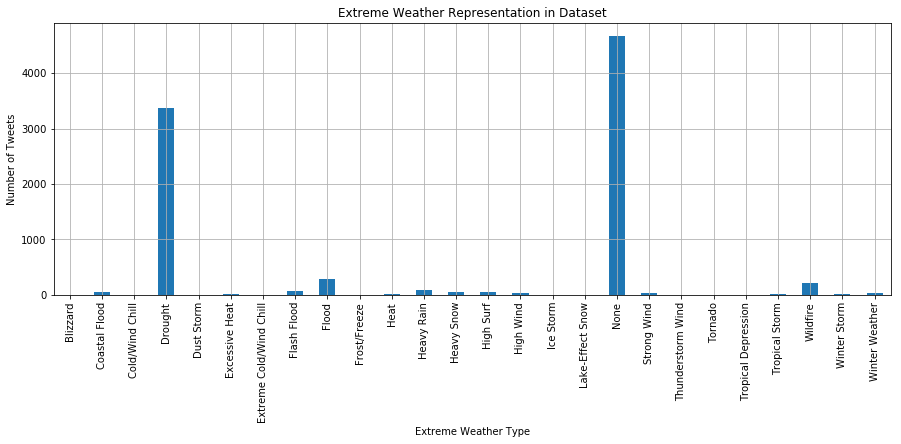

```python
grpd_weather_df['tweet'].count().plot(kind = 'bar', figsize=(15,5))
plt.xlabel('Extreme Weather Type')
plt.ylabel('Number of Tweets')
plt.title('Extreme Weather Representation in Dataset')
plt.grid(True)

plt.show()
```

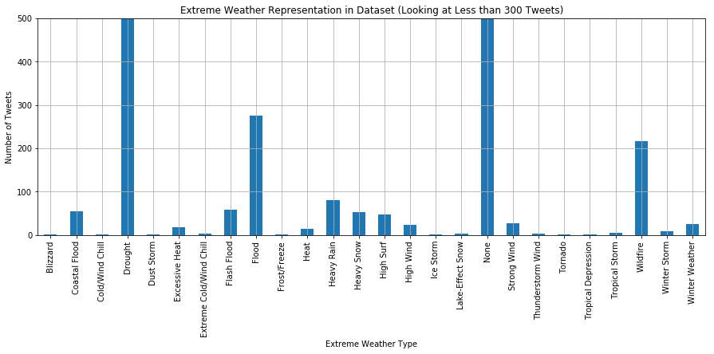

```python
grpd_weather_df['tweet'].count().plot(kind = 'bar', figsize=(15,5))
plt.xlabel('Extreme Weather Type')
plt.ylabel('Number of Tweets')
plt.title('Extreme Weather Representation in Dataset (Looking at Less than 300 Tweets)')
plt.grid(True)
plt.ylim(0,500)
plt.show()
```

It's also important to look at the less frequent extreme weathers. We see things like rain, wind, snow, and winter weather. These are mostly weather events that occur in the winter (which we would expect since the dataset is said to contain mostly tweets from fall to winter).

```python
grpd_state_df = tweet_weather_df.groupby("STATE")
# grpd_state_df['tweet'].count()
```

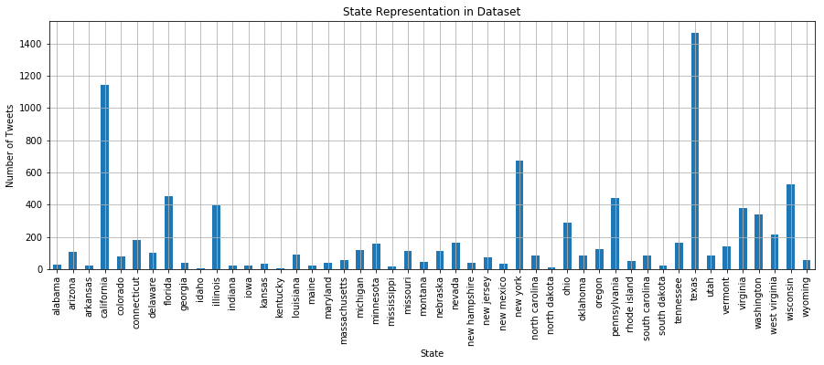

```python
grpd_state_df['tweet'].count().plot(kind = 'bar', figsize=(15,5))
plt.xlabel('State')
plt.ylabel('Number of Tweets')
plt.title('State Representation in Dataset')
plt.grid(True)

plt.show()
```

There is a large representation of tweets from Texas. California and New York come in second and third. They also have large populations. This is very interesting becaues in previous studies of this data set when I looked at small subsets of tweets (like 50,000) instead of just tweets that contain the word "weather", California was dispropotionally over represented and had a lot more than Texas.

```python
grpd_storm_df2 = tweet_weather_df.groupby(["STATE","weather_type"])["tweet"].count()
```

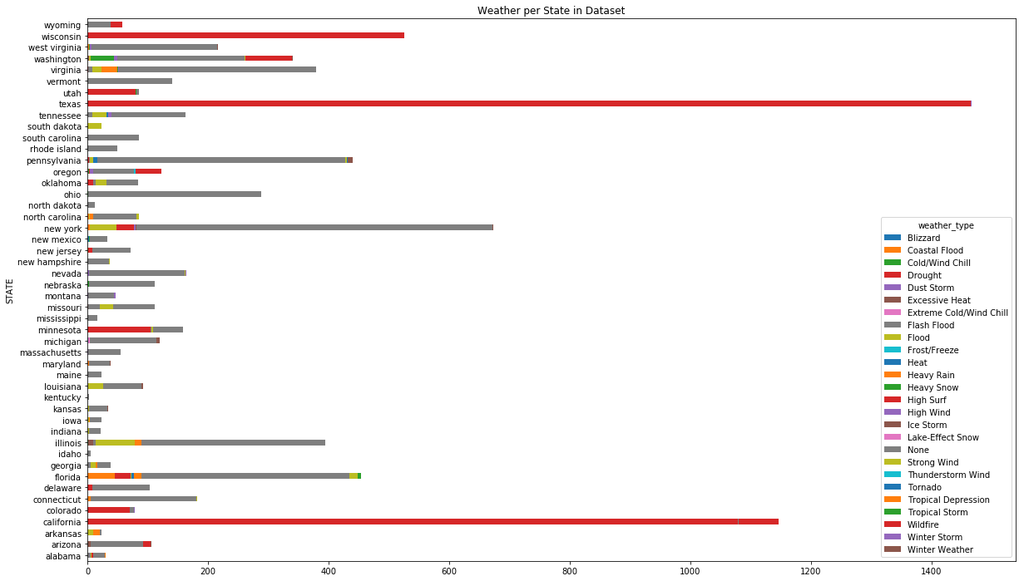

```python
grpd_storm_df2.unstack().plot(kind='barh',stacked=True,title="Weather per State in Dataset", figsize=(20,12))
```

This graph combines both of the information. We can see that the tweets from California were all during the drought for the most part as well as Texas and even Utah. A lot of the tweets divided by states are not durin an extreme weather event.

## Analysis

The main technique I will be using to test for the twitter sentiment is by using a dicionary of positive and negative words. This dictionary was created by Jeffrey Breen for twitter sentiment analysis. https://github.com/jeffreybreen/twitter-sentiment-analysis-tutorial-201107

From there I plan to sort tweets into positive and negative categories and further compare between the two.

Using a dictionary and counting the number of words for sentiment analysis suits this case because we are looking for things that hint at a sentiment. However, as a caution, some of the negative words in already have weather attached, such as rainy.

```python
#loading in the positive and negative lists
pos_list = open("../data_dump/positive_words.txt", encoding='utf-8').read()
neg_list = open("../data_dump/negative_words.txt", encoding='utf-8').read()
```

```python
tweet_weather_df['text_lc'] = tweet_weather_df['tweet'].str.lower()
tweet_weather_df.dropna(subset=['text_lc'], inplace=True)
```

```python
tweet_weather_df
```

|  | user | STATE | tweet | timestamp | weather_type | text_lc |
| --- | --- | --- | --- | --- | --- | --- |
| 0 | 246 | california | @Poormojo yes! Do you mean the good weather ea... | 2009-11-06 17:28:37 | Drought | @poormojo yes! do you mean the good weather ea... |
| 1 | 246 | california | I know three things to be true: SF weather is ... | 2009-11-03 19:07:03 | Drought | i know three things to be true: sf weather is ... |
| 2 | 89 | california | Colder weather is kind of exciting, except for... | 2009-11-06 20:47:45 | Drought | colder weather is kind of exciting, except for... |
| 3 | 89 | california | Did anyone tell the weather it's november? | 2009-11-03 16:07:24 | Drought | did anyone tell the weather it's november? |
| 4 | 10051 | california | that's METARspeak for "nice weather" | 2009-11-08 13:53:29 | Drought | that's metarspeak for "nice weather" |
| 5 | 10051 | california | Headed to Oakland soon, where the weather is K... | 2009-11-08 13:52:09 | Drought | headed to oakland soon, where the weather is k... |
| 6 | 10051 | california | Deciphering DUAT data. I wonder how many pilot... | 2009-11-06 11:27:42 | Drought | deciphering duat data. i wonder how many pilot... |
| 7 | 12263 | california | I have a headache. Damn rainy Syracuse weather. | 2009-10-07 19:39:32 | Drought | i have a headache. damn rainy syracuse weather. |
| 8 | 12263 | california | @chrisspy How are you enjoying your poopy weat... | 2009-09-29 13:47:02 | Drought | @chrisspy how are you enjoying your poopy weat... |
| 9 | 12329 | california | San Francisco's small coastal weather system w... | 2009-10-20 00:49:27 | Drought | san francisco's small coastal weather system w... |
| 10 | 16796955 | california | It's gonna be rainy tonight... do I really wan... | 2009-11-20 11:58:39 | Drought | it's gonna be rainy tonight... do i really wan... |
| 11 | 35685107 | california | Venturing out into the stormy weather for dim ... | 2009-10-13 13:29:13 | Drought | venturing out into the stormy weather for dim ... |
| 12 | 3191321 | california | @laur oh fun! Peeps in hardcore cold weather r... | 2009-11-13 12:05:32 | Drought | @laur oh fun! peeps in hardcore cold weather r... |
| 13 | 17877122 | california | I might curse SF weather during the summer, bu... | 2009-11-03 12:07:37 | Drought | i might curse sf weather during the summer, bu... |
| 14 | 78493781 | california | RT @stevepohlit: All of us could take a lesson... | 2009-12-04 20:31:07 | Drought | rt @stevepohlit: all of us could take a lesson... |
| 15 | 74529880 | california | Mmm, the perfect cold-weather breakfast is coo... | 2009-10-28 10:48:34 | Drought | mmm, the perfect cold-weather breakfast is coo... |
| 16 | 12668172 | california | It's sf weather in Tucson today- it feels norm... | 2009-10-28 10:19:20 | Drought | it's sf weather in tucson today- it feels norm... |
| 17 | 51483994 | california | @gabe_ibarra @gabeion @weatherpending chingon ... | 2009-07-22 21:23:31 | Drought | @gabe_ibarra @gabeion @weatherpending chingon ... |
| 18 | 64068758 | california | The good, the bad & the ugly: This Too Shall P... | 2009-09-06 12:42:43 | Wildfire | the good, the bad & the ugly: this too shall p... |
| 19 | 14349750 | california | Couldn't've asked for better weather today. Ha... | 2009-10-16 17:41:55 | Drought | couldn't've asked for better weather today. ha... |
| 20 | 173283 | california | @qlam that would be enough motivation for me: ... | 2009-11-23 16:16:55 | Drought | @qlam that would be enough motivation for me: ... |
| 21 | 9086282 | california | Ran 5.5 miles and felt good. Nice tempo run af... | 2009-11-17 21:28:21 | Drought | ran 5.5 miles and felt good. nice tempo run af... |
| 22 | 14857135 | california | haha to all of you in crappy weather, it's sun... | 2009-03-19 07:15:03 | Drought | haha to all of you in crappy weather, it's sun... |
| 23 | 47373051 | california | Farmers sell WIVES and DAUGHTERS to weather dr... | 2009-09-16 10:30:42 | Drought | farmers sell wives and daughters to weather dr... |
| 24 | 69398053 | california | How everyone enjoying the weather? | 2009-10-23 17:59:25 | Drought | how everyone enjoying the weather? |
| 25 | 18031093 | california | @ptanthos I agree there is something very wron... | 2009-12-04 02:45:37 | Drought | @ptanthos i agree there is something very wron... |
| 26 | 15940807 | california | Can't wait for chilly weather, hot drinks, war... | 2009-10-01 11:42:53 | Drought | can't wait for chilly weather, hot drinks, war... |
| 27 | 19093324 | california | RT @TimJackson: Winter is coming- are you read... | 2009-11-12 21:02:08 | Drought | rt @timjackson: winter is coming- are you read... |
| 28 | 5972102 | california | My phone meeting didn't happen. Can take a mom... | 2009-04-09 14:07:52 | Drought | my phone meeting didn't happen. can take a mom... |
| 29 | 18049300 | california | What strange New England weather. Two days ago... | 2009-08-27 20:01:44 | Drought | what strange new england weather. two days ago... |
| ... | ... | ... | ... | ... | ... | ... |
| 8932 | 18385743 | south carolina | Feels awesome outside not hot, but not hoodie ... | 2009-09-16 20:09:00 | None | feels awesome outside not hot, but not hoodie ... |
| 8933 | 15524550 | california | I love the rain, this "ugly" weather isn't so ... | 2009-09-14 02:09:00 | Drought | i love the rain, this "ugly" weather isn't so ... |
| 8934 | 22407569 | wisconsin | @weathergirl12 i sure am enjoying the fruit pu... | 2009-09-17 20:09:00 | Drought | @weathergirl12 i sure am enjoying the fruit pu... |
| 8935 | 18421478 | new mexico | @JayBigs mayweather is working in association ... | 2009-09-20 00:09:00 | None | @jaybigs mayweather is working in association ... |
| 8936 | 18278961 | tennessee | Had a great long walk on the beach. Perfect we... | 2009-09-14 22:09:00 | None | had a great long walk on the beach. perfect we... |
| 8937 | 18278961 | tennessee | Went golfing today! Perfect weather, close fam... | 2009-09-15 17:09:00 | None | went golfing today! perfect weather, close fam... |
| 8938 | 59275382 | washington | car show was a bit of a wash out due to the ba... | 2009-09-06 21:09:00 | None | car show was a bit of a wash out due to the ba... |
| 8939 | 19656786 | maryland | sent an email newsletter to clients about SunB... | 2009-08-24 08:48:53 | None | sent an email newsletter to clients about sunb... |
| 8940 | 19656786 | maryland | is recommending an outdoor weatherproof HDTV t... | 2009-09-27 16:46:34 | None | is recommending an outdoor weatherproof hdtv t... |
| 8941 | 59193068 | west virginia | Ughh! I can't stand cold weather! | 2009-09-20 11:09:00 | None | ughh! i can't stand cold weather! |
| 8942 | 27736121 | new jersey | Finally out of work and it is gorgeous outside... | 2009-09-18 16:09:00 | None | finally out of work and it is gorgeous outside... |
| 8943 | 35083521 | nebraska | Listening to @cantonjones "So Bad" on iheartra... | 2009-09-19 22:09:00 | None | listening to @cantonjones "so bad" on iheartra... |
| 8944 | 35083521 | nebraska | Mayweather in 6!! RT @rolandsmartin Who will w... | 2009-09-19 22:09:00 | None | mayweather in 6!! rt @rolandsmartin who will w... |
| 8945 | 27762984 | california | Mayweather wins. Go black people... | 2009-09-20 00:09:00 | Drought | mayweather wins. go black people... |
| 8946 | 19430167 | new york | there a reason y pride is one of the seven dea... | 2009-09-14 21:09:00 | None | there a reason y pride is one of the seven dea... |
| 8947 | 17500037 | illinois | eating soup for lunch. It seems too soon to b... | 2009-09-21 12:15:32 | None | eating soup for lunch. it seems too soon to b... |
| 8948 | 58317980 | louisiana | It's yucky and rainy outside-good sleeping wea... | 2009-09-17 07:09:00 | None | it's yucky and rainy outside-good sleeping wea... |
| 8949 | 26929448 | oklahoma | Every time the weather changes, my heart is al... | 2009-09-22 16:36:47 | Flood | every time the weather changes, my heart is al... |
| 8950 | 54201423 | texas | Today's weather was amazing! Not too hot not t... | 2009-09-21 22:09:00 | Drought | today's weather was amazing! not too hot not t... |
| 8951 | 13446262 | idaho | RT @Tonweather: What is an RSS? And why do I h... | 2009-09-22 09:57:21 | None | rt @tonweather: what is an rss? and why do i h... |
| 8952 | 13446262 | idaho | @Tonweather My RSS's ribs are showing. It's qu... | 2009-09-22 10:17:46 | None | @tonweather my rss's ribs are showing. it's qu... |
| 8953 | 22782569 | kentucky | @IKBD dress for the weather next time kid. | 2009-09-24 12:10:56 | None | @ikbd dress for the weather next time kid. |
| 8954 | 7098002 | texas | Last day off, then back to work. Im so excited... | 2009-09-23 08:53:14 | Drought | last day off, then back to work. im so excited... |
| 8955 | 37549350 | ohio | Thanks to Family and Friends who attened the B... | 2009-07-04 21:07:00 | None | thanks to family and friends who attened the b... |
| 8956 | 59283196 | new jersey | Martell's tiki bar show this afternoon cancell... | 2009-09-11 11:32:04 | High Surf | martell's tiki bar show this afternoon cancell... |
| 8957 | 57547051 | virginia | lovin the cool weather... not lovin my winter ... | 2009-09-22 17:48:42 | None | lovin the cool weather... not lovin my winter ... |
| 8958 | 51275792 | washington | @shaycarl whats up shay how is the wonderful w... | 2009-07-22 14:58:02 | None | @shaycarl whats up shay how is the wonderful w... |
| 8959 | 53396096 | wisconsin | is back to our regular schedule. The wedding ... | 2009-09-21 10:05:12 | Drought | is back to our regular schedule. the wedding ... |
| 8960 | 27236980 | oklahoma | This could be the last day we see summer weath... | 2009-09-20 08:37:21 | None | this could be the last day we see summer weath... |
| 8961 | 27236980 | oklahoma | beautiful weather , nice chill in the air dry ... | 2009-09-23 11:51:30 | Flood | beautiful weather , nice chill in the air dry ... |

8962 rows × 6 columns

```python
#tokenize
tweet_weather_df['text_token'] = tweet_weather_df['text_lc'].apply(word_tokenize)
tweet_weather_df['text_token']
```

```
0       [@, poormojo, yes, !, do, you, mean, the, good...
1       [i, know, three, things, to, be, true, :, sf, ...
2       [colder, weather, is, kind, of, exciting, ,, e...
3       [did, anyone, tell, the, weather, it, 's, nove...
4       [that, 's, metarspeak, for, ``, nice, weather,...
5       [headed, to, oakland, soon, ,, where, the, wea...
6       [deciphering, duat, data, ., i, wonder, how, m...
7       [i, have, a, headache, ., damn, rainy, syracus...
8       [@, chrisspy, how, are, you, enjoying, your, p...
9       [san, francisco, 's, small, coastal, weather, ...
10      [it, 's, gon, na, be, rainy, tonight, ..., do,...
11      [venturing, out, into, the, stormy, weather, f...
12      [@, laur, oh, fun, !, peeps, in, hardcore, col...
13      [i, might, curse, sf, weather, during, the, su...
14      [rt, @, stevepohlit, :, all, of, us, could, ta...
```

[output cut: 47 more lines]

```python
#Removing stopwords
#import the stopwords list

from nltk.corpus import stopwords

stopwords = stopwords.words('english')

tweet_weather_df['text_token_no_stop'] = tweet_weather_df['text_token'].apply(lambda x: [word for word in x if word not in stopwords])
tweet_weather_df['text_token_no_stop']
```

```
0       [@, poormojo, yes, !, mean, good, weather, ear...
1       [know, three, things, true, :, sf, weather, am...
2       [colder, weather, kind, exciting, ,, except, w...
3                [anyone, tell, weather, 's, november, ?]
4                 ['s, metarspeak, ``, nice, weather, '']
5       [headed, oakland, soon, ,, weather, koak, 0818...
6       [deciphering, duat, data, ., wonder, many, pil...
7        [headache, ., damn, rainy, syracuse, weather, .]
8       [@, chrisspy, enjoying, poopy, weather, ?, hah...
9       [san, francisco, 's, small, coastal, weather, ...
10      ['s, gon, na, rainy, tonight, ..., really, wan...
11      [venturing, stormy, weather, dim, sum, tea, bu...
12      [@, laur, oh, fun, !, peeps, hardcore, cold, w...
13      [might, curse, sf, weather, summer, ,, ca, n't...
14      [rt, @, stevepohlit, :, us, could, take, lesso...
```

[output cut: 47 more lines]

```python
#Calculate and print the total number of positive & negative words for no stopwords
tweet_weather_df['tokens_pos'] = tweet_weather_df['text_token'].apply(lambda x: [word for word in x if word in pos_list])
tweet_weather_df['pos_count'] = tweet_weather_df['tokens_pos'].apply(len)
tweet_weather_df['tokens_neg'] = tweet_weather_df['text_token'].apply(lambda x: [word for word in x if word in neg_list])
tweet_weather_df['neg_count'] = tweet_weather_df['tokens_neg'].apply(len)
```

```python
#Calculate and print the total number of positive & negative words
tweet_weather_df['tokens_pos_no_stop'] = tweet_weather_df['text_token_no_stop'].apply(lambda x: [word for word in x if word in pos_list])
tweet_weather_df['pos_count_no_stop'] = tweet_weather_df['tokens_pos'].apply(len)
tweet_weather_df['tokens_neg_no_stop'] = tweet_weather_df['text_token_no_stop'].apply(lambda x: [word for word in x if word in neg_list])
tweet_weather_df['neg_count_no_stop'] = tweet_weather_df['tokens_neg'].apply(len)
```

```python
# Create a new column that contains the proportion of positive words
tweet_weather_df['pos_count_prop'] = tweet_weather_df['pos_count']/tweet_weather_df['text_token'].apply(len)
tweet_weather_df['neg_count_prop'] = tweet_weather_df['neg_count']/tweet_weather_df['text_token'].apply(len)
```

```python
# Create a new column that contains the proportion of positive words for NO STOP WORDS
tweet_weather_df['pos_count_prop_no_stop'] = tweet_weather_df['pos_count_no_stop']/tweet_weather_df['text_token_no_stop'].apply(len)
tweet_weather_df['neg_count_prop_no_stop'] = tweet_weather_df['neg_count_no_stop']/tweet_weather_df['text_token_no_stop'].apply(len)
tweet_weather_df
```

|  | user | STATE | tweet | timestamp | weather_type | text_lc | text_token | text_token_no_stop | tokens_pos | pos_count | tokens_neg | neg_count | tokens_pos_no_stop | pos_count_no_stop | tokens_neg_no_stop | neg_count_no_stop | pos_count_prop | neg_count_prop | pos_count_prop_no_stop | neg_count_prop_no_stop |
| --- | --- | --- | --- | --- | --- | --- | --- | --- | --- | --- | --- | --- | --- | --- | --- | --- | --- | --- | --- | --- |
| 0 | 246 | california | @Poormojo yes! Do you mean the good weather ea... | 2009-11-06 17:28:37 | Drought | @poormojo yes! do you mean the good weather ea... | [@, poormojo, yes, !, do, you, mean, the, good... | [@, poormojo, yes, !, mean, good, weather, ear... | [do, you, mean, the, good, or, the] | 7 | [yes, do, mean, the, or, the, bad] | 7 | [mean, good] | 7 | [yes, mean, bad] | 7 | 0.350000 | 0.350000 | 0.500000 | 0.500000 |
| 1 | 246 | california | I know three things to be true: SF weather is ... | 2009-11-03 19:07:03 | Drought | i know three things to be true: sf weather is ... | [i, know, three, things, to, be, true, :, sf, ... | [know, three, things, true, :, sf, weather, am... | [i, know, to, be, sf, is, amazing, new, is, am... | 12 | [i, know, three, to, be, true, sf, is, is, and... | 11 | [know, sf, amazing, new, amazing, exciting] | 12 | [know, three, true, sf, day] | 11 | 0.428571 | 0.392857 | 0.571429 | 0.523810 |
| 2 | 89 | california | Colder weather is kind of exciting, except for... | 2009-11-06 20:47:45 | Drought | colder weather is kind of exciting, except for... | [colder, weather, is, kind, of, exciting, ,, e... | [colder, weather, kind, exciting, ,, except, w... | [is, kind, of, exciting, except, for, the, who... | 10 | [is, kind, of, for, the, cold, thing] | 7 | [kind, exciting, except, whole, thing] | 10 | [kind, cold, thing] | 7 | 0.666667 | 0.466667 | 1.000000 | 0.700000 |
| 3 | 89 | california | Did anyone tell the weather it's november? | 2009-11-03 16:07:24 | Drought | did anyone tell the weather it's november? | [did, anyone, tell, the, weather, it, 's, nove... | [anyone, tell, weather, 's, november, ?] | [did, tell, the, it] | 4 | [did, tell, the, it] | 4 | [tell] | 4 | [tell] | 4 | 0.444444 | 0.444444 | 0.666667 | 0.666667 |
| 4 | 10051 | california | that's METARspeak for "nice weather" | 2009-11-08 13:53:29 | Drought | that's metarspeak for "nice weather" | [that, 's, metarspeak, for, ``, nice, weather,... | ['s, metarspeak, ``, nice, weather, ''] | [for, nice] | 2 | [for] | 1 | [nice] | 2 | [] | 1 | 0.250000 | 0.125000 | 0.333333 | 0.166667 |
| 5 | 10051 | california | Headed to Oakland soon, where the weather is K... | 2009-11-08 13:52:09 | Drought | headed to oakland soon, where the weather is k... | [headed, to, oakland, soon, ,, where, the, wea... | [headed, oakland, soon, ,, weather, koak, 0818... | [to, the, is] | 3 | [headed, to, the, is] | 4 | [] | 3 | [headed] | 4 | 0.150000 | 0.200000 | 0.187500 | 0.250000 |
| 6 | 10051 | california | Deciphering DUAT data. I wonder how many pilot... | 2009-11-06 11:27:42 | Drought | deciphering duat data. i wonder how many pilot... | [deciphering, duat, data, ., i, wonder, how, m... | [deciphering, duat, data, ., wonder, many, pil... | [i, wonder, have, of, for, of, on, a] | 8 | [i, how, have, died, of, for, of, on, a] | 9 | [wonder] | 8 | [died] | 9 | 0.320000 | 0.360000 | 0.500000 | 0.562500 |
| 7 | 12263 | california | I have a headache. Damn rainy Syracuse weather. | 2009-10-07 19:39:32 | Drought | i have a headache. damn rainy syracuse weather. | [i, have, a, headache, ., damn, rainy, syracus... | [headache, ., damn, rainy, syracuse, weather, .] | [i, have, a, rainy] | 4 | [i, have, a, headache, damn, rainy] | 6 | [rainy] | 4 | [headache, damn, rainy] | 6 | 0.400000 | 0.600000 | 0.571429 | 0.857143 |
| 8 | 12263 | california | @chrisspy How are you enjoying your poopy weat... | 2009-09-29 13:47:02 | Drought | @chrisspy how are you enjoying your poopy weat... | [@, chrisspy, how, are, you, enjoying, your, p... | [@, chrisspy, enjoying, poopy, weather, ?, hah... | [are, you, enjoying] | 3 | [how, are] | 2 | [enjoying] | 3 | [] | 2 | 0.250000 | 0.166667 | 0.375000 | 0.250000 |
| 9 | 12329 | california | San Francisco's small coastal weather system w... | 2009-10-20 00:49:27 | Drought | san francisco's small coastal weather system w... | [san, francisco, 's, small, coastal, weather, ... | [san, francisco, 's, small, coastal, weather, ... | [san, like, you, to, know] | 5 | [san, small, like, to, know] | 5 | [san, like, know] | 5 | [san, small, like, know] | 5 | 0.294118 | 0.294118 | 0.357143 | 0.357143 |
| 10 | 16796955 | california | It's gonna be rainy tonight... do I really wan... | 2009-11-20 11:58:39 | Drought | it's gonna be rainy tonight... do i really wan... | [it, 's, gon, na, be, rainy, tonight, ..., do,... | ['s, gon, na, rainy, tonight, ..., really, wan... | [it, gon, na, be, rainy, do, i, to, around, in... | 14 | [it, gon, na, be, rainy, do, i, want, to, in, ... | 14 | [gon, na, rainy, around] | 14 | [gon, na, rainy, want] | 14 | 0.451613 | 0.451613 | 0.700000 | 0.700000 |
| 11 | 35685107 | california | Venturing out into the stormy weather for dim ... | 2009-10-13 13:29:13 | Drought | venturing out into the stormy weather for dim ... | [venturing, out, into, the, stormy, weather, f... | [venturing, stormy, weather, dim, sum, tea, bu... | [out, the, for, sum, and, tea, in] | 7 | [out, into, the, stormy, for, dim, sum, and, t... | 10 | [sum, tea] | 7 | [stormy, dim, sum, tea] | 10 | 0.466667 | 0.666667 | 0.777778 | 1.111111 |
| 12 | 3191321 | california | @laur oh fun! Peeps in hardcore cold weather r... | 2009-11-13 12:05:32 | Drought | @laur oh fun! peeps in hardcore cold weather r... | [@, laur, oh, fun, !, peeps, in, hardcore, col... | [@, laur, oh, fun, !, peeps, hardcore, cold, w... | [oh, fun, in, look, ass, for, the, up] | 8 | [oh, fun, in, cold, look, bad, ass, for, the, up] | 10 | [oh, fun, look, ass] | 8 | [oh, fun, cold, look, bad, ass] | 10 | 0.363636 | 0.454545 | 0.444444 | 0.555556 |
| 13 | 17877122 | california | I might curse SF weather during the summer, bu... | 2009-11-03 12:07:37 | Drought | i might curse sf weather during the summer, bu... | [i, might, curse, sf, weather, during, the, su... | [might, curse, sf, weather, summer, ,, ca, n't... | [i, might, sf, the, but, you, ca, beat, perfec... | 10 | [i, curse, sf, the, but, ca, beat, perfect, in] | 9 | [might, sf, ca, beat, perfect] | 10 | [curse, sf, ca, beat, perfect] | 9 | 0.454545 | 0.409091 | 0.625000 | 0.562500 |
| 14 | 78493781 | california | RT @stevepohlit: All of us could take a lesson... | 2009-12-04 20:31:07 | Drought | rt @stevepohlit: all of us could take a lesson... | [rt, @, stevepohlit, :, all, of, us, could, ta... | [rt, @, stevepohlit, :, us, could, take, lesso... | [rt, all, of, us, take, a, the, it, no, to, and] | 11 | [rt, all, of, us, take, a, the, it, no, to, cr... | 14 | [rt, us, take] | 11 | [rt, us, take, criticism, funny, true] | 14 | 0.407407 | 0.518519 | 0.611111 | 0.777778 |
| 15 | 74529880 | california | Mmm, the perfect cold-weather breakfast is coo... | 2009-10-28 10:48:34 | Drought | mmm, the perfect cold-weather breakfast is coo... | [mmm, ,, the, perfect, cold-weather, breakfast... | [mmm, ,, perfect, cold-weather, breakfast, coo... | [the, perfect, is, up, right, now, some] | 7 | [the, perfect, is, up, right, now, some, jam] | 8 | [perfect, right] | 7 | [perfect, right, jam] | 8 | 0.291667 | 0.333333 | 0.368421 | 0.421053 |
| 16 | 12668172 | california | It's sf weather in Tucson today- it feels norm... | 2009-10-28 10:19:20 | Drought | it's sf weather in tucson today- it feels norm... | [it, 's, sf, weather, in, tucson, today-, it, ... | ['s, sf, weather, tucson, today-, feels, norma... | [it, sf, in, it, and, now, i, can, the, rest, ... | 16 | [it, sf, in, it, normal, and, cold, now, i, ca... | 21 | [sf, rest, since] | 16 | [sf, normal, cold, wear, rest, useless, since,... | 21 | 0.516129 | 0.677419 | 1.000000 | 1.312500 |
| 17 | 51483994 | california | @gabe_ibarra @gabeion @weatherpending chingon ... | 2009-07-22 21:23:31 | Drought | @gabe_ibarra @gabeion @weatherpending chingon ... | [@, gabe_ibarra, @, gabeion, @, weatherpending... | [@, gabe_ibarra, @, gabeion, @, weatherpending... | [que, te, das, una, por, san] | 6 | [que, te, das, una, por, san] | 6 | [que, te, das, una, por, san] | 6 | [que, te, das, una, por, san] | 6 | 0.260870 | 0.260870 | 0.260870 | 0.260870 |
| 18 | 64068758 | california | The good, the bad & the ugly: This Too Shall P... | 2009-09-06 12:42:43 | Wildfire | the good, the bad & the ugly: this too shall p... | [the, good, ,, the, bad, &, the, ugly, :, this... | [good, ,, bad, &, ugly, :, shall, pass, ., sav... | [the, good, the, the, too, pass, so, i, can, t... | 12 | [the, the, bad, the, ugly, too, shall, pass, s... | 15 | [good, pass, balance] | 12 | [bad, ugly, shall, pass, savor, balance] | 15 | 0.413793 | 0.517241 | 0.666667 | 0.833333 |
| 19 | 14349750 | california | Couldn't've asked for better weather today. Ha... | 2009-10-16 17:41:55 | Drought | couldn't've asked for better weather today. ha... | [couldn't, 've, asked, for, better, weather, t... | [couldn't, 've, asked, better, weather, today,... | [for, better, to, take, advantage, and, play, a] | 8 | [for, had, to, take, advantage, and, play, a, ... | 9 | [better, take, advantage, play] | 8 | [take, advantage, play, little] | 9 | 0.444444 | 0.500000 | 0.615385 | 0.692308 |
| 20 | 173283 | california | @qlam that would be enough motivation for me: ... | 2009-11-23 16:16:55 | Drought | @qlam that would be enough motivation for me: ... | [@, qlam, that, would, be, enough, motivation,... | [@, qlam, would, enough, motivation, :, bad, w... | [be, enough, for, me, way, to, pass, time] | 8 | [be, for, me, bad, way, to, pass, time] | 8 | [enough, way, pass, time] | 8 | [bad, way, pass, time] | 8 | 0.470588 | 0.470588 | 0.666667 | 0.666667 |
| 21 | 9086282 | california | Ran 5.5 miles and felt good. Nice tempo run af... | 2009-11-17 21:28:21 | Drought | ran 5.5 miles and felt good. nice tempo run af... | [ran, 5.5, miles, and, felt, good, ., nice, te... | [ran, 5.5, miles, felt, good, ., nice, tempo, ... | [ran, miles, and, felt, good, nice, run, a, fe... | 20 | [ran, and, run, a, off, fast, and, love, in, s... | 14 | [ran, miles, felt, good, nice, run, felt, fast... | 20 | [ran, run, fast, love, sf, -, light, rain] | 14 | 0.625000 | 0.437500 | 0.869565 | 0.608696 |
| 22 | 14857135 | california | haha to all of you in crappy weather, it's sun... | 2009-03-19 07:15:03 | Drought | haha to all of you in crappy weather, it's sun... | [haha, to, all, of, you, in, crappy, weather, ... | [haha, crappy, weather, ,, 's, sunny, 75, hono... | [to, all, of, you, in, it, and, in] | 8 | [to, all, of, in, crappy, it, and, in] | 8 | [] | 8 | [crappy] | 8 | 0.444444 | 0.444444 | 0.800000 | 0.800000 |
| 23 | 47373051 | california | Farmers sell WIVES and DAUGHTERS to weather dr... | 2009-09-16 10:30:42 | Drought | farmers sell wives and daughters to weather dr... | [farmers, sell, wives, and, daughters, to, wea... | [farmers, sell, wives, daughters, weather, dro... | [sell, and, to, world] | 4 | [and, to, drought, recession] | 4 | [sell, world] | 4 | [drought, recession] | 4 | 0.173913 | 0.173913 | 0.190476 | 0.190476 |
| 24 | 69398053 | california | How everyone enjoying the weather? | 2009-10-23 17:59:25 | Drought | how everyone enjoying the weather? | [how, everyone, enjoying, the, weather, ?] | [everyone, enjoying, weather, ?] | [enjoying, the] | 2 | [how, the] | 2 | [enjoying] | 2 | [] | 2 | 0.333333 | 0.333333 | 0.500000 | 0.500000 |
| 25 | 18031093 | california | @ptanthos I agree there is something very wron... | 2009-12-04 02:45:37 | Drought | @ptanthos i agree there is something very wron... | [@, ptanthos, i, agree, there, is, something, ... | [@, ptanthos, agree, something, wrong, type, w... | [i, agree, is, very, of] | 5 | [i, agree, there, is, wrong, type, of] | 7 | [agree] | 5 | [agree, wrong, type] | 7 | 0.333333 | 0.466667 | 0.625000 | 0.875000 |
| 26 | 15940807 | california | Can't wait for chilly weather, hot drinks, war... | 2009-10-01 11:42:53 | Drought | can't wait for chilly weather, hot drinks, war... | [ca, n't, wait, for, chilly, weather, ,, hot, ... | [ca, n't, wait, chilly, weather, ,, hot, drink... | [ca, for, hot, warm, and, the] | 6 | [ca, for, chilly, hot, warm, and, the] | 7 | [ca, hot, warm] | 6 | [ca, chilly, hot, warm] | 7 | 0.315789 | 0.368421 | 0.375000 | 0.437500 |
| 27 | 19093324 | california | RT @TimJackson: Winter is coming- are you read... | 2009-11-12 21:02:08 | Drought | rt @timjackson: winter is coming- are you read... | [rt, @, timjackson, :, winter, is, coming-, ar... | [rt, @, timjackson, :, winter, coming-, ready,... | [rt, is, are, you, ready, do, give, up, just, ... | 11 | [rt, is, are, do, up, just, the, ugly] | 8 | [rt, ready, give, geek] | 11 | [rt, ugly] | 8 | 0.379310 | 0.275862 | 0.523810 | 0.380952 |
| 28 | 5972102 | california | My phone meeting didn't happen. Can take a mom... | 2009-04-09 14:07:52 | Drought | my phone meeting didn't happen. can take a mom... | [my, phone, meeting, did, n't, happen, ., can,... | [phone, meeting, n't, happen, ., take, moment,... | [my, did, can, take, a, moment, to, enjoy, our... | 10 | [my, did, can, take, a, to, our] | 7 | [take, moment, enjoy, lovely] | 10 | [take] | 7 | 0.588235 | 0.411765 | 0.909091 | 0.636364 |
| 29 | 18049300 | california | What strange New England weather. Two days ago... | 2009-08-27 20:01:44 | Drought | what strange new england weather. two days ago... | [what, strange, new, england, weather, ., two,... | [strange, new, england, weather, ., two, days,... | [new, two, i, the, i, a] | 6 | [strange, two, ago, i, the, heat, i, a] | 8 | [new, two] | 6 | [strange, two, ago, heat] | 8 | 0.230769 | 0.307692 | 0.300000 | 0.400000 |
| ... | ... | ... | ... | ... | ... | ... | ... | ... | ... | ... | ... | ... | ... | ... | ... | ... | ... | ... | ... | ... |
| 8932 | 18385743 | south carolina | Feels awesome outside not hot, but not hoodie ... | 2009-09-16 20:09:00 | None | feels awesome outside not hot, but not hoodie ... | [feels, awesome, outside, not, hot, ,, but, no... | [feels, awesome, outside, hot, ,, hoodie, weat... | [awesome, not, hot, but, not, though, i, ca] | 8 | [outside, not, hot, but, not, yet, though, i, ca] | 9 | [awesome, hot, though, ca] | 8 | [outside, hot, yet, though, ca] | 9 | 0.347826 | 0.391304 | 0.421053 | 0.473684 |
| 8933 | 15524550 | california | I love the rain, this "ugly" weather isn't so ... | 2009-09-14 02:09:00 | Drought | i love the rain, this "ugly" weather isn't so ... | [i, love, the, rain, ,, this, ``, ugly, '', we... | [love, rain, ,, ``, ugly, '', weather, n't, ugly] | [i, love, the, rain, is, so, to, me] | 8 | [i, love, the, rain, ugly, is, so, ugly, to, me] | 10 | [love, rain] | 8 | [love, rain, ugly, ugly] | 10 | 0.500000 | 0.625000 | 0.888889 | 1.111111 |
| 8934 | 22407569 | wisconsin | @weathergirl12 i sure am enjoying the fruit pu... | 2009-09-17 20:09:00 | Drought | @weathergirl12 i sure am enjoying the fruit pu... | [@, weathergirl12, i, sure, am, enjoying, the,... | [@, weathergirl12, sure, enjoying, fruit, punc... | [i, sure, am, enjoying, the, fruit] | 6 | [i, sure, am, the, fruit, punch] | 6 | [sure, enjoying, fruit] | 6 | [sure, fruit, punch] | 6 | 0.545455 | 0.545455 | 0.750000 | 0.750000 |
| 8935 | 18421478 | new mexico | @JayBigs mayweather is working in association ... | 2009-09-20 00:09:00 | None | @jaybigs mayweather is working in association ... | [@, jaybigs, mayweather, is, working, in, asso... | [@, jaybigs, mayweather, working, association,... | [is, working, in, he, his, he, consider, a, ru... | 10 | [is, in, he, his, he, consider, a, run, the] | 9 | [working, consider, run] | 10 | [consider, run] | 9 | 0.400000 | 0.360000 | 0.666667 | 0.600000 |
| 8936 | 18278961 | tennessee | Had a great long walk on the beach. Perfect we... | 2009-09-14 22:09:00 | None | had a great long walk on the beach. perfect we... | [had, a, great, long, walk, on, the, beach, .,... | [great, long, walk, beach, ., perfect, weather... | [a, great, long, on, the, perfect] | 6 | [had, a, long, on, the, perfect] | 6 | [great, long, perfect] | 6 | [long, perfect] | 6 | 0.500000 | 0.500000 | 0.750000 | 0.750000 |
| 8937 | 18278961 | tennessee | Went golfing today! Perfect weather, close fam... | 2009-09-15 17:09:00 | None | went golfing today! perfect weather, close fam... | [went, golfing, today, !, perfect, weather, ,,... | [went, golfing, today, !, perfect, weather, ,,... | [perfect, great, friend, priceless, now, on, t... | 10 | [perfect, friend, now, on, to, the] | 6 | [perfect, great, friend, priceless, park, loving] | 10 | [perfect, friend] | 6 | 0.384615 | 0.230769 | 0.454545 | 0.272727 |
| 8938 | 59275382 | washington | car show was a bit of a wash out due to the ba... | 2009-09-06 21:09:00 | None | car show was a bit of a wash out due to the ba... | [car, show, was, a, bit, of, a, wash, out, due... | [car, show, bit, wash, due, bad, weather, .., ... | [car, a, bit, of, a, out, to, the, felt, for, ... | 11 | [car, show, was, a, bit, of, a, wash, out, due... | 16 | [car, bit, felt] | 11 | [car, show, bit, wash, due, bad, bad] | 16 | 0.478261 | 0.695652 | 0.785714 | 1.142857 |
| 8939 | 19656786 | maryland | sent an email newsletter to clients about SunB... | 2009-08-24 08:48:53 | None | sent an email newsletter to clients about sunb... | [sent, an, email, newsletter, to, clients, abo... | [sent, email, newsletter, clients, sunbritetv,... | [an, to, for, in] | 4 | [sent, an, to, for, in] | 5 | [] | 4 | [sent] | 5 | 0.181818 | 0.227273 | 0.235294 | 0.294118 |
| 8940 | 19656786 | maryland | is recommending an outdoor weatherproof HDTV t... | 2009-09-27 16:46:34 | None | is recommending an outdoor weatherproof hdtv t... | [is, recommending, an, outdoor, weatherproof, ... | [recommending, outdoor, weatherproof, hdtv, cl... | [is, an, to, a, in, detachable] | 6 | [is, an, to, a, in] | 5 | [detachable] | 6 | [] | 5 | 0.250000 | 0.208333 | 0.333333 | 0.277778 |
| 8941 | 59193068 | west virginia | Ughh! I can't stand cold weather! | 2009-09-20 11:09:00 | None | ughh! i can't stand cold weather! | [ughh, !, i, ca, n't, stand, cold, weather, !] | [ughh, !, ca, n't, stand, cold, weather, !] | [i, ca, stand] | 3 | [i, ca, stand, cold] | 4 | [ca, stand] | 3 | [ca, stand, cold] | 4 | 0.333333 | 0.444444 | 0.375000 | 0.500000 |
| 8942 | 27736121 | new jersey | Finally out of work and it is gorgeous outside... | 2009-09-18 16:09:00 | None | finally out of work and it is gorgeous outside... | [finally, out, of, work, and, it, is, gorgeous... | [finally, work, gorgeous, outside, :, ), love,... | [out, of, work, and, it, is, gorgeous, love] | 8 | [out, of, work, and, it, is, outside, love] | 8 | [work, gorgeous, love] | 8 | [work, outside, love] | 8 | 0.533333 | 0.533333 | 0.888889 | 0.888889 |
| 8943 | 35083521 | nebraska | Listening to @cantonjones "So Bad" on iheartra... | 2009-09-19 22:09:00 | None | listening to @cantonjones "so bad" on iheartra... | [listening, to, @, cantonjones, ``, so, bad, '... | [listening, @, cantonjones, ``, bad, '', ihear... | [listening, to, so, on, on, my, while, for, the] | 9 | [to, so, bad, on, on, my, for, the] | 8 | [listening] | 9 | [bad] | 8 | 0.409091 | 0.363636 | 0.642857 | 0.571429 |
| 8944 | 35083521 | nebraska | Mayweather in 6!! RT @rolandsmartin Who will w... | 2009-09-19 22:09:00 | None | mayweather in 6!! rt @rolandsmartin who will w... | [mayweather, in, 6, !, !, rt, @, rolandsmartin... | [mayweather, 6, !, !, rt, @, rolandsmartin, wi... | [in, rt, who, will, win, or] | 6 | [in, rt, who, will, win, or] | 6 | [rt, win] | 6 | [rt, win] | 6 | 0.375000 | 0.375000 | 0.500000 | 0.500000 |
| 8945 | 27762984 | california | Mayweather wins. Go black people... | 2009-09-20 00:09:00 | Drought | mayweather wins. go black people... | [mayweather, wins, ., go, black, people, ...] | [mayweather, wins, ., go, black, people, ...] | [wins, go] | 2 | [go, black] | 2 | [wins, go] | 2 | [go, black] | 2 | 0.285714 | 0.285714 | 0.285714 | 0.285714 |
| 8946 | 19430167 | new york | there a reason y pride is one of the seven dea... | 2009-09-14 21:09:00 | None | there a reason y pride is one of the seven dea... | [there, a, reason, y, pride, is, one, of, the,... | [reason, pride, one, seven, deadly, sin, (, we... | [a, reason, y, pride, is, one, of, the, sin, u... | 12 | [there, a, reason, y, pride, is, one, of, the,... | 14 | [reason, pride, one, sin, ur] | 12 | [reason, pride, one, deadly, sin, ur] | 14 | 0.631579 | 0.736842 | 1.090909 | 1.272727 |
| 8947 | 17500037 | illinois | eating soup for lunch. It seems too soon to b... | 2009-09-21 12:15:32 | None | eating soup for lunch. it seems too soon to b... | [eating, soup, for, lunch, ., it, seems, too, ... | [eating, soup, lunch, ., seems, soon, soup, we... | [eating, for, it, too, to, be] | 6 | [eating, for, it, too, to, be] | 6 | [eating] | 6 | [eating] | 6 | 0.428571 | 0.428571 | 0.666667 | 0.666667 |
| 8948 | 58317980 | louisiana | It's yucky and rainy outside-good sleeping wea... | 2009-09-17 07:09:00 | None | it's yucky and rainy outside-good sleeping wea... | [it, 's, yucky, and, rainy, outside-good, slee... | ['s, yucky, rainy, outside-good, sleeping, wea... | [it, and, rainy] | 3 | [it, and, rainy] | 3 | [rainy] | 3 | [rainy] | 3 | 0.333333 | 0.333333 | 0.428571 | 0.428571 |
| 8949 | 26929448 | oklahoma | Every time the weather changes, my heart is al... | 2009-09-22 16:36:47 | Flood | every time the weather changes, my heart is al... | [every, time, the, weather, changes, ,, my, he... | [every, time, weather, changes, ,, heart, alwa... | [time, the, my, heart, is, and, fall, is, here] | 9 | [time, the, my, heart, is, moved, and, fall, i... | 10 | [time, heart, fall] | 9 | [time, heart, moved, fall] | 10 | 0.500000 | 0.555556 | 0.750000 | 0.833333 |
| 8950 | 54201423 | texas | Today's weather was amazing! Not too hot not t... | 2009-09-21 22:09:00 | Drought | today's weather was amazing! not too hot not t... | [today, 's, weather, was, amazing, !, not, too... | [today, 's, weather, amazing, !, hot, cold, !,... | [amazing, not, too, hot, not, too, fall, is, h... | 9 | [was, not, too, hot, not, too, cold, fall, is,... | 10 | [amazing, hot, fall] | 9 | [hot, cold, fall] | 10 | 0.473684 | 0.526316 | 0.750000 | 0.833333 |
| 8951 | 13446262 | idaho | RT @Tonweather: What is an RSS? And why do I h... | 2009-09-22 09:57:21 | None | rt @tonweather: what is an rss? and why do i h... | [rt, @, tonweather, :, what, is, an, rss, ?, a... | [rt, @, tonweather, :, rss, ?, feed, ?, (, may... | [rt, is, an, and, do, i, have, to, it, it, jus... | 15 | [rt, is, an, and, do, i, have, to, feed, it, i... | 16 | [rt, made] | 15 | [rt, feed, laugh] | 16 | 0.468750 | 0.500000 | 0.937500 | 1.000000 |
| 8952 | 13446262 | idaho | @Tonweather My RSS's ribs are showing. It's qu... | 2009-09-22 10:17:46 | None | @tonweather my rss's ribs are showing. it's qu... | [@, tonweather, my, rss, 's, ribs, are, showin... | [@, tonweather, rss, 's, ribs, showing, ., 's,... | [my, are, it] | 3 | [my, are, it] | 3 | [] | 3 | [] | 3 | 0.214286 | 0.214286 | 0.272727 | 0.272727 |
| 8953 | 22782569 | kentucky | @IKBD dress for the weather next time kid. | 2009-09-24 12:10:56 | None | @ikbd dress for the weather next time kid. | [@, ikbd, dress, for, the, weather, next, time... | [@, ikbd, dress, weather, next, time, kid, .] | [for, the, time, kid] | 4 | [for, the, next, time] | 4 | [time, kid] | 4 | [next, time] | 4 | 0.400000 | 0.400000 | 0.500000 | 0.500000 |
| 8954 | 7098002 | texas | Last day off, then back to work. Im so excited... | 2009-09-23 08:53:14 | Drought | last day off, then back to work. im so excited... | [last, day, off, ,, then, back, to, work, ., i... | [last, day, ,, back, work, ., im, excited, !, ... | [last, then, back, to, work, im, so, excited, ... | 13 | [last, day, off, then, back, to, work, im, so,... | 13 | [last, back, work, im, excited, excited] | 13 | [last, day, back, work, im] | 13 | 0.520000 | 0.520000 | 0.866667 | 0.866667 |
| 8955 | 37549350 | ohio | Thanks to Family and Friends who attened the B... | 2009-07-04 21:07:00 | None | thanks to family and friends who attened the b... | [thanks, to, family, and, friends, who, attene... | [thanks, family, friends, attened, bbq, ., wet... | [to, and, who, the, not, it, down, ya] | 8 | [to, and, who, the, not, slow, it, down, ya] | 9 | [ya] | 8 | [slow, ya] | 9 | 0.363636 | 0.409091 | 0.533333 | 0.600000 |
| 8956 | 59283196 | new jersey | Martell's tiki bar show this afternoon cancell... | 2009-09-11 11:32:04 | High Surf | martell's tiki bar show this afternoon cancell... | [martell, 's, tiki, bar, show, this, afternoon... | [martell, 's, tiki, bar, show, afternoon, canc... | [bar, to, on] | 3 | [bar, show, due, to, still, on, pm] | 7 | [bar] | 3 | [bar, show, due, still, pm] | 7 | 0.166667 | 0.388889 | 0.200000 | 0.466667 |
| 8957 | 57547051 | virginia | lovin the cool weather... not lovin my winter ... | 2009-09-22 17:48:42 | None | lovin the cool weather... not lovin my winter ... | [lovin, the, cool, weather, ..., not, lovin, m... | [lovin, cool, weather, ..., lovin, winter, shi... | [lovin, the, cool, not, lovin, my, on, the, lo... | 10 | [the, not, my, on, the, all, crazy] | 7 | [lovin, cool, lovin, lookin] | 10 | [crazy] | 7 | 0.416667 | 0.291667 | 0.625000 | 0.437500 |
| 8958 | 51275792 | washington | @shaycarl whats up shay how is the wonderful w... | 2009-07-22 14:58:02 | None | @shaycarl whats up shay how is the wonderful w... | [@, shaycarl, whats, up, shay, how, is, the, w... | [@, shaycarl, whats, shay, wonderful, weather,... | [up, is, the, wonderful, in, man] | 6 | [up, how, is, the, in, cali, man] | 7 | [wonderful, man] | 6 | [cali, man] | 7 | 0.400000 | 0.466667 | 0.600000 | 0.700000 |
| 8959 | 53396096 | wisconsin | is back to our regular schedule. The wedding ... | 2009-09-21 10:05:12 | Drought | is back to our regular schedule. the wedding ... | [is, back, to, our, regular, schedule, ., the,... | [back, regular, schedule, ., wedding, went, gr... | [is, back, to, our, the, great, beautiful, did... | 9 | [is, back, to, our, regular, the, how, did, go] | 9 | [back, great, beautiful, go] | 9 | [back, regular, go] | 9 | 0.391304 | 0.391304 | 0.529412 | 0.529412 |
| 8960 | 27236980 | oklahoma | This could be the last day we see summer weath... | 2009-09-20 08:37:21 | None | this could be the last day we see summer weath... | [this, could, be, the, last, day, we, see, sum... | [could, last, day, see, summer, weather, ,, co... | [be, the, last, we, temp, me, i, to, get, my, ... | 14 | [be, the, last, day, we, see, cold, temp, me, ... | 17 | [last, temp, get, nest, ready] | 14 | [last, day, see, cold, temp, need, get, nest] | 17 | 0.518519 | 0.629630 | 0.875000 | 1.062500 |
| 8961 | 27236980 | oklahoma | beautiful weather , nice chill in the air dry ... | 2009-09-23 11:51:30 | Flood | beautiful weather , nice chill in the air dry ... | [beautiful, weather, ,, nice, chill, in, the, ... | [beautiful, weather, ,, nice, chill, air, dry,... | [beautiful, nice, in, the, air, and, love, is,... | 12 | [chill, in, the, air, dry, and, love, is, in, ... | 11 | [beautiful, nice, air, love, air, send] | 12 | [chill, air, dry, love, air] | 11 | 0.571429 | 0.523810 | 0.800000 | 0.733333 |

8962 rows × 20 columns

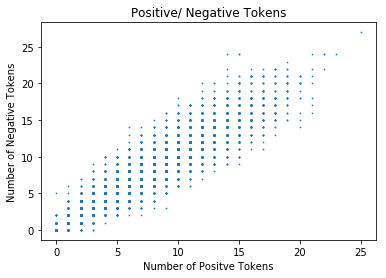

```python
# Just to see the correlation between positive/negative tokens in a tweet.

plt.scatter(tweet_weather_df['pos_count_no_stop'], tweet_weather_df['neg_count_no_stop'], s = .5)
plt.xlabel('Number of Positve Tokens')
plt.ylabel('Number of Negative Tokens')
plt.title('Positive/ Negative Tokens')

plt.show()
```

```python
# Looking at what had the highestly positive proportion.
tweet_weather_df.sort('pos_count_prop', ascending=False)
```

|  | user | STATE | tweet | timestamp | weather_type | text_lc | text_token | text_token_no_stop | tokens_pos | pos_count | tokens_neg | neg_count | tokens_pos_no_stop | pos_count_no_stop | tokens_neg_no_stop | neg_count_no_stop | pos_count_prop | neg_count_prop | pos_count_prop_no_stop | neg_count_prop_no_stop |
| --- | --- | --- | --- | --- | --- | --- | --- | --- | --- | --- | --- | --- | --- | --- | --- | --- | --- | --- | --- | --- |
| 537 | 15683449 | illinois | im spose to be on my way to class but I think ... | 2009-09-15 15:09:00 | None | im spose to be on my way to class but i think ... | [im, spose, to, be, on, my, way, to, class, bu... | [im, spose, way, class, think, imma, take, day... | [im, to, be, on, my, way, to, class, but, i, i... | 25 | [im, to, be, on, my, way, to, class, but, i, t... | 27 | [im, way, class, imma, take, go, sit, beautifu... | 25 | [im, way, class, think, imma, take, day, go, s... | 27 | 0.833333 | 0.900000 | 1.785714 | 1.928571 |
| 3327 | 51972994 | texas | Loving the weather right now | 2009-09-23 08:42:47 | Drought | loving the weather right now | [loving, the, weather, right, now] | [loving, weather, right] | [loving, the, right, now] | 4 | [the, right, now] | 3 | [loving, right] | 4 | [right] | 3 | 0.800000 | 0.600000 | 1.333333 | 1.000000 |
| 1338 | 18156889 | ohio | The weather is not looking too good up here. | 2009-11-24 08:04:38 | None | the weather is not looking too good up here. | [the, weather, is, not, looking, too, good, up... | [weather, looking, good, .] | [the, is, not, looking, too, good, up, here] | 8 | [the, is, not, too, up, here] | 6 | [looking, good] | 8 | [] | 6 | 0.800000 | 0.600000 | 2.000000 | 1.500000 |
| 1000 | 47519990 | new york | Great weather here in LA | 2009-09-20 13:09:00 | None | great weather here in la | [great, weather, here, in, la] | [great, weather, la] | [great, here, in, la] | 4 | [here, in, la] | 3 | [great, la] | 4 | [la] | 3 | 0.800000 | 0.600000 | 1.333333 | 1.000000 |
| 8464 | 13607372 | ohio | spent his best Fall break in splendid CA weath... | 2009-10-14 10:38:22 | None | spent his best fall break in splendid ca weath... | [spent, his, best, fall, break, in, splendid, ... | [spent, best, fall, break, splendid, ca, weath... | [his, best, fall, break, in, splendid, ca] | 7 | [his, best, fall, break, in, ca] | 6 | [best, fall, break, splendid, ca] | 7 | [best, fall, break, ca] | 6 | 0.777778 | 0.666667 | 1.000000 | 0.857143 |
| 4520 | 33661586 | tennessee | going run for a while in this beautiful weather | 2009-04-22 14:24:38 | None | going run for a while in this beautiful weather | [going, run, for, a, while, in, this, beautifu... | [going, run, beautiful, weather] | [going, run, for, a, while, in, beautiful] | 7 | [run, for, a, in] | 4 | [going, run, beautiful] | 7 | [run] | 4 | 0.777778 | 0.444444 | 1.750000 | 1.000000 |
| 4061 | 756278 | washington | I wonder if smiles can affect the weather? | 2009-09-21 07:09:00 | None | i wonder if smiles can affect the weather? | [i, wonder, if, smiles, can, affect, the, weat... | [wonder, smiles, affect, weather, ?] | [i, wonder, if, smiles, can, affect, the] | 7 | [i, if, can, affect, the] | 5 | [wonder, smiles, affect] | 7 | [affect] | 5 | 0.777778 | 0.555556 | 1.400000 | 1.000000 |
| 7253 | 35365733 | pennsylvania | now i think that its time to go and enjoy the ... | 2009-11-01 15:13:31 | None | now i think that its time to go and enjoy the ... | [now, i, think, that, its, time, to, go, and, ... | [think, time, go, enjoy, amazing, weather] | [now, i, its, time, to, go, and, enjoy, the, a... | 10 | [now, i, think, its, time, to, go, and, the] | 9 | [time, go, enjoy, amazing] | 10 | [think, time, go] | 9 | 0.769231 | 0.692308 | 1.666667 | 1.500000 |
| 646 | 25426879 | new york | Just landed in LA...happy to be safe on the gr... | 2009-11-19 13:57:04 | None | just landed in la...happy to be safe on the gr... | [just, landed, in, la, ..., happy, to, be, saf... | [landed, la, ..., happy, safe, ground, beautif... | [just, in, la, happy, to, be, safe, on, the, g... | 13 | [just, in, la, happy, to, be, safe, on, the, g... | 12 | [la, happy, safe, ground, beautiful] | 13 | [la, happy, safe, ground] | 12 | 0.764706 | 0.705882 | 1.444444 | 1.333333 |
| 924 | 23233229 | new york | is happy the weather decided to be nicer than ... | 2009-05-02 14:19:36 | None | is happy the weather decided to be nicer than ... | [is, happy, the, weather, decided, to, be, nic... | [happy, weather, decided, nicer, weather-man, ... | [is, happy, the, to, be, nicer, than, the, exp... | 16 | [is, happy, the, decided, to, be, than, the, e... | 15 | [happy, nicer, expected, time, go, enjoy] | 16 | [happy, decided, expected, time, go] | 15 | 0.761905 | 0.714286 | 1.454545 | 1.363636 |
| 4278 | 38378745 | delaware | About to go swimming at table rock state park ... | 2009-06-06 10:06:43 | None | about to go swimming at table rock state park ... | [about, to, go, swimming, at, table, rock, sta... | [go, swimming, table, rock, state, park, thank... | [to, go, at, table, rock, state, park, thank, ... | 16 | [to, go, at, table, rock, state, thank, god, f... | 15 | [go, table, rock, state, park, thank, god, war... | 16 | [go, table, rock, state, thank, god, warm, non... | 15 | 0.761905 | 0.714286 | 1.230769 | 1.153846 |
| 3970 | 26719552 | washington | loving the nice weather | 2009-09-11 16:58:13 | None | loving the nice weather | [loving, the, nice, weather] | [loving, nice, weather] | [loving, the, nice] | 3 | [the] | 1 | [loving, nice] | 3 | [] | 1 | 0.750000 | 0.250000 | 1.000000 | 0.333333 |
| 6181 | 73101298 | virginia | cool weather=good long run | 2009-09-21 17:11:48 | None | cool weather=good long run | [cool, weather=good, long, run] | [cool, weather=good, long, run] | [cool, long, run] | 3 | [long, run] | 2 | [cool, long, run] | 3 | [long, run] | 2 | 0.750000 | 0.500000 | 0.750000 | 0.500000 |
| 2029 | 24751333 | louisiana | I am thoroughly enjoying my fall break so far ... | 2009-10-01 11:41:59 | None | i am thoroughly enjoying my fall break so far ... | [i, am, thoroughly, enjoying, my, fall, break,... | [thoroughly, enjoying, fall, break, far, wish,... | [i, am, enjoying, my, fall, break, so, far, i,... | 12 | [i, am, my, fall, break, so, far, i, just, the... | 11 | [enjoying, fall, break, far, wish] | 12 | [fall, break, far] | 11 | 0.750000 | 0.687500 | 1.500000 | 1.375000 |
| 5600 | 23611105 | texas | Hard to get up early in this weather | 2009-09-24 08:20:45 | Drought | hard to get up early in this weather | [hard, to, get, up, early, in, this, weather] | [hard, get, early, weather] | [hard, to, get, up, early, in] | 6 | [hard, to, get, up, in] | 5 | [hard, get, early] | 6 | [hard, get] | 5 | 0.750000 | 0.625000 | 1.500000 | 1.250000 |
| 5409 | 24307224 | pennsylvania | Oh well so much for the pee pee man..lol welco... | 2009-09-20 01:03:28 | None | oh well so much for the pee pee man..lol welco... | [oh, well, so, much, for, the, pee, pee, man..... | [oh, well, much, pee, pee, man..lol, welcome, ... | [oh, well, so, for, the, pee, pee, welcome, back] | 9 | [oh, well, so, for, the, pee, pee, welcome, back] | 9 | [oh, well, pee, pee, welcome, back] | 9 | [oh, well, pee, pee, welcome, back] | 9 | 0.750000 | 0.750000 | 1.000000 | 1.000000 |
| 4829 | 47498216 | wisconsin | The weathers goi to be warm in milwaukee t is ... | 2009-11-05 21:27:57 | Drought | the weathers goi to be warm in milwaukee t is ... | [the, weathers, goi, to, be, warm, in, milwauk... | [weathers, goi, warm, milwaukee, weekend..so, ... | [the, goi, to, be, warm, in, t, is, happy] | 9 | [the, to, be, warm, in, t, is, happy] | 8 | [goi, warm, happy] | 9 | [warm, happy] | 8 | 0.750000 | 0.666667 | 1.500000 | 1.333333 |
| 674 | 41256703 | new york | the weather is so sexy, i just wanna fuck it | 2009-05-22 16:00:10 | None | the weather is so sexy, i just wanna fuck it | [the, weather, is, so, sexy, ,, i, just, wan, ... | [weather, sexy, ,, wan, na, fuck] | [the, is, so, sexy, i, just, wan, na, it] | 9 | [the, is, so, i, just, wan, na, fuck, it] | 9 | [sexy, wan, na] | 9 | [wan, na, fuck] | 9 | 0.750000 | 0.750000 | 1.500000 | 1.500000 |
| 8105 | 17874400 | alabama | @pjfinley boo for rain. Ready for the sun to c... | 2009-09-15 09:09:00 | None | @pjfinley boo for rain. ready for the sun to c... | [@, pjfinley, boo, for, rain, ., ready, for, t... | [@, pjfinley, boo, rain, ., ready, sun, come, ... | [boo, for, rain, ready, for, the, to, come, ou... | 18 | [boo, for, rain, for, the, sun, to, come, out,... | 18 | [boo, rain, ready, come, fall, blow, well] | 18 | [boo, rain, sun, come, fall, blow, well] | 18 | 0.750000 | 0.750000 | 1.384615 | 1.384615 |
| 1362 | 58783040 | ohio | i wanna go to heaven for the weather, and hell... | 2009-08-18 13:32:07 | None | i wanna go to heaven for the weather, and hell... | [i, wan, na, go, to, heaven, for, the, weather... | [wan, na, go, heaven, weather, ,, hell, company] | [i, wan, na, go, to, heaven, for, the, and, fo... | 11 | [i, wan, na, go, to, for, the, and, hell, for,... | 11 | [wan, na, go, heaven] | 11 | [wan, na, go, hell] | 11 | 0.733333 | 0.733333 | 1.375000 | 1.375000 |
| 8525 | 52613470 | colorado | I wish this weather would warm up not ready fo... | 2009-09-24 14:36:26 | Drought | i wish this weather would warm up not ready fo... | [i, wish, this, weather, would, warm, up, not,... | [wish, weather, would, warm, ready, winter] | [i, wish, warm, up, not, ready, for, the, to, ... | 11 | [i, warm, up, not, for, the, to, be, here] | 9 | [wish, warm, ready] | 11 | [warm] | 9 | 0.733333 | 0.600000 | 1.833333 | 1.500000 |
| 3697 | 41047312 | texas | wats good world i hate the weather is it gonna... | 2009-10-30 15:58:14 | Drought | wats good world i hate the weather is it gonna... | [wats, good, world, i, hate, the, weather, is,... | [wats, good, world, hate, weather, gon, na, ho... | [good, world, i, the, is, it, gon, na, be, hot... | 11 | [i, hate, the, is, it, gon, na, be, hot, or, c... | 11 | [good, world, gon, na, hot] | 11 | [hate, gon, na, hot, cold] | 11 | 0.733333 | 0.733333 | 1.222222 | 1.222222 |
| 5771 | 25016536 | minnesota | Not looking forward to catching the bus in thi... | 2009-10-15 16:03:36 | Drought | not looking forward to catching the bus in thi... | [not, looking, forward, to, catching, the, bus... | [looking, forward, catching, bus, weather, .] | [not, looking, forward, to, catching, the, bus... | 8 | [not, to, the, bus, in] | 5 | [looking, forward, catching, bus] | 8 | [bus] | 5 | 0.727273 | 0.454545 | 1.333333 | 0.833333 |
| 4519 | 33661586 | tennessee | getting ready to go for a run. Beautiful weath... | 2009-05-12 13:39:07 | None | getting ready to go for a run. beautiful weath... | [getting, ready, to, go, for, a, run, ., beaut... | [getting, ready, go, run, ., beautiful, weather] | [ready, to, go, for, a, run, beautiful, here] | 8 | [to, go, for, a, run, here] | 6 | [ready, go, run, beautiful] | 8 | [go, run] | 6 | 0.727273 | 0.545455 | 1.142857 | 0.857143 |
| 5623 | 25304008 | texas | is enjoying my sunday morning cant beat the we... | 2009-05-31 09:35:02 | Drought | is enjoying my sunday morning cant beat the we... | [is, enjoying, my, sunday, morning, cant, beat... | [enjoying, sunday, morning, cant, beat, weathe... | [is, enjoying, my, cant, beat, the, in, ep] | 8 | [is, my, cant, beat, the, in, ep] | 7 | [enjoying, cant, beat, ep] | 8 | [cant, beat, ep] | 7 | 0.727273 | 0.636364 | 1.142857 | 1.000000 |
| 5558 | 18575065 | pennsylvania | I wish I can enjoy the weather 2day instead of... | 2009-08-02 17:27:28 | Flood | i wish i can enjoy the weather 2day instead of... | [i, wish, i, can, enjoy, the, weather, 2day, i... | [wish, enjoy, weather, 2day, instead, working] | [i, wish, i, can, enjoy, the, of, working] | 8 | [i, i, can, the, of] | 5 | [wish, enjoy, working] | 8 | [] | 5 | 0.727273 | 0.454545 | 1.333333 | 0.833333 |
| 3779 | 897 | texas | Time for me to take my own advice and shut up ... | 2009-09-18 13:09:00 | Drought | time for me to take my own advice and shut up ... | [time, for, me, to, take, my, own, advice, and... | [time, take, advice, shut, app, store, ., posi... | [time, for, me, to, take, my, own, and, up, th... | 21 | [time, for, me, to, take, my, own, and, up, th... | 16 | [time, take, app, store, positive, note, nice,... | 21 | [time, take, app] | 16 | 0.724138 | 0.551724 | 1.400000 | 1.066667 |
| 1054 | 18441865 | new york | even as crazy as my life is now ... the weathe... | 2009-04-18 21:04:00 | None | even as crazy as my life is now ... the weathe... | [even, as, crazy, as, my, life, is, now, ..., ... | [even, crazy, life, ..., weather, today, made,... | [even, as, as, my, life, is, now, the, made, m... | 13 | [even, as, crazy, as, my, life, is, now, the, ... | 13 | [even, life, made, forget] | 13 | [even, crazy, life, forget] | 13 | 0.722222 | 0.722222 | 1.444444 | 1.444444 |
| 1408 | 61058172 | nevada | Beautiful weather here in Las Vegas today all ... | 2009-10-15 16:31:39 | None | beautiful weather here in las vegas today all ... | [beautiful, weather, here, in, las, vegas, tod... | [beautiful, weather, las, vegas, today, window... | [beautiful, here, in, las, all, the, are, open... | 13 | [here, in, las, all, the, are, and, the, is] | 9 | [beautiful, las, open, breeze] | 13 | [las] | 9 | 0.722222 | 0.500000 | 1.444444 | 1.000000 |
| 1960 | 43697962 | texas | I have to be on a plane early in the morning. ... | 2009-09-21 00:03:47 | Drought | i have to be on a plane early in the morning. ... | [i, have, to, be, on, a, plane, early, in, the... | [plane, early, morning, ., know, going, delaye... | [i, have, to, be, on, a, early, in, the, i, kn... | 18 | [i, have, to, be, on, a, in, the, i, know, it,... | 18 | [early, know, going] | 18 | [know, delayed, due] | 18 | 0.720000 | 0.720000 | 1.800000 | 1.800000 |
| ... | ... | ... | ... | ... | ... | ... | ... | ... | ... | ... | ... | ... | ... | ... | ... | ... | ... | ... | ... | ... |
| 2330 | 17137526 | rhode island | @MistahFAB stop running mayweather | 2009-09-19 23:09:00 | None | @mistahfab stop running mayweather | [@, mistahfab, stop, running, mayweather] | [@, mistahfab, stop, running, mayweather] | [] | 0 | [] | 0 | [] | 0 | [] | 0 | 0.000000 | 0.000000 | 0.000000 | 0.000000 |
| 197 | 15510644 | california | #User-generated #SMS weather updates launched ... | 2009-09-17 13:23:52 | Drought | #user-generated #sms weather updates launched ... | [#, user-generated, #, sms, weather, updates, ... | [#, user-generated, #, sms, weather, updates, ... | [] | 0 | [sms] | 1 | [] | 0 | [sms] | 1 | 0.000000 | 0.090909 | 0.000000 | 0.090909 |
| 5726 | 21060634 | new jersey | @Ohhaymaggie nope lost. Fucking weather was an... | 2009-09-11 20:09:00 | High Surf | @ohhaymaggie nope lost. fucking weather was an... | [@, ohhaymaggie, nope, lost, ., fucking, weath... | [@, ohhaymaggie, nope, lost, ., fucking, weath... | [] | 0 | [nope, lost, fucking, was, annoying] | 5 | [] | 0 | [nope, lost, fucking, annoying] | 5 | 0.000000 | 0.500000 | 0.000000 | 0.555556 |
| 8809 | 27990323 | california | fuck this weather!!! | 2009-09-01 14:09:00 | Wildfire | fuck this weather!!! | [fuck, this, weather, !, !, !] | [fuck, weather, !, !, !] | [] | 0 | [fuck] | 1 | [] | 0 | [fuck] | 1 | 0.000000 | 0.166667 | 0.000000 | 0.200000 |
| 8701 | 24481210 | wisconsin | couldnt skate today...fucking Massachusetts we... | 2009-10-27 19:25:22 | Drought | couldnt skate today...fucking massachusetts we... | [couldnt, skate, today, ..., fucking, massachu... | [couldnt, skate, today, ..., fucking, massachu... | [] | 0 | [fucking] | 1 | [] | 0 | [fucking] | 1 | 0.000000 | 0.142857 | 0.000000 | 0.142857 |
| 8059 | 9228532 | utah | http://weather.hamweather.com/rivers/gauge/ACY... | 2009-09-22 12:11:45 | Drought | http://weather.hamweather.com/rivers/gauge/acy... | [http, :, //weather.hamweather.com/rivers/gaug... | [http, :, //weather.hamweather.com/rivers/gaug... | [] | 0 | [] | 0 | [] | 0 | [] | 0 | 0.000000 | 0.000000 | 0.000000 | 0.000000 |
| 7827 | 37779885 | texas | @Jeremih mayweather ithink | 2009-09-20 01:09:00 | Drought | @jeremih mayweather ithink | [@, jeremih, mayweather, ithink] | [@, jeremih, mayweather, ithink] | [] | 0 | [] | 0 | [] | 0 | [] | 0 | 0.000000 | 0.000000 | 0.000000 | 0.000000 |
| 7828 | 37779885 | texas | @Jeremih mayweather | 2009-09-20 01:09:00 | Drought | @jeremih mayweather | [@, jeremih, mayweather] | [@, jeremih, mayweather] | [] | 0 | [] | 0 | [] | 0 | [] | 0 | 0.000000 | 0.000000 | 0.000000 | 0.000000 |
| 3584 | 80936702 | ohio | fuck this weather. | 2009-11-12 13:07:20 | None | fuck this weather. | [fuck, this, weather, .] | [fuck, weather, .] | [] | 0 | [fuck] | 1 | [] | 0 | [fuck] | 1 | 0.000000 | 0.250000 | 0.000000 | 0.333333 |
| 6164 | 27815847 | connecticut | Longhorns Mayweather UFC 103 | 2009-09-19 19:09:00 | None | longhorns mayweather ufc 103 | [longhorns, mayweather, ufc, 103] | [longhorns, mayweather, ufc, 103] | [] | 0 | [] | 0 | [] | 0 | [] | 0 | 0.000000 | 0.000000 | 0.000000 | 0.000000 |
| 7290 | 18678410 | virginia | Ugly weather. | 2009-11-19 08:28:40 | None | ugly weather. | [ugly, weather, .] | [ugly, weather, .] | [] | 0 | [ugly] | 1 | [] | 0 | [ugly] | 1 | 0.000000 | 0.333333 | 0.000000 | 0.333333 |
| 3163 | 16751105 | california | Namedrop: @goldsmi @cweatherup @menlow @marcel... | 2009-09-19 05:09:00 | Drought | namedrop: @goldsmi @cweatherup @menlow @marcel... | [namedrop, :, @, goldsmi, @, cweatherup, @, me... | [namedrop, :, @, goldsmi, @, cweatherup, @, me... | [] | 0 | [usc] | 1 | [] | 0 | [usc] | 1 | 0.000000 | 0.038462 | 0.000000 | 0.038462 |
| 6768 | 18259266 | pennsylvania | @Naimthestar Mayweather by knockout | 2009-09-19 11:09:00 | None | @naimthestar mayweather by knockout | [@, naimthestar, mayweather, by, knockout] | [@, naimthestar, mayweather, knockout] | [] | 0 | [by] | 1 | [] | 0 | [] | 1 | 0.000000 | 0.200000 | 0.000000 | 0.250000 |
| 795 | 15415604 | new york | obama meteorology: http://obama-weather.com/Ob... | 2009-11-09 21:34:11 | None | obama meteorology: http://obama-weather.com/ob... | [obama, meteorology, :, http, :, //obama-weath... | [obama, meteorology, :, http, :, //obama-weath... | [] | 0 | [] | 0 | [] | 0 | [] | 0 | 0.000000 | 0.000000 | 0.000000 | 0.000000 |
| 4154 | 24879804 | florida | Thanksgiving travel weather http://bit.ly/5vhow4 | 2009-11-23 00:56:02 | None | thanksgiving travel weather http://bit.ly/5vhow4 | [thanksgiving, travel, weather, http, :, //bit... | [thanksgiving, travel, weather, http, :, //bit... | [] | 0 | [] | 0 | [] | 0 | [] | 0 | 0.000000 | 0.000000 | 0.000000 | 0.000000 |
| 1420 | 23838895 | nevada | @moneymayweather Congrats money mayweather. | 2009-09-20 03:25:13 | None | @moneymayweather congrats money mayweather. | [@, moneymayweather, congrats, money, mayweath... | [@, moneymayweather, congrats, money, mayweath... | [] | 0 | [] | 0 | [] | 0 | [] | 0 | 0.000000 | 0.000000 | 0.000000 | 0.000000 |
| 2313 | 23135345 | rhode island | Cuddle weather | 2009-10-12 11:34:54 | None | cuddle weather | [cuddle, weather] | [cuddle, weather] | [] | 0 | [] | 0 | [] | 0 | [] | 0 | 0.000000 | 0.000000 | 0.000000 | 0.000000 |
| 5137 | 35828166 | maine | Manny Pacquiao versus Mayweather Next http://b... | 2009-09-19 16:09:00 | None | manny pacquiao versus mayweather next http://b... | [manny, pacquiao, versus, mayweather, next, ht... | [manny, pacquiao, versus, mayweather, next, ht... | [] | 0 | [next] | 1 | [] | 0 | [next] | 1 | 0.000000 | 0.125000 | 0.000000 | 0.125000 |
| 3095 | 53121393 | california | Rumor: Mayweather considering UK fight http://... | 2009-11-30 12:10:03 | Drought | rumor: mayweather considering uk fight http://... | [rumor, :, mayweather, considering, uk, fight,... | [rumor, :, mayweather, considering, uk, fight,... | [] | 0 | [rumor, uk] | 2 | [] | 0 | [rumor, uk] | 2 | 0.000000 | 0.222222 | 0.000000 | 0.222222 |
| 2045 | 12685112 | louisiana | hazelweatherfield: Douglas Hannant Spring 2010... | 2009-09-22 11:09:00 | None | hazelweatherfield: douglas hannant spring 2010... | [hazelweatherfield, :, douglas, hannant, sprin... | [hazelweatherfield, :, douglas, hannant, sprin... | [] | 0 | [] | 0 | [] | 0 | [] | 0 | 0.000000 | 0.000000 | 0.000000 | 0.000000 |
| 5760 | 8769802 | minnesota | http://obama-weather.com | 2009-11-03 15:15:01 | None | http://obama-weather.com | [http, :, //obama-weather.com] | [http, :, //obama-weather.com] | [] | 0 | [] | 0 | [] | 0 | [] | 0 | 0.000000 | 0.000000 | 0.000000 | 0.000000 |
| 6572 | 42824284 | washington | Mayweather vs Marquez tonight! | 2009-09-19 15:52:56 | Wildfire | mayweather vs marquez tonight! | [mayweather, vs, marquez, tonight, !] | [mayweather, vs, marquez, tonight, !] | [] | 0 | [] | 0 | [] | 0 | [] | 0 | 0.000000 | 0.000000 | 0.000000 | 0.000000 |
| 8042 | 57167132 | texas | Updated: Watch: Floyd Mayweather Vs Manuel Mar... | 2009-09-20 23:09:00 | Drought | updated: watch: floyd mayweather vs manuel mar... | [updated, :, watch, :, floyd, mayweather, vs, ... | [updated, :, watch, :, floyd, mayweather, vs, ... | [] | 0 | [watch] | 1 | [] | 0 | [watch] | 1 | 0.000000 | 0.076923 | 0.000000 | 0.076923 |
| 7257 | 34020618 | washington | Auburn, Puyallup offer weather spotter trainin... | 2009-09-23 12:02:07 | None | auburn, puyallup offer weather spotter trainin... | [auburn, ,, puyallup, offer, weather, spotter,... | [auburn, ,, puyallup, offer, weather, spotter,... | [] | 0 | [training] | 1 | [] | 0 | [training] | 1 | 0.000000 | 0.090909 | 0.000000 | 0.090909 |
| 460 | 68573623 | illinois | @ZillaBoyMgee Floyd "Needs Money" Mayweather | 2009-09-19 23:09:00 | None | @zillaboymgee floyd "needs money" mayweather | [@, zillaboymgee, floyd, ``, needs, money, '',... | [@, zillaboymgee, floyd, ``, needs, money, '',... | [] | 0 | [] | 0 | [] | 0 | [] | 0 | 0.000000 | 0.000000 | 0.000000 | 0.000000 |
| 7057 | 55243960 | montana | Huge hit from Merriweather | 2009-09-14 20:09:00 | None | huge hit from merriweather | [huge, hit, from, merriweather] | [huge, hit, merriweather] | [] | 0 | [hit] | 1 | [] | 0 | [hit] | 1 | 0.000000 | 0.250000 | 0.000000 | 0.333333 |
| 1247 | 17076365 | texas | Mayweather Marquez fight today! | 2009-09-19 19:09:00 | Drought | mayweather marquez fight today! | [mayweather, marquez, fight, today, !] | [mayweather, marquez, fight, today, !] | [] | 0 | [] | 0 | [] | 0 | [] | 0 | 0.000000 | 0.000000 | 0.000000 | 0.000000 |
| 5025 | 25024595 | pennsylvania | Yes pacquiao/ mayweather!!!! | 2009-11-14 23:42:00 | None | yes pacquiao/ mayweather!!!! | [yes, pacquiao/, mayweather, !, !, !, !] | [yes, pacquiao/, mayweather, !, !, !, !] | [] | 0 | [yes] | 1 | [] | 0 | [yes] | 1 | 0.000000 | 0.142857 | 0.000000 | 0.142857 |
| 3034 | 61317171 | california | Money Money Mayweather! | 2009-09-19 13:09:00 | Drought | money money mayweather! | [money, money, mayweather, !] | [money, money, mayweather, !] | [] | 0 | [] | 0 | [] | 0 | [] | 0 | 0.000000 | 0.000000 | 0.000000 | 0.000000 |
| 7515 | 17999171 | illinois | @BookWorm71 Bad! Bad weatherman! | 2009-09-22 17:42:04 | None | @bookworm71 bad! bad weatherman! | [@, bookworm71, bad, !, bad, weatherman, !] | [@, bookworm71, bad, !, bad, weatherman, !] | [] | 0 | [bad, bad] | 2 | [] | 0 | [bad, bad] | 2 | 0.000000 | 0.285714 | 0.000000 | 0.285714 |

8962 rows × 20 columns

```python
# Looking at what had the highest negative proportion.
tweet_weather_df.sort('neg_count_prop', ascending=False)
```

|  | user | STATE | tweet | timestamp | weather_type | text_lc | text_token | text_token_no_stop | tokens_pos | pos_count | tokens_neg | neg_count | tokens_pos_no_stop | pos_count_no_stop | tokens_neg_no_stop | neg_count_no_stop | pos_count_prop | neg_count_prop | pos_count_prop_no_stop | neg_count_prop_no_stop |
| --- | --- | --- | --- | --- | --- | --- | --- | --- | --- | --- | --- | --- | --- | --- | --- | --- | --- | --- | --- | --- |
| 537 | 15683449 | illinois | im spose to be on my way to class but I think ... | 2009-09-15 15:09:00 | None | im spose to be on my way to class but i think ... | [im, spose, to, be, on, my, way, to, class, bu... | [im, spose, way, class, think, imma, take, day... | [im, to, be, on, my, way, to, class, but, i, i... | 25 | [im, to, be, on, my, way, to, class, but, i, t... | 27 | [im, way, class, imma, take, go, sit, beautifu... | 25 | [im, way, class, think, imma, take, day, go, s... | 27 | 0.833333 | 0.900000 | 1.785714 | 1.928571 |
| 3564 | 19419897 | montana | ps im back... still feeling a little under the... | 2009-11-02 20:55:25 | None | ps im back... still feeling a little under the... | [ps, im, back, ..., still, feeling, a, little,... | [ps, im, back, ..., still, feeling, little, we... | [ps, im, back, a, under, the, but, in, the, ri... | 15 | [ps, im, back, still, feeling, a, little, unde... | 24 | [ps, im, back, right, full, head] | 15 | [ps, im, back, still, feeling, little, headed,... | 24 | 0.555556 | 0.888889 | 0.882353 | 1.411765 |
| 6283 | 66781233 | washington | Tired going to go to bed think I am still unde... | 2009-09-20 00:09:00 | Wildfire | tired going to go to bed think i am still unde... | [tired, going, to, go, to, bed, think, i, am, ... | [tired, going, go, bed, think, still, weather] | [going, to, go, to, i, am, under, the] | 8 | [tired, to, go, to, bed, think, i, am, still, ... | 11 | [going, go] | 8 | [tired, go, bed, think, still] | 11 | 0.615385 | 0.846154 | 1.142857 | 1.571429 |
| 5022 | 19741270 | pennsylvania | Event is over due to weather | 2009-11-14 22:13:22 | None | event is over due to weather | [event, is, over, due, to, weather] | [event, due, weather] | [event, is, over, to] | 4 | [event, is, over, due, to] | 5 | [event] | 4 | [event, due] | 5 | 0.666667 | 0.833333 | 1.333333 | 1.666667 |
| 6366 | 15738047 | texas | I just want some rainless fall weather and to ... | 2009-09-19 11:09:00 | Drought | i just want some rainless fall weather and to ... | [i, just, want, some, rainless, fall, weather,... | [want, rainless, fall, weather, spend, day, re... | [i, just, some, fall, and, to, the, to, the] | 9 | [i, just, want, some, rainless, fall, and, to,... | 14 | [fall] | 9 | [want, rainless, fall, spend, day, next] | 14 | 0.529412 | 0.823529 | 1.000000 | 1.555556 |
| 3797 | 21278837 | texas | feeling a wee bit under the weather. I hope I... | 2009-09-11 15:09:00 | Drought | feeling a wee bit under the weather. i hope i... | [feeling, a, wee, bit, under, the, weather, .,... | [feeling, wee, bit, weather, ., hope, feel, ok... | [a, wee, bit, under, the, i, hope, i, ok, time] | 10 | [feeling, a, wee, bit, under, the, i, hope, i,... | 14 | [wee, bit, hope, ok, time] | 10 | [feeling, wee, bit, hope, feel, ok, show, time] | 14 | 0.588235 | 0.823529 | 0.909091 | 1.272727 |
| 8135 | 39596916 | oklahoma | All this dreary weather has put me in a funky ... | 2009-09-13 19:09:00 | Flood | all this dreary weather has put me in a funky ... | [all, this, dreary, weather, has, put, me, in,... | [dreary, weather, put, funky, mood] | [all, has, put, me, in, a] | 6 | [all, dreary, has, put, me, in, a, funky, mood] | 9 | [put] | 6 | [dreary, put, funky, mood] | 9 | 0.545455 | 0.818182 | 1.200000 | 1.800000 |
| 4539 | 43453299 | texas | I hope it rains im tired of this hot weather | 2009-06-09 15:11:55 | Drought | i hope it rains im tired of this hot weather | [i, hope, it, rains, im, tired, of, this, hot,... | [hope, rains, im, tired, hot, weather] | [i, hope, it, im, of, hot] | 6 | [i, hope, it, rains, im, tired, of, hot] | 8 | [hope, im, hot] | 6 | [hope, rains, im, tired, hot] | 8 | 0.600000 | 0.800000 | 1.000000 | 1.333333 |
| 4049 | 18473306 | washington | feeling more than just a little bit under the ... | 2009-09-24 15:29:54 | None | feeling more than just a little bit under the ... | [feeling, more, than, just, a, little, bit, un... | [feeling, little, bit, weather] | [than, just, a, bit, under, the] | 6 | [feeling, than, just, a, little, bit, under, the] | 8 | [bit] | 6 | [feeling, little, bit] | 8 | 0.600000 | 0.800000 | 1.500000 | 2.000000 |
| 8439 | 91379422 | oklahoma | Scary wind and weird weather | 2009-11-28 22:19:50 | None | scary wind and weird weather | [scary, wind, and, weird, weather] | [scary, wind, weird, weather] | [wind, and] | 2 | [scary, wind, and, weird] | 4 | [wind] | 2 | [scary, wind, weird] | 4 | 0.400000 | 0.800000 | 0.500000 | 1.000000 |
| 8521 | 26094339 | colorado | gonna put my lil son to bed then relaxing for ... | 2009-10-28 22:26:55 | Drought | gonna put my lil son to bed then relaxing for ... | [gon, na, put, my, lil, son, to, bed, then, re... | [gon, na, put, lil, son, bed, relaxing, lil, h... | [gon, na, put, my, son, to, then, for, a, i, h... | 15 | [gon, na, put, my, lil, son, to, bed, then, fo... | 19 | [gon, na, put, son, head, best] | 15 | [gon, na, put, lil, son, bed, lil, head, bed, ... | 19 | 0.625000 | 0.791667 | 1.071429 | 1.357143 |
| 5226 | 7268972 | vermont | weather tried to lull me into a false sense of... | 2009-11-23 06:16:12 | None | weather tried to lull me into a false sense of... | [weather, tried, to, lull, me, into, a, false,... | [weather, tried, lull, false, sense, security,... | [to, me, a, of, and, head, out, for, and, then... | 13 | [to, lull, me, into, a, false, sense, of, secu... | 18 | [head, back] | 13 | [lull, false, sense, security, head, back, evil] | 18 | 0.565217 | 0.782609 | 1.181818 | 1.636364 |
| 1267 | 34116511 | texas | i just want to go get back in my bed... this w... | 2009-09-22 14:04:26 | Drought | i just want to go get back in my bed... this w... | [i, just, want, to, go, get, back, in, my, bed... | [want, go, get, back, bed, ..., weather, got, ... | [i, just, to, go, get, back, in, my, me] | 9 | [i, just, want, to, go, get, back, in, my, bed... | 14 | [go, get, back] | 9 | [want, go, get, back, bed, got, feeling, drained] | 14 | 0.500000 | 0.777778 | 0.818182 | 1.272727 |
| 8544 | 25751283 | tennessee | the weather is PERFECT outside its so chilly g... | 2009-11-26 18:02:58 | None | the weather is perfect outside its so chilly g... | [the, weather, is, perfect, outside, its, so, ... | [weather, perfect, outside, chilly, god, pleas... | [the, is, perfect, its, so, god, please, it, l... | 13 | [the, is, perfect, outside, its, so, chilly, g... | 17 | [perfect, god, please, like] | 13 | [perfect, outside, chilly, god, please, let, l... | 17 | 0.590909 | 0.772727 | 1.083333 | 1.416667 |
| 1352 | 44850911 | ohio | I want to go on a hot vacation from the gross ... | 2009-10-16 12:12:11 | None | i want to go on a hot vacation from the gross ... | [i, want, to, go, on, a, hot, vacation, from, ... | [want, go, hot, vacation, gross, cold, weather] | [i, to, go, on, a, hot, the, gross] | 8 | [i, want, to, go, on, a, hot, the, gross, cold] | 10 | [go, hot, gross] | 8 | [want, go, hot, gross, cold] | 10 | 0.615385 | 0.769231 | 1.142857 | 1.428571 |
| 1731 | 39219174 | texas | Man i hate how the weather in ATL goes from xt... | 2009-11-17 20:25:41 | Drought | man i hate how the weather in atl goes from xt... | [man, i, hate, how, the, weather, in, atl, goe... | [man, hate, weather, atl, goes, xtra, hot, rai... | [man, i, the, in, atl, xtra, hot, to, rainy, i... | 11 | [man, i, hate, how, the, in, xtra, hot, to, ra... | 13 | [man, atl, xtra, hot, rainy, one] | 11 | [man, hate, xtra, hot, rainy, one, day] | 13 | 0.647059 | 0.764706 | 1.100000 | 1.300000 |
| 2911 | 26107947 | california | I have a scratchy throat now because fucking L... | 2009-11-04 17:15:51 | Drought | i have a scratchy throat now because fucking l... | [i, have, a, scratchy, throat, now, because, f... | [scratchy, throat, fucking, la, weather, ca, n... | [i, have, a, now, la, ca, up, its, mind] | 9 | [i, have, a, scratchy, throat, now, fucking, l... | 13 | [la, ca, mind] | 9 | [scratchy, throat, fucking, la, ca, make, mind] | 13 | 0.529412 | 0.764706 | 0.900000 | 1.300000 |
| 8105 | 17874400 | alabama | @pjfinley boo for rain. Ready for the sun to c... | 2009-09-15 09:09:00 | None | @pjfinley boo for rain. ready for the sun to c... | [@, pjfinley, boo, for, rain, ., ready, for, t... | [@, pjfinley, boo, rain, ., ready, sun, come, ... | [boo, for, rain, ready, for, the, to, come, ou... | 18 | [boo, for, rain, for, the, sun, to, come, out,... | 18 | [boo, rain, ready, come, fall, blow, well] | 18 | [boo, rain, sun, come, fall, blow, well] | 18 | 0.750000 | 0.750000 | 1.384615 | 1.384615 |
| 7513 | 18968559 | california | weather is dope in sf rit now. | 2009-09-26 18:35:45 | Drought | weather is dope in sf rit now. | [weather, is, dope, in, sf, rit, now, .] | [weather, dope, sf, rit, .] | [is, in, sf, rit, now] | 5 | [is, dope, in, sf, rit, now] | 6 | [sf, rit] | 5 | [dope, sf, rit] | 6 | 0.625000 | 0.750000 | 1.000000 | 1.200000 |
| 1140 | 39678237 | texas | Still under the weather | 2009-05-20 12:38:49 | Drought | still under the weather | [still, under, the, weather] | [still, weather] | [under, the] | 2 | [still, under, the] | 3 | [] | 2 | [still] | 3 | 0.500000 | 0.750000 | 1.000000 | 1.500000 |
| 2733 | 16151999 | california | We just found out the show tonight with Ghostl... | 2009-10-16 14:24:21 | Drought | we just found out the show tonight with ghostl... | [we, just, found, out, the, show, tonight, wit... | [found, show, tonight, ghostland, cancelled, d... | [we, just, found, out, the, is, to, we, will, ... | 15 | [we, just, found, out, the, show, is, due, to,... | 21 | [found, know] | 15 | [found, show, due, bad, know, make, show] | 21 | 0.535714 | 0.750000 | 1.153846 | 1.615385 |
| 2423 | 37050723 | virginia | Its funny the weather matches the temperature ... | 2009-09-30 22:13:50 | None | its funny the weather matches the temperature ... | [its, funny, the, weather, matches, the, tempe... | [funny, weather, matches, temperature, heart, ... | [its, the, the, of, my, heart, right, now] | 8 | [its, funny, the, the, of, my, heart, right, now] | 9 | [heart, right] | 8 | [funny, heart, right] | 9 | 0.666667 | 0.750000 | 1.333333 | 1.500000 |
| 981 | 18062453 | new york | The weather is messy gonna order in watch movi... | 2009-11-25 17:19:21 | None | the weather is messy gonna order in watch movi... | [the, weather, is, messy, gon, na, order, in, ... | [weather, messy, gon, na, order, watch, movies... | [the, is, gon, na, order, in, and, and, get, o... | 10 | [the, is, messy, gon, na, order, in, watch, an... | 15 | [gon, na, order, get] | 10 | [messy, gon, na, order, watch, chill, try, get... | 15 | 0.500000 | 0.750000 | 0.769231 | 1.153846 |
| 1261 | 62122108 | texas | money mayweather is back in effect yes sir | 2009-09-19 23:09:00 | Drought | money mayweather is back in effect yes sir | [money, mayweather, is, back, in, effect, yes,... | [money, mayweather, back, effect, yes, sir] | [is, back, in, effect, sir] | 5 | [is, back, in, effect, yes, sir] | 6 | [back, effect, sir] | 5 | [back, effect, yes, sir] | 6 | 0.625000 | 0.750000 | 0.833333 | 1.000000 |
| 5041 | 49574725 | pennsylvania | is feeling a little under the weather instead ... | 2009-08-30 00:31:59 | None | is feeling a little under the weather instead ... | [is, feeling, a, little, under, the, weather, ... | [feeling, little, weather, instead, weather] | [is, a, under, the, of, over, the] | 7 | [is, feeling, a, little, under, the, of, over,... | 9 | [] | 7 | [feeling, little] | 9 | 0.583333 | 0.750000 | 1.400000 | 1.800000 |
| 8564 | 84095775 | texas | Mother under the weather. May have to take her... | 2009-11-18 11:51:37 | Drought | mother under the weather. may have to take her... | [mother, under, the, weather, ., may, have, to... | [mother, weather, ., may, take, hospital, ., h... | [under, the, have, to, take, her, to, the, she... | 12 | [mother, under, the, may, have, to, take, her,... | 15 | [take, hard] | 12 | [mother, may, take, hospital, hard, headed] | 15 | 0.600000 | 0.750000 | 1.200000 | 1.500000 |
| 674 | 41256703 | new york | the weather is so sexy, i just wanna fuck it | 2009-05-22 16:00:10 | None | the weather is so sexy, i just wanna fuck it | [the, weather, is, so, sexy, ,, i, just, wan, ... | [weather, sexy, ,, wan, na, fuck] | [the, is, so, sexy, i, just, wan, na, it] | 9 | [the, is, so, i, just, wan, na, fuck, it] | 9 | [sexy, wan, na] | 9 | [wan, na, fuck] | 9 | 0.750000 | 0.750000 | 1.500000 | 1.500000 |
| 6329 | 41442947 | texas | Feeling a bit under the weather right now, thi... | 2009-11-02 18:00:23 | Drought | feeling a bit under the weather right now, thi... | [feeling, a, bit, under, the, weather, right, ... | [feeling, bit, weather, right, ,, think, god, ... | [a, bit, under, the, right, now, god, is, gent... | 23 | [feeling, a, bit, under, the, right, now, thin... | 24 | [bit, right, god, gently, tell, bit, going, lie] | 23 | [feeling, bit, right, think, god, gently, tell... | 24 | 0.718750 | 0.750000 | 1.437500 | 1.500000 |
| 5409 | 24307224 | pennsylvania | Oh well so much for the pee pee man..lol welco... | 2009-09-20 01:03:28 | None | oh well so much for the pee pee man..lol welco... | [oh, well, so, much, for, the, pee, pee, man..... | [oh, well, much, pee, pee, man..lol, welcome, ... | [oh, well, so, for, the, pee, pee, welcome, back] | 9 | [oh, well, so, for, the, pee, pee, welcome, back] | 9 | [oh, well, pee, pee, welcome, back] | 9 | [oh, well, pee, pee, welcome, back] | 9 | 0.750000 | 0.750000 | 1.000000 | 1.000000 |
| 7335 | 27801986 | utah | Mayweather with a knock down in RD 2 | 2009-09-19 22:09:00 | Drought | mayweather with a knock down in rd 2 | [mayweather, with, a, knock, down, in, rd, 2] | [mayweather, knock, rd, 2] | [a, down, in, rd] | 4 | [a, knock, down, in, rd, 2] | 6 | [rd] | 4 | [knock, rd, 2] | 6 | 0.500000 | 0.750000 | 1.000000 | 1.500000 |
| ... | ... | ... | ... | ... | ... | ... | ... | ... | ... | ... | ... | ... | ... | ... | ... | ... | ... | ... | ... | ... |
| 8270 | 46399931 | virginia | Beautiful weather! | 2009-09-23 08:10:06 | None | beautiful weather! | [beautiful, weather, !] | [beautiful, weather, !] | [beautiful] | 1 | [] | 0 | [beautiful] | 1 | [] | 0 | 0.333333 | 0.000000 | 0.333333 | 0.000000 |
| 3208 | 9764162 | texas | Ahhh November. Tshirt weather! #sandyeggo | 2009-11-05 13:52:59 | Drought | ahhh november. tshirt weather! #sandyeggo | [ahhh, november, ., tshirt, weather, !, #, san... | [ahhh, november, ., tshirt, weather, !, #, san... | [] | 0 | [] | 0 | [] | 0 | [] | 0 | 0.000000 | 0.000000 | 0.000000 | 0.000000 |
| 6925 | 33712812 | texas | Spooning weather ;) | 2009-09-22 16:12:58 | Drought | spooning weather ;) | [spooning, weather, ;, )] | [spooning, weather, ;, )] | [] | 0 | [] | 0 | [] | 0 | [] | 0 | 0.000000 | 0.000000 | 0.000000 | 0.000000 |
| 1378 | 19519250 | ohio | Money Mayweather baby | 2009-09-19 22:09:00 | None | money mayweather baby | [money, mayweather, baby] | [money, mayweather, baby] | [] | 0 | [] | 0 | [] | 0 | [] | 0 | 0.000000 | 0.000000 | 0.000000 | 0.000000 |
| 1420 | 23838895 | nevada | @moneymayweather Congrats money mayweather. | 2009-09-20 03:25:13 | None | @moneymayweather congrats money mayweather. | [@, moneymayweather, congrats, money, mayweath... | [@, moneymayweather, congrats, money, mayweath... | [] | 0 | [] | 0 | [] | 0 | [] | 0 | 0.000000 | 0.000000 | 0.000000 | 0.000000 |
| 8230 | 41036675 | florida | Global weather extreme quiz http://bit.ly/jZKR3 | 2009-09-16 22:09:00 | None | global weather extreme quiz http://bit.ly/jzkr3 | [global, weather, extreme, quiz, http, :, //bi... | [global, weather, extreme, quiz, http, :, //bi... | [] | 0 | [] | 0 | [] | 0 | [] | 0 | 0.000000 | 0.000000 | 0.000000 | 0.000000 |
| 5589 | 23233663 | texas | @Jupiters_Crunch Mayweather | 2009-09-19 23:09:00 | Drought | @jupiters_crunch mayweather | [@, jupiters_crunch, mayweather] | [@, jupiters_crunch, mayweather] | [] | 0 | [] | 0 | [] | 0 | [] | 0 | 0.000000 | 0.000000 | 0.000000 | 0.000000 |
| 1441 | 79352116 | nevada | Gorgeous weather....in Vegas | 2009-10-05 10:42:33 | None | gorgeous weather....in vegas | [gorgeous, weather, ..., .in, vegas] | [gorgeous, weather, ..., .in, vegas] | [gorgeous] | 1 | [] | 0 | [gorgeous] | 1 | [] | 0 | 0.200000 | 0.000000 | 0.200000 | 0.000000 |
| 7334 | 27801986 | utah | Mayweather/Marquez wussup wussup | 2009-09-19 21:09:00 | Drought | mayweather/marquez wussup wussup | [mayweather/marquez, wussup, wussup] | [mayweather/marquez, wussup, wussup] | [] | 0 | [] | 0 | [] | 0 | [] | 0 | 0.000000 | 0.000000 | 0.000000 | 0.000000 |
| 3157 | 26169828 | california | Mayweather looking good! | 2009-09-19 22:09:00 | Drought | mayweather looking good! | [mayweather, looking, good, !] | [mayweather, looking, good, !] | [looking, good] | 2 | [] | 0 | [looking, good] | 2 | [] | 0 | 0.500000 | 0.000000 | 0.500000 | 0.000000 |
| 1247 | 17076365 | texas | Mayweather Marquez fight today! | 2009-09-19 19:09:00 | Drought | mayweather marquez fight today! | [mayweather, marquez, fight, today, !] | [mayweather, marquez, fight, today, !] | [] | 0 | [] | 0 | [] | 0 | [] | 0 | 0.000000 | 0.000000 | 0.000000 | 0.000000 |
| 6059 | 32289294 | tennessee | Mayweather baby!!!!!!! | 2009-09-20 02:09:00 | None | mayweather baby!!!!!!! | [mayweather, baby, !, !, !, !, !, !, !] | [mayweather, baby, !, !, !, !, !, !, !] | [] | 0 | [] | 0 | [] | 0 | [] | 0 | 0.000000 | 0.000000 | 0.000000 | 0.000000 |
| 5544 | 23719657 | pennsylvania | weather blows :( | 2009-09-27 22:39:56 | None | weather blows :( | [weather, blows, :, (] | [weather, blows, :, (] | [] | 0 | [] | 0 | [] | 0 | [] | 0 | 0.000000 | 0.000000 | 0.000000 | 0.000000 |
| 7118 | 14855279 | wisconsin | @PheasantPhun awesome weather. | 2009-11-30 13:54:45 | Drought | @pheasantphun awesome weather. | [@, pheasantphun, awesome, weather, .] | [@, pheasantphun, awesome, weather, .] | [awesome] | 1 | [] | 0 | [awesome] | 1 | [] | 0 | 0.200000 | 0.000000 | 0.200000 | 0.000000 |
| 1043 | 47751725 | new york | nice weather | 2009-09-16 15:09:00 | None | nice weather | [nice, weather] | [nice, weather] | [nice] | 1 | [] | 0 | [nice] | 1 | [] | 0 | 0.500000 | 0.000000 | 0.500000 | 0.000000 |
| 5437 | 22734638 | pennsylvania | Enjoying this beautiful Sunday weather. | 2009-04-19 15:40:11 | None | enjoying this beautiful sunday weather. | [enjoying, this, beautiful, sunday, weather, .] | [enjoying, beautiful, sunday, weather, .] | [enjoying, beautiful] | 2 | [] | 0 | [enjoying, beautiful] | 2 | [] | 0 | 0.333333 | 0.000000 | 0.400000 | 0.000000 |
| 5468 | 61001395 | pennsylvania | @stlninja mayweather | 2009-09-15 19:09:00 | None | @stlninja mayweather | [@, stlninja, mayweather] | [@, stlninja, mayweather] | [] | 0 | [] | 0 | [] | 0 | [] | 0 | 0.000000 | 0.000000 | 0.000000 | 0.000000 |
| 3920 | 32373550 | ohio | @JarvisTJenkins iPhone weather FTW haha | 2009-09-18 13:09:00 | None | @jarvistjenkins iphone weather ftw haha | [@, jarvistjenkins, iphone, weather, ftw, haha] | [@, jarvistjenkins, iphone, weather, ftw, haha] | [ftw] | 1 | [] | 0 | [ftw] | 1 | [] | 0 | 0.166667 | 0.000000 | 0.166667 | 0.000000 |
| 1084 | 24884188 | new york | Marquez/Mayweather Fight Party This Saturday NYC | 2009-09-17 11:09:00 | None | marquez/mayweather fight party this saturday nyc | [marquez/mayweather, fight, party, this, satur... | [marquez/mayweather, fight, party, saturday, nyc] | [] | 0 | [] | 0 | [] | 0 | [] | 0 | 0.000000 | 0.000000 | 0.000000 | 0.000000 |
| 3826 | 22989560 | texas | Enjoying springtime weather. | 2009-04-10 14:04:00 | Drought | enjoying springtime weather. | [enjoying, springtime, weather, .] | [enjoying, springtime, weather, .] | [enjoying] | 1 | [] | 0 | [enjoying] | 1 | [] | 0 | 0.250000 | 0.000000 | 0.250000 | 0.000000 |
| 7007 | 34679368 | pennsylvania | Nice weather today! | 2009-11-07 11:15:39 | None | nice weather today! | [nice, weather, today, !] | [nice, weather, today, !] | [nice] | 1 | [] | 0 | [nice] | 1 | [] | 0 | 0.250000 | 0.000000 | 0.250000 | 0.000000 |
| 3770 | 18791854 | texas | #FollowFriday @LisaYallamas @fechnerk @zenbird... | 2009-11-20 08:56:35 | Drought | #followfriday @lisayallamas @fechnerk @zenbird... | [#, followfriday, @, lisayallamas, @, fechnerk... | [#, followfriday, @, lisayallamas, @, fechnerk... | [] | 0 | [] | 0 | [] | 0 | [] | 0 | 0.000000 | 0.000000 | 0.000000 | 0.000000 |
| 7044 | 30713388 | vermont | Nice weather this morning. http://twitpic.com... | 2009-05-09 09:42:19 | None | nice weather this morning. http://twitpic.com... | [nice, weather, this, morning, ., http, :, //t... | [nice, weather, morning, ., http, :, //twitpic... | [nice] | 1 | [] | 0 | [nice] | 1 | [] | 0 | 0.125000 | 0.000000 | 0.142857 | 0.000000 |
| 3662 | 14774635 | connecticut | This weather rocks! | 2009-11-14 13:28:11 | None | this weather rocks! | [this, weather, rocks, !] | [weather, rocks, !] | [rocks] | 1 | [] | 0 | [rocks] | 1 | [] | 0 | 0.250000 | 0.000000 | 0.333333 | 0.000000 |
| 1169 | 33878381 | texas | Morning! What's with this Houston weather? | 2009-11-24 08:19:19 | Drought | morning! what's with this houston weather? | [morning, !, what, 's, with, this, houston, we... | [morning, !, 's, houston, weather, ?] | [] | 0 | [] | 0 | [] | 0 | [] | 0 | 0.000000 | 0.000000 | 0.000000 | 0.000000 |
| 8359 | 21461365 | new jersey | @TroySID weather ? | 2009-09-12 10:09:00 | None | @troysid weather ? | [@, troysid, weather, ?] | [@, troysid, weather, ?] | [] | 0 | [] | 0 | [] | 0 | [] | 0 | 0.000000 | 0.000000 | 0.000000 | 0.000000 |
| 3622 | 20572872 | pennsylvania | this weather sucks=\ | 2009-09-27 03:05:25 | None | this weather sucks=\ | [this, weather, sucks=\] | [weather, sucks=\] | [] | 0 | [] | 0 | [] | 0 | [] | 0 | 0.000000 | 0.000000 | 0.000000 | 0.000000 |
| 7078 | 18248840 | delaware | Fairweather Friends: http://bit.ly/2tqKAj | 2009-10-13 11:47:13 | None | fairweather friends: http://bit.ly/2tqkaj | [fairweather, friends, :, http, :, //bit.ly/2t... | [fairweather, friends, :, http, :, //bit.ly/2t... | [] | 0 | [] | 0 | [] | 0 | [] | 0 | 0.000000 | 0.000000 | 0.000000 | 0.000000 |
| 8350 | 16904557 | georgia | cmon cool weather! | 2009-08-12 19:50:13 | Heavy Rain | cmon cool weather! | [cmon, cool, weather, !] | [cmon, cool, weather, !] | [cool] | 1 | [] | 0 | [cool] | 1 | [] | 0 | 0.250000 | 0.000000 | 0.250000 | 0.000000 |
| 2045 | 12685112 | louisiana | hazelweatherfield: Douglas Hannant Spring 2010... | 2009-09-22 11:09:00 | None | hazelweatherfield: douglas hannant spring 2010... | [hazelweatherfield, :, douglas, hannant, sprin... | [hazelweatherfield, :, douglas, hannant, sprin... | [] | 0 | [] | 0 | [] | 0 | [] | 0 | 0.000000 | 0.000000 | 0.000000 | 0.000000 |

8962 rows × 20 columns

```python
#Looking based off whether there is a difference for stop words vs no stop words
tweet_weather_df['pos_sentiment'] =  tweet_weather_df['pos_count_prop'] >= tweet_weather_df['neg_count_prop']
tweet_weather_df['pos_sentiment_no_stop'] =  tweet_weather_df[
    'pos_count_prop_no_stop'] >= tweet_weather_df['neg_count_prop_no_stop']
pos_tweet_weather_df = tweet_weather_df[['tweet','weather_type','pos_sentiment','pos_sentiment_no_stop']]
pos_tweet_weather_df
```

|  | tweet | weather_type | pos_sentiment | pos_sentiment_no_stop |
| --- | --- | --- | --- | --- |
| 0 | @Poormojo yes! Do you mean the good weather ea... | Drought | True | True |
| 1 | I know three things to be true: SF weather is ... | Drought | True | True |
| 2 | Colder weather is kind of exciting, except for... | Drought | True | True |
| 3 | Did anyone tell the weather it's november? | Drought | True | True |
| 4 | that's METARspeak for "nice weather" | Drought | True | True |
| 5 | Headed to Oakland soon, where the weather is K... | Drought | False | False |
| 6 | Deciphering DUAT data. I wonder how many pilot... | Drought | False | False |
| 7 | I have a headache. Damn rainy Syracuse weather. | Drought | False | False |
| 8 | @chrisspy How are you enjoying your poopy weat... | Drought | True | True |
| 9 | San Francisco's small coastal weather system w... | Drought | True | True |
| 10 | It's gonna be rainy tonight... do I really wan... | Drought | True | True |
| 11 | Venturing out into the stormy weather for dim ... | Drought | False | False |
| 12 | @laur oh fun! Peeps in hardcore cold weather r... | Drought | False | False |
| 13 | I might curse SF weather during the summer, bu... | Drought | True | True |
| 14 | RT @stevepohlit: All of us could take a lesson... | Drought | False | False |
| 15 | Mmm, the perfect cold-weather breakfast is coo... | Drought | False | False |
| 16 | It's sf weather in Tucson today- it feels norm... | Drought | False | False |
| 17 | @gabe_ibarra @gabeion @weatherpending chingon ... | Drought | True | True |
| 18 | The good, the bad & the ugly: This Too Shall P... | Wildfire | False | False |
| 19 | Couldn't've asked for better weather today. Ha... | Drought | False | False |
| 20 | @qlam that would be enough motivation for me: ... | Drought | True | True |
| 21 | Ran 5.5 miles and felt good. Nice tempo run af... | Drought | True | True |
| 22 | haha to all of you in crappy weather, it's sun... | Drought | True | True |
| 23 | Farmers sell WIVES and DAUGHTERS to weather dr... | Drought | True | True |
| 24 | How everyone enjoying the weather? | Drought | True | True |
| 25 | @ptanthos I agree there is something very wron... | Drought | False | False |
| 26 | Can't wait for chilly weather, hot drinks, war... | Drought | False | False |
| 27 | RT @TimJackson: Winter is coming- are you read... | Drought | True | True |
| 28 | My phone meeting didn't happen. Can take a mom... | Drought | True | True |
| 29 | What strange New England weather. Two days ago... | Drought | False | False |
| ... | ... | ... | ... | ... |
| 8932 | Feels awesome outside not hot, but not hoodie ... | None | False | False |
| 8933 | I love the rain, this "ugly" weather isn't so ... | Drought | False | False |
| 8934 | @weathergirl12 i sure am enjoying the fruit pu... | Drought | True | True |
| 8935 | @JayBigs mayweather is working in association ... | None | True | True |
| 8936 | Had a great long walk on the beach. Perfect we... | None | True | True |
| 8937 | Went golfing today! Perfect weather, close fam... | None | True | True |
| 8938 | car show was a bit of a wash out due to the ba... | None | False | False |
| 8939 | sent an email newsletter to clients about SunB... | None | False | False |
| 8940 | is recommending an outdoor weatherproof HDTV t... | None | True | True |
| 8941 | Ughh! I can't stand cold weather! | None | False | False |
| 8942 | Finally out of work and it is gorgeous outside... | None | True | True |
| 8943 | Listening to @cantonjones "So Bad" on iheartra... | None | True | True |
| 8944 | Mayweather in 6!! RT @rolandsmartin Who will w... | None | True | True |
| 8945 | Mayweather wins. Go black people... | Drought | True | True |
| 8946 | there a reason y pride is one of the seven dea... | None | False | False |
| 8947 | eating soup for lunch. It seems too soon to b... | None | True | True |
| 8948 | It's yucky and rainy outside-good sleeping wea... | None | True | True |
| 8949 | Every time the weather changes, my heart is al... | Flood | False | False |
| 8950 | Today's weather was amazing! Not too hot not t... | Drought | False | False |
| 8951 | RT @Tonweather: What is an RSS? And why do I h... | None | False | False |
| 8952 | @Tonweather My RSS's ribs are showing. It's qu... | None | True | True |
| 8953 | @IKBD dress for the weather next time kid. | None | True | True |
| 8954 | Last day off, then back to work. Im so excited... | Drought | True | True |
| 8955 | Thanks to Family and Friends who attened the B... | None | False | False |
| 8956 | Martell's tiki bar show this afternoon cancell... | High Surf | False | False |
| 8957 | lovin the cool weather... not lovin my winter ... | None | True | True |
| 8958 | @shaycarl whats up shay how is the wonderful w... | None | False | False |
| 8959 | is back to our regular schedule. The wedding ... | Drought | True | True |
| 8960 | This could be the last day we see summer weath... | None | False | False |
| 8961 | beautiful weather , nice chill in the air dry ... | Flood | True | True |

8962 rows × 4 columns

```python
print(pos_tweet_weather_df["pos_sentiment"].value_counts())

pos_tweet_weather_df["pos_sentiment_no_stop"].value_counts()
```

```
True     4621
False    4341
Name: pos_sentiment, dtype: int64
```

```
True     4621
False    4341
Name: pos_sentiment_no_stop, dtype: int64
```

Removing stop words from the text did not change the number of positive/ negative tweets. This is likely to be because these are tweets.

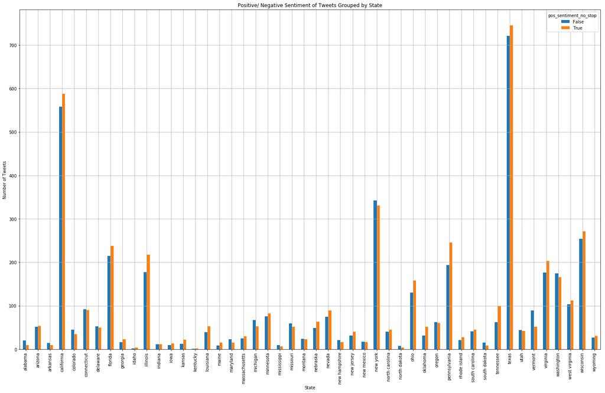

```python
grpd_state_df['pos_sentiment_no_stop'].value_counts().unstack().plot(kind = 'bar', figsize=(25,15))
plt.xlabel('State')
plt.ylabel('Number of Tweets')
plt.title('Positive/ Negative Sentiment of Tweets Grouped by State')
plt.grid(True)

plt.show()
```

True corresponds to positive sentiment.

In general we see more positive tweets. The porportion of positive to negative aren't too drastic from one another.

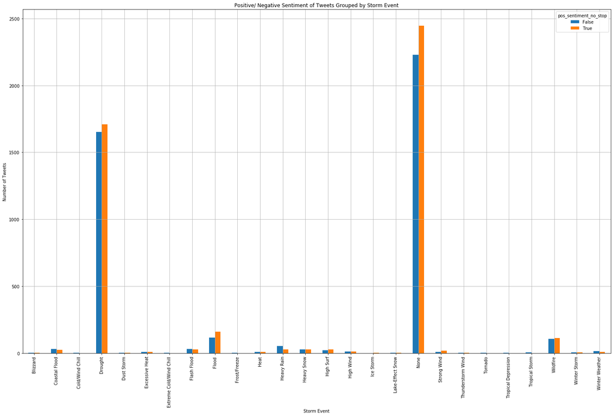

```python
grpd_weather_df['pos_sentiment_no_stop'].value_counts().unstack().plot(kind = 'bar', figsize=(25,15))
plt.xlabel('Storm Event')
plt.ylabel('Number of Tweets')
plt.title('Positive/ Negative Sentiment of Tweets Grouped by Storm Event')
plt.grid(True)

plt.show()
```

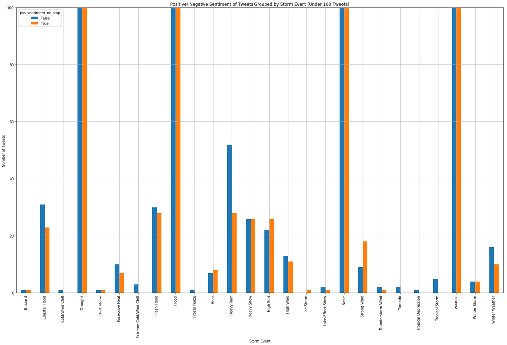

```python
grpd_weather_df['pos_sentiment_no_stop'].value_counts().unstack().plot(kind = 'bar', figsize=(25,15))
plt.xlabel('Storm Event')
plt.ylabel('Number of Tweets')
plt.title('Positive/ Negative Sentiment of Tweets Grouped by Storm Event (Under 100 Tweets)')
plt.grid(True)
plt.ylim(0,100)
plt.show()
```

For drought and none we see that the same trend that we saw in the states remains. We for the categories that have less than 100 tweets, we that there are cases of more negative tweets. For the ones that have more negative than positive tweets we see heavy rain as having significanly more. Interestingly, heavy rain is one of the few that seems to fall under this trend abd rain is one of the situations where we are most likely to feel sad because of the weather according to studies. Winter weather also has more negative tweets as well as high wind. High wind has more negative tweets but strong wind does not. Those tweets are small so we would have to look at those closely to really see what it's about.

### How many more positive than negative

Right now we only have positive or negative (no neutral). To test what we see in the graphs, we will further check to see if per weather category if there are more positive tweets than negative tweets.

Using the below formula:

# positive/#total - #negative/total

```python
#proportion of positive tweets (based off of token proportions) -  negative tweets / total

print(sum(tweet_weather_df['pos_count_prop'])/(
    sum(tweet_weather_df['pos_count_prop']) + sum(
        tweet_weather_df['neg_count_prop'])))

print(sum(tweet_weather_df['neg_count_prop'])/(
    sum(tweet_weather_df['pos_count_prop']) + sum(tweet_weather_df['neg_count_prop'])))
```

```
0.48475776412895966
0.5152422358710403
```

```python
#grouping each the tweets by weather type we will be looking at more closely

drought_df = tweet_weather_df[tweet_weather_df['weather_type'] == 'Drought']

none_df = tweet_weather_df[tweet_weather_df['weather_type'] == 'None']
flood_df = tweet_weather_df[tweet_weather_df['weather_type'] == 'Flood']
wildfire_df = tweet_weather_df[tweet_weather_df['weather_type'] == 'Wildfire']
heavyrain_df = tweet_weather_df[tweet_weather_df['weather_type'] == 'Heavy Rain']
winter_df = tweet_weather_df[tweet_weather_df['weather_type'] == 'Winter Weather']
wind_df = tweet_weather_df[tweet_weather_df['weather_type'] == 'Strong Wind']
heat_df = tweet_weather_df[tweet_weather_df['weather_type'] == 'Excessive Heat']
```

```python
weather_type = ['all', 'drought', 'none', 'flood', 'wildfire', 'heavy rain',
                'winter weather', 'strongs winds', 'excessive heat']
proportion = []

#for all tweets
#proportion of positive tweets - negative tweets / total
proportion.append(sum(tweet_weather_df['pos_sentiment'])/len(
    tweet_weather_df) - sum(1-tweet_weather_df['pos_sentiment'])/len(tweet_weather_df))

#for drought
#proportion of positive tweets - negative tweets / total

proportion.append(sum(drought_df['pos_sentiment'])/len(
    drought_df) - sum(1-drought_df['pos_sentiment'])/len(drought_df))

#for none
#proportion of positive tweets - negative tweets / total

proportion.append(sum(none_df['pos_sentiment'])/len(
    none_df) - sum(1-none_df['pos_sentiment'])/len(none_df))

#for flood
#proportion of positive tweets - negative tweets / total

proportion.append(sum(flood_df['pos_sentiment'])/len(
    flood_df) - sum(1-flood_df['pos_sentiment'])/len(flood_df))

#for wildfire
#proportion of positive tweets - negative tweets / total

proportion.append(sum(wildfire_df['pos_sentiment'])/len(
    wildfire_df) - sum(1-wildfire_df['pos_sentiment'])/len(wildfire_df))

#for heavy rain
#proportion of positive tweets - negative tweets / total

proportion.append(sum(heavyrain_df['pos_sentiment'])/len(
    heavyrain_df) - sum(1-heavyrain_df['pos_sentiment'])/len(heavyrain_df))

#for winter
#proportion of positive tweets - negative tweets / total

proportion.append(sum(winter_df['pos_sentiment'])/len(
    heavyrain_df) - sum(1-winter_df['pos_sentiment'])/len(winter_df))

#for wind
#proportion of positive tweets - negative tweets / total

proportion.append(sum(wind_df['pos_sentiment'])/len(
    heavyrain_df) - sum(1-wind_df['pos_sentiment'])/len(wind_df))

#excess heat
proportion.append(sum(heat_df['pos_sentiment'])/len(
    heavyrain_df) - sum(1-heat_df['pos_sentiment'])/len(heat_df))
proportion
```

```
[0.031243026110243211,
 0.01665675193337296,
 0.046640992725716757,
 0.16666666666666669,
 0.023041474654377891,
 -0.30000000000000004,
 -0.49038461538461542,
 -0.10833333333333331,
 -0.50073529411764706]
```

```python
proportions = pd.Series(proportion, index=weather_type)
proportions
```

```
all               0.031243
drought           0.016657
none              0.046641
flood             0.166667
wildfire          0.023041
heavy rain       -0.300000
winter weather   -0.490385
strongs winds    -0.108333
excessive heat   -0.500735
dtype: float64
```

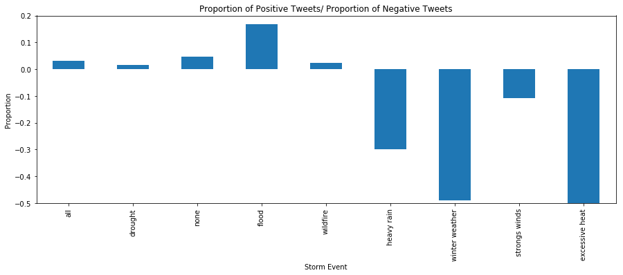

```python
proportions.plot(kind = 'bar', figsize=(15,5))
plt.xlabel('Storm Event')
plt.ylabel('Proportion')
plt.title('Proportion of Positive Tweets/ Proportion of Negative Tweets')
```

I chose a select few to take a look at. We can see in the "all", which looks at all of tweets that the difference between positive/negative isn't that large, but for more exreme weather such as heavy rain, winter weather, and excessive heat we see more negative tweets. It's interest to see that winter weather and extreme heat both have portionally more negative tweets despite being two temperatures. This supports the idea that extreme weather affects what people are tweeting about based only on these proportions.

## DTM

We will continue to do some tests on this dataset. Furthermore, it is useful to see if there is any similarity in the types of words that are used in each weather group and if there is a change in words dependings on storm event group. First we will check to see the frequency of terms.

```python
from sklearn.feature_extraction.text import CountVectorizer
countvec = CountVectorizer(stop_words="english")

countvec.fit_transform(tweet_weather_df['tweet'])

tweets_df = pd.DataFrame(countvec.fit_transform(
    tweet_weather_df['tweet']).toarray(), columns=countvec.get_feature_names())
tweets_df
```

|  | 00 | 000 | 0002 | 00am | 00in | 00pm | 01in | 02 | 021 | 0252 | ... | zq | zqowl | zrul5 | zuma | zvjyj | zxv8s | zz | zzif | zzzzzz | zzzzzzzzzzzzzzz |
| --- | --- | --- | --- | --- | --- | --- | --- | --- | --- | --- | --- | --- | --- | --- | --- | --- | --- | --- | --- | --- | --- |
| 0 | 0 | 0 | 0 | 0 | 0 | 0 | 0 | 0 | 0 | 0 | ... | 0 | 0 | 0 | 0 | 0 | 0 | 0 | 0 | 0 | 0 |
| 1 | 0 | 0 | 0 | 0 | 0 | 0 | 0 | 0 | 0 | 0 | ... | 0 | 0 | 0 | 0 | 0 | 0 | 0 | 0 | 0 | 0 |
| 2 | 0 | 0 | 0 | 0 | 0 | 0 | 0 | 0 | 0 | 0 | ... | 0 | 0 | 0 | 0 | 0 | 0 | 0 | 0 | 0 | 0 |
| 3 | 0 | 0 | 0 | 0 | 0 | 0 | 0 | 0 | 0 | 0 | ... | 0 | 0 | 0 | 0 | 0 | 0 | 0 | 0 | 0 | 0 |
| 4 | 0 | 0 | 0 | 0 | 0 | 0 | 0 | 0 | 0 | 0 | ... | 0 | 0 | 0 | 0 | 0 | 0 | 0 | 0 | 0 | 0 |
| 5 | 0 | 0 | 0 | 0 | 0 | 0 | 0 | 0 | 0 | 0 | ... | 0 | 0 | 0 | 0 | 0 | 0 | 0 | 0 | 0 | 0 |
| 6 | 0 | 0 | 0 | 0 | 0 | 0 | 0 | 0 | 0 | 0 | ... | 0 | 0 | 0 | 0 | 0 | 0 | 0 | 0 | 0 | 0 |
| 7 | 0 | 0 | 0 | 0 | 0 | 0 | 0 | 0 | 0 | 0 | ... | 0 | 0 | 0 | 0 | 0 | 0 | 0 | 0 | 0 | 0 |
| 8 | 0 | 0 | 0 | 0 | 0 | 0 | 0 | 0 | 0 | 0 | ... | 0 | 0 | 0 | 0 | 0 | 0 | 0 | 0 | 0 | 0 |
| 9 | 0 | 0 | 0 | 0 | 0 | 0 | 0 | 0 | 0 | 0 | ... | 0 | 0 | 0 | 0 | 0 | 0 | 0 | 0 | 0 | 0 |
| 10 | 0 | 0 | 0 | 0 | 0 | 0 | 0 | 0 | 0 | 0 | ... | 0 | 0 | 0 | 0 | 0 | 0 | 0 | 0 | 0 | 0 |
| 11 | 0 | 0 | 0 | 0 | 0 | 0 | 0 | 0 | 0 | 0 | ... | 0 | 0 | 0 | 0 | 0 | 0 | 0 | 0 | 0 | 0 |
| 12 | 0 | 0 | 0 | 0 | 0 | 0 | 0 | 0 | 0 | 0 | ... | 0 | 0 | 0 | 0 | 0 | 0 | 0 | 0 | 0 | 0 |
| 13 | 0 | 0 | 0 | 0 | 0 | 0 | 0 | 0 | 0 | 0 | ... | 0 | 0 | 0 | 0 | 0 | 0 | 0 | 0 | 0 | 0 |
| 14 | 0 | 0 | 0 | 0 | 0 | 0 | 0 | 0 | 0 | 0 | ... | 0 | 0 | 0 | 0 | 0 | 0 | 0 | 0 | 0 | 0 |
| 15 | 0 | 0 | 0 | 0 | 0 | 0 | 0 | 0 | 0 | 0 | ... | 0 | 0 | 0 | 0 | 0 | 0 | 0 | 0 | 0 | 0 |
| 16 | 0 | 0 | 0 | 0 | 0 | 0 | 0 | 0 | 0 | 0 | ... | 0 | 0 | 0 | 0 | 0 | 0 | 0 | 0 | 0 | 0 |
| 17 | 0 | 0 | 0 | 0 | 0 | 0 | 0 | 0 | 0 | 0 | ... | 0 | 0 | 0 | 0 | 0 | 0 | 0 | 0 | 0 | 0 |
| 18 | 0 | 0 | 0 | 0 | 0 | 0 | 0 | 0 | 0 | 0 | ... | 0 | 0 | 0 | 0 | 0 | 0 | 0 | 0 | 0 | 0 |
| 19 | 0 | 0 | 0 | 0 | 0 | 0 | 0 | 0 | 0 | 0 | ... | 0 | 0 | 0 | 0 | 0 | 0 | 0 | 0 | 0 | 0 |
| 20 | 0 | 0 | 0 | 0 | 0 | 0 | 0 | 0 | 0 | 0 | ... | 0 | 0 | 0 | 0 | 0 | 0 | 0 | 0 | 0 | 0 |
| 21 | 0 | 0 | 0 | 0 | 0 | 0 | 0 | 0 | 0 | 0 | ... | 0 | 0 | 0 | 0 | 0 | 0 | 0 | 0 | 0 | 0 |
| 22 | 0 | 0 | 0 | 0 | 0 | 0 | 0 | 0 | 0 | 0 | ... | 0 | 0 | 0 | 0 | 0 | 0 | 0 | 0 | 0 | 0 |
| 23 | 0 | 0 | 0 | 0 | 0 | 0 | 0 | 0 | 0 | 0 | ... | 0 | 0 | 0 | 0 | 0 | 0 | 0 | 0 | 0 | 0 |
| 24 | 0 | 0 | 0 | 0 | 0 | 0 | 0 | 0 | 0 | 0 | ... | 0 | 0 | 0 | 0 | 0 | 0 | 0 | 0 | 0 | 0 |
| 25 | 0 | 0 | 0 | 0 | 0 | 0 | 0 | 0 | 0 | 0 | ... | 0 | 0 | 0 | 0 | 0 | 0 | 0 | 0 | 0 | 0 |
| 26 | 0 | 0 | 0 | 0 | 0 | 0 | 0 | 0 | 0 | 0 | ... | 0 | 0 | 0 | 0 | 0 | 0 | 0 | 0 | 0 | 0 |
| 27 | 0 | 0 | 0 | 0 | 0 | 0 | 0 | 0 | 0 | 0 | ... | 0 | 0 | 0 | 0 | 0 | 0 | 0 | 0 | 0 | 0 |
| 28 | 0 | 0 | 0 | 0 | 0 | 0 | 0 | 0 | 0 | 0 | ... | 0 | 0 | 0 | 0 | 0 | 0 | 0 | 0 | 0 | 0 |
| 29 | 0 | 0 | 0 | 0 | 0 | 0 | 0 | 0 | 0 | 0 | ... | 0 | 0 | 0 | 0 | 0 | 0 | 0 | 0 | 0 | 0 |
| ... | ... | ... | ... | ... | ... | ... | ... | ... | ... | ... | ... | ... | ... | ... | ... | ... | ... | ... | ... | ... | ... |
| 8932 | 0 | 0 | 0 | 0 | 0 | 0 | 0 | 0 | 0 | 0 | ... | 0 | 0 | 0 | 0 | 0 | 0 | 0 | 0 | 0 | 0 |
| 8933 | 0 | 0 | 0 | 0 | 0 | 0 | 0 | 0 | 0 | 0 | ... | 0 | 0 | 0 | 0 | 0 | 0 | 0 | 0 | 0 | 0 |
| 8934 | 0 | 0 | 0 | 0 | 0 | 0 | 0 | 0 | 0 | 0 | ... | 0 | 0 | 0 | 0 | 0 | 0 | 0 | 0 | 0 | 0 |
| 8935 | 0 | 0 | 0 | 0 | 0 | 0 | 0 | 0 | 0 | 0 | ... | 0 | 0 | 0 | 0 | 0 | 0 | 0 | 0 | 0 | 0 |
| 8936 | 0 | 0 | 0 | 0 | 0 | 0 | 0 | 0 | 0 | 0 | ... | 0 | 0 | 0 | 0 | 0 | 0 | 0 | 0 | 0 | 0 |
| 8937 | 0 | 0 | 0 | 0 | 0 | 0 | 0 | 0 | 0 | 0 | ... | 0 | 0 | 0 | 0 | 0 | 0 | 0 | 0 | 0 | 0 |
| 8938 | 0 | 0 | 0 | 0 | 0 | 0 | 0 | 0 | 0 | 0 | ... | 0 | 0 | 0 | 0 | 0 | 0 | 0 | 0 | 0 | 0 |
| 8939 | 0 | 0 | 0 | 0 | 0 | 0 | 0 | 0 | 0 | 0 | ... | 0 | 0 | 0 | 0 | 0 | 0 | 0 | 0 | 0 | 0 |
| 8940 | 0 | 0 | 0 | 0 | 0 | 0 | 0 | 0 | 0 | 0 | ... | 0 | 0 | 0 | 0 | 0 | 0 | 0 | 0 | 0 | 0 |
| 8941 | 0 | 0 | 0 | 0 | 0 | 0 | 0 | 0 | 0 | 0 | ... | 0 | 0 | 0 | 0 | 0 | 0 | 0 | 0 | 0 | 0 |
| 8942 | 0 | 0 | 0 | 0 | 0 | 0 | 0 | 0 | 0 | 0 | ... | 0 | 0 | 0 | 0 | 0 | 0 | 0 | 0 | 0 | 0 |
| 8943 | 0 | 0 | 0 | 0 | 0 | 0 | 0 | 0 | 0 | 0 | ... | 0 | 0 | 0 | 0 | 0 | 0 | 0 | 0 | 0 | 0 |
| 8944 | 0 | 0 | 0 | 0 | 0 | 0 | 0 | 0 | 0 | 0 | ... | 0 | 0 | 0 | 0 | 0 | 0 | 0 | 0 | 0 | 0 |
| 8945 | 0 | 0 | 0 | 0 | 0 | 0 | 0 | 0 | 0 | 0 | ... | 0 | 0 | 0 | 0 | 0 | 0 | 0 | 0 | 0 | 0 |
| 8946 | 0 | 0 | 0 | 0 | 0 | 0 | 0 | 0 | 0 | 0 | ... | 0 | 0 | 0 | 0 | 0 | 0 | 0 | 0 | 0 | 0 |
| 8947 | 0 | 0 | 0 | 0 | 0 | 0 | 0 | 0 | 0 | 0 | ... | 0 | 0 | 0 | 0 | 0 | 0 | 0 | 0 | 0 | 0 |
| 8948 | 0 | 0 | 0 | 0 | 0 | 0 | 0 | 0 | 0 | 0 | ... | 0 | 0 | 0 | 0 | 0 | 0 | 0 | 0 | 0 | 0 |
| 8949 | 0 | 0 | 0 | 0 | 0 | 0 | 0 | 0 | 0 | 0 | ... | 0 | 0 | 0 | 0 | 0 | 0 | 0 | 0 | 0 | 0 |
| 8950 | 0 | 0 | 0 | 0 | 0 | 0 | 0 | 0 | 0 | 0 | ... | 0 | 0 | 0 | 0 | 0 | 0 | 0 | 0 | 0 | 0 |
| 8951 | 0 | 0 | 0 | 0 | 0 | 0 | 0 | 0 | 0 | 0 | ... | 0 | 0 | 0 | 0 | 0 | 0 | 0 | 0 | 0 | 0 |
| 8952 | 0 | 0 | 0 | 0 | 0 | 0 | 0 | 0 | 0 | 0 | ... | 0 | 0 | 0 | 0 | 0 | 0 | 0 | 0 | 0 | 0 |
| 8953 | 0 | 0 | 0 | 0 | 0 | 0 | 0 | 0 | 0 | 0 | ... | 0 | 0 | 0 | 0 | 0 | 0 | 0 | 0 | 0 | 0 |
| 8954 | 0 | 0 | 0 | 0 | 0 | 0 | 0 | 0 | 0 | 0 | ... | 0 | 0 | 0 | 0 | 0 | 0 | 0 | 0 | 0 | 0 |
| 8955 | 0 | 0 | 0 | 0 | 0 | 0 | 0 | 0 | 0 | 0 | ... | 0 | 0 | 0 | 0 | 0 | 0 | 0 | 0 | 0 | 0 |
| 8956 | 0 | 0 | 0 | 0 | 0 | 0 | 0 | 0 | 0 | 0 | ... | 0 | 0 | 0 | 0 | 0 | 0 | 0 | 0 | 0 | 0 |
| 8957 | 0 | 0 | 0 | 0 | 0 | 0 | 0 | 0 | 0 | 0 | ... | 0 | 0 | 0 | 0 | 0 | 0 | 0 | 0 | 0 | 0 |
| 8958 | 0 | 0 | 0 | 0 | 0 | 0 | 0 | 0 | 0 | 0 | ... | 0 | 0 | 0 | 0 | 0 | 0 | 0 | 0 | 0 | 0 |
| 8959 | 0 | 0 | 0 | 0 | 0 | 0 | 0 | 0 | 0 | 0 | ... | 0 | 0 | 0 | 0 | 0 | 0 | 0 | 0 | 0 | 0 |
| 8960 | 0 | 0 | 0 | 0 | 0 | 0 | 0 | 0 | 0 | 0 | ... | 0 | 0 | 0 | 0 | 0 | 0 | 0 | 0 | 0 | 0 |
| 8961 | 0 | 0 | 0 | 0 | 0 | 0 | 0 | 0 | 0 | 0 | ... | 0 | 0 | 0 | 0 | 0 | 0 | 0 | 0 | 0 | 0 |

8962 rows × 15818 columns

```python
#most frequent words
print(tweets_df.sum().sort_values(ascending=False))

most_freq = tweets_df.sum().sort_values(ascending=False)[:100]


#average times a word is used in a document
print(tweets_df.mean().sort_values(ascending=False))
```

```
weather            7488
http               1510
mayweather         1152
today               873
bit                 736
ly                  712
com                 706
great               693
day                 636
good                616
cold                615
rt                  604
just                542
like                528
love                429
rain                424
nice                422
perfect             408
beautiful           389
fall                385
time                354
tonight             345
fight               336
going               311
weekend             311
morning             286
marquez             276
hot                 247
www                 246
warm                240
                   ...
mer                   1
mequon                1
mentioned             1
mentalhealth          1
mens                  1
metcheck              1
meteorologists        1
michaelellison3       1
mh725                 1
```

[output cut: 69 more lines]

```
mhs                0.000112
mhandy1            0.000112
mga9v7             0.000112
meteors            0.000112
mexwarrior         0.000112
mexicanos          0.000112
metroplex          0.000112
metromag           0.000112
metro100           0.000112
metio              0.000112
methodist          0.000112
method             0.000112
meteveryday        0.000112
joshslagter        0.000112
dtype: float64
```

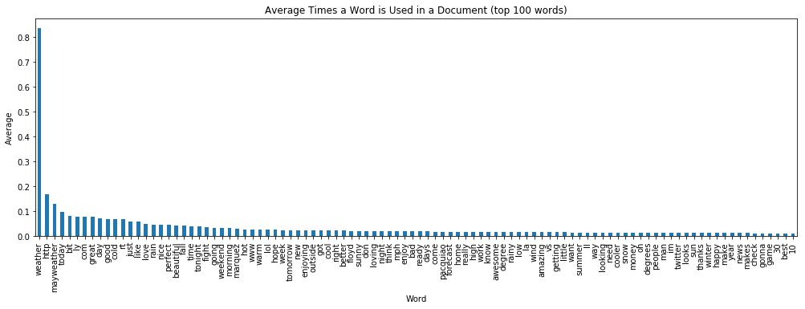

```python
t2 = pd.Series(tweets_df.mean().sort_values(ascending=False)[:100])
t2.plot(kind = 'bar', figsize=(17,5))

plt.xlabel('Word')
plt.ylabel('Average')
plt.title('Average Times a Word is Used in a Document (top 100 words)')
```

When we inpect the words used throughout the corpus we can see that obviously weather is the most frequent because we used the term "weather" to pull the tweets to look at. This method also pulled out "Mayweather" as well so we have tweets about the Mayweather and all of his fights mixed up in this (which is why fight and other fighters are prevalent in this text, but aside from that we words that generally describe the weather such as cold and rain. The top words are "great, good, like, love, perfect, beautiful, warm, hot, sunny, and loving" Generally we are seeing more positive words than I expected. We do get words like "cold, rain, bad, low, cooler, and snow, but from a glance, surprisingly, we see a lot more positivity.

#### Similarity between Tokens

```python
drought_list = drought_df["tweet"].tolist()
none_list = none_df["tweet"].tolist()
flood_list = flood_df["tweet"].tolist()
wildfire_list = wildfire_df["tweet"].tolist()
heavyrain_list = heavyrain_df["tweet"].tolist()
winter_list = winter_df["tweet"].tolist()
wind_list = wind_df["tweet"].tolist()
heat_list = heat_df["tweet"].tolist()
```

```python
drought_string = str(drought_list)
none_string = str(none_list)
flood_string = str(flood_list)
wildfire_string = str(wildfire_list)

heavyrain_string = str(heavyrain_list)
winter_string = str(winter_list)
wind_string = str(wind_list)
heat_string = str(heat_list)
```

```python
text_list = []
text_list.append(drought_string)
text_list.append(none_string)
text_list.append(flood_string)
text_list.append(wildfire_string)

text_list.append(heavyrain_string)
text_list.append(winter_string)
text_list.append(wind_string)
text_list.append(heat_string)
```

```python
#dtm matrix to compare the weather types
# 0: drought
# 1: none
# 2: flood
# 3: wildfire
# 4: heavy rain
# 5: winter storms
# 6: high winds
# 7: extreme heat


countvec = CountVectorizer(stop_words="english")

tweet_df = pd.DataFrame(countvec.fit_transform(text_list).toarray(), columns=countvec.get_feature_names())
tweet_df
```

|  | 00 | 000 | 0002 | 00am | 00in | 00pm | 01in | 02 | 021 | 0252 | ... | zq | zqowl | zrul5 | zuma | zvjyj | zxv8s | zz | zzif | zzzzzz | zzzzzzzzzzzzzzz |
| --- | --- | --- | --- | --- | --- | --- | --- | --- | --- | --- | --- | --- | --- | --- | --- | --- | --- | --- | --- | --- | --- |
| 0 | 7 | 3 | 0 | 0 | 21 | 2 | 1 | 0 | 1 | 0 | ... | 0 | 0 | 0 | 0 | 1 | 0 | 2 | 0 | 1 | 0 |
| 1 | 21 | 4 | 0 | 5 | 2 | 8 | 8 | 1 | 0 | 0 | ... | 0 | 0 | 1 | 0 | 0 | 1 | 0 | 0 | 0 | 1 |
| 2 | 0 | 0 | 1 | 0 | 0 | 0 | 0 | 0 | 0 | 0 | ... | 1 | 0 | 0 | 0 | 0 | 0 | 0 | 0 | 0 | 0 |
| 3 | 0 | 4 | 0 | 0 | 0 | 0 | 0 | 0 | 0 | 0 | ... | 0 | 0 | 0 | 1 | 0 | 0 | 0 | 1 | 0 | 0 |
| 4 | 0 | 0 | 0 | 0 | 0 | 0 | 0 | 0 | 0 | 1 | ... | 0 | 0 | 0 | 0 | 0 | 0 | 0 | 0 | 0 | 0 |
| 5 | 0 | 0 | 0 | 0 | 0 | 0 | 0 | 0 | 0 | 0 | ... | 0 | 0 | 0 | 0 | 0 | 0 | 0 | 0 | 0 | 0 |
| 6 | 0 | 0 | 0 | 0 | 0 | 0 | 0 | 0 | 0 | 0 | ... | 0 | 0 | 0 | 0 | 0 | 0 | 0 | 0 | 0 | 0 |
| 7 | 0 | 0 | 0 | 0 | 0 | 0 | 0 | 0 | 0 | 0 | ... | 0 | 1 | 0 | 0 | 0 | 0 | 0 | 0 | 0 | 0 |

8 rows × 15461 columns

```python
columns = list(tweet_df)
chi_list = []

for c in columns:
    chi_list.append([c,((tweet_df.loc[0,c] - tweet_df[c].sum(
        axis=0)/2)**2 / tweet_df[c].sum(axis=0)/2) + ((
        tweet_df.loc[1,c] - tweet_df[c].sum(axis=0)/2)**2 / tweet_df[c].sum(axis=0)/2)])
```

```python
chi_list[:10]
```

```
[['00', 1.75],
 ['000', 0.38636363636363641],
 ['0002', 0.25],
 ['00am', 1.25],
 ['00in', 3.9239130434782608],
 ['00pm', 0.90000000000000002],
 ['01in', 1.3611111111111112],
 ['02', 0.25],
 ['021', 0.25],
 ['0252', 0.25]]
```

```python
chi_list.sort(key=lambda x: x[1], reverse=True)
chi_list[:100]
```

```
[['weather', 74.185404068169333],
 ['mph', 27.84090909090909],
 ['data', 20.261764705882353],
 ['pct', 15.313218390804598],
 ['example', 14.765873015873016],
 ['twitter', 12.027777777777779],
 ['great', 11.911481481481482],
 ['pm', 11.841954022988507],
 ['http', 11.373728813559321],
 ['today', 10.523696682464456],
 ['wind', 10.181654676258994],
 ['bit', 9.0211511789181689],
 ['ly', 8.6732424677187954],
 ['fall', 8.2960526315789469],
 ['san', 7.5983146067415728],
 ['north', 7.5089285714285712],
 ['time', 7.2573746312684371],
 ['forecast', 6.4197530864197532],
 ['houston', 6.3289473684210531],
 ['sf', 6.25],
 ['chicago', 6.1479591836734695],
 ['gorgeous', 5.9127906976744189],
 ['vegas', 5.8895348837209305],
 ['nyc', 5.8729508196721305],
 ['weekend', 5.8500000000000005],
 ['atlanta', 5.7905405405405403],
 ['45', 5.7647058823529411],
 ['rt', 5.6056701030927831],
 ['51', 5.5384615384615383],
 ['sse', 5.5],
 ['seattle', 5.4618644067796609],
 ['58', 5.4596774193548381],
 ['steady', 5.3879310344827589],
 ['mesquite', 5.25],
 ['tx', 5.1280487804878048],
 ['barometer', 5.0],
 ['degs', 5.0],
 ['inhg', 5.0],
 ['rapidsweather', 5.0],
 ['rntoday', 5.0],
```

[output cut: 45 more lines]

```
 ['making', 3.3047945205479454],
 ['keyc', 3.25],
 ['sw', 3.25],
 ['dc', 3.2321428571428572],
 ['calm', 3.2000000000000002],
 ['saying', 3.2000000000000002],
 ['gust', 3.1413043478260869],
 ['went', 3.0750000000000002],
 ['dallas', 3.0595238095238093],
 ['forward', 3.0300000000000002],
 ['check', 3.0298165137614679],
 ['week', 3.011467889908257],
 ['info', 3.0092592592592595],
 ['34', 3.0],
 ['66f', 3.0]]
```

```python
#dtm matrix to compare the weather types
# 0: drought
# 1: none
# 2: flood
# 3: wildfire
# 4: heavy rain
# 5: winter storms
# 6: high winds
# 7: extreme heat

vectorizer = CountVectorizer(encoding='utf-8',stop_words='english')
dtm = vectorizer.fit_transform(text_list).toarray()
dtm
```

```
array([[ 7,  3,  0, ...,  0,  1,  0],
       [21,  4,  0, ...,  0,  0,  1],
       [ 0,  0,  1, ...,  0,  0,  0],
       ...,
       [ 0,  0,  0, ...,  0,  0,  0],
       [ 0,  0,  0, ...,  0,  0,  0],
       [ 0,  0,  0, ...,  0,  0,  0]], dtype=int64)
```

```python
from sklearn.metrics.pairwise import euclidean_distances
euc_dist = euclidean_distances(dtm)

print("\nDistance between none and drought")
print(euc_dist[1, 0])

print("\nDistance between none and flood")
print(euc_dist[1, 2])

print("\nDistance between none and wildfire")
print(euc_dist[1, 3])

print("\nDistance between drought and wildfire")
print(euc_dist[0, 3])

print("\nDistance between drought and flood")
print(euc_dist[0, 2])

print("\nDistance between none and heavy rain")
print(euc_dist[1, 4])

print("\nDistance between none and winter storms")
print(euc_dist[1, 5])

print("\nDistance between none and high winds")
print(euc_dist[1, 6])

print("\nDistance between none and extreme heat")
print(euc_dist[1, 7])

print("\nDistance between winter storms and extreme heat")
print(euc_dist[5, 7])

print("\nDistance between extreme heat and drought")
print(euc_dist[7, 0])
```

```
Distance between none and drought
1532.70675604

Distance between none and flood
4194.91632813

Distance between none and wildfire
4290.91528698

Distance between drought and wildfire
2842.30610596

Distance between drought and flood
2751.99509447

Distance between none and heavy rain
4401.52723495

Distance between none and winter storms
4449.65133466

Distance between none and high winds
4452.62169963

Distance between none and extreme heat
4461.77341424

Distance between winter storms and extreme heat
25.5538646784

Distance between extreme heat and drought
3014.70164361
```

Just testing a few of these for their euclidean distance, we can see that comparing the "none" tweets (tweets when there is no extreme weather) to these select extreme weathers, we see the greatest distance when looking at storm events that produce more simuli (rain,snow, wind, more heat) than drought. In addition, when we look at the distance between winter storms and extreme heat, it is very small even though the weather conditions are quite different. Looking at extreme heat and drought, which both suggest hot weather we still see a large difference.

From this, it further suggests that it is not really a matter of being cold, but that the weather is extreme or different from the norm.

## Word2Vec

To get a better sense of what the words are we will use Word2Vec to look at the similarity between words through out the document.

```python
import gensim #library needed for word2vec
```

```python
tweet_weather_df
```

[output not shown]